# 面向灵活性的软件设计：如何避免把自己编进死胡同 / Software Design for Flexibility_How to Avoid Programming Yourself into a Corner.Hanson2021

#### 西洋跳棋规则Rules of checkers

下面是一条普通移动规则。它沿可能的方向寻找任何未被占据的相邻位置，并扩展 pmove，将移动到该位置纳入其中。在这样一次移动之后，就不能合法地继续移动了，所以我们将该 pmove 标记为完成。Here is a rule for simple moves. This looks for any unoccupied adjacent position in a possible direction, and extends the pmove to include a move to that position. After such a move, it is not legal to continue moving, so we mark that pmove as finished.

```
(define-evolution-rule 'simple-move checkers

  (lambda (pmove)

    (if (is-pmove-empty? pmove)

        (get-simple-moves pmove)

        ’())))



(define (get-simple-moves pmove)

  (filter-map

   (lambda (direction)

     (let ((landing (compute-new-position direction 1 pmove))

           (board (current-board pmove)))

       (and (is-position-on-board? landing board)

            (is-position-unoccupied? landing board)

            (finish-move (new-piece-position landing pmove)))))

   (possible-directions (current-piece pmove))))
```

在 get-simple-moves 中，过程 compute-new-position 根据该次移动的 direction 和 distance，求出可能被移动的棋子的拟定落点。过程 offset* 将一个偏移量与一个数相乘，得到按该数缩放后的新偏移量。In get-simple-moves, the procedure compute-new-position gets the proposed landing site of the piece possibly being moved, given the direction and distance for the move. The procedure offset* multiplies an offset and a number to get a new offset scaled by the number.

```
(define (compute-new-position direction distance pmove)

  (coords+ (piece-coords (current-piece pmove))

           (offset* direction distance)))
```

跳吃规则与此类似，只是它必须在给定方向上寻找一个被占据的位置，其后紧接一个空位置。当无法再跳吃时，一个 pmove 就完成了。The rule for jumps is similar, except that it must look for an occupied position followed by an unoccupied position in a given direction. When no jumps are possible, a pmove is finished.

```
(define-evolution-rule ’jump checkers

  (lambda (pmove)

    (let ((jumps (get-jumps pmove)))

      (cond ((not (null? jumps))

             jumps)

            ((is-pmove-empty? pmove)

             ’()) ; abandon this pmove

            (else

             (list (finish-move pmove)))))))



(define (get-jumps pmove)

  (filter-map

   (lambda (direction)

     (let ((possible-jump

            (compute-new-position direction 1 pmove))

           (landing (compute-new-position direction 2 pmove))

           (board (current-board pmove)))

       (and (is-position-on-board? landing board)

            (is-position-unoccupied? landing board)

            (is-position-occupied-by-opponent? possible-jump

                                               board)

            (capture-piece-at possible-jump

                              (new-piece-position landing

                                                  pmove)))))

   (possible-directions (current-piece pmove))))
```

升王与其他规则无关：只需查看所有已经完成的走法，把其中位于对方底线上的非王棋子加冕为王即可。Making kings is independent of other rules: just look at all the completed moves and crown any non-king that is on the opponent's home row.

```
(define-aggregate-rule ’coronation checkers

  (lambda (pmoves)

    (map (lambda (pmove)

           (let ((piece (current-piece pmove)))

             (if (should-be-crowned? piece)

                 (update-piece crown-piece pmove)

                 pmove)))

         pmoves)))
```

最后，如果有一个或多个跳吃机会就必须跳吃，这条规则在最后处理：检测这种情况，并丢弃所有不跳吃的走法。And finally, the rule mandating that a jump be taken when one or more is available is done at the end by detecting that case and throwing away all the non-jump moves.

```
(define-aggregate-rule 'require-jumps checkers

  (lambda (pmoves)

    (let ((jumps (filter captures-pieces? pmoves)))

      (if (null? jumps)

          pmoves

          jumps))))
```

#### 评析Critique

基于规则的裁判实现解决了我们先前指出的问题。它把控制结构从程序中抽离出来，集中到执行器里。因此，各条规则都很明确：每条跳棋规则都由一条过程式规则表达，不再像先前的实现那样分散各处。The rule-based implementation of our referee solves the problems we identified earlier. It removes the control structure from our program and localizes it in the executive. As a consequence, the rules are specific: each checkers rule is expressed by a single procedural rule. The rules are not diffused as they were in the earlier implementation.

不过，这样做也有代价：我们必须为每条规则添加适用条件，防止它应用于不合适的 pmove。<sup>16</sup> 例如，simple-move 规则必须排除传给它的所有非空 pmove，因为非空 pmove 可能包含一次或多次跳吃，而跳吃之后不能接着进行普通移动。这是基于规则的系统普遍存在的一项缺陷：每条规则都必须能够接受任何规则的输出；通常的处理办法是把控制状态编码到规则所作用的数据中。However, this comes at a cost: we must add applicability conditions to each rule to prevent it being applied to pmoves for which it is inappropriate.<sup>16</sup> For example, the simple-move rule must exclude any nonempty pmoves that it is given, because a nonempty pmove might include one or more jumps, which cannot be continued with a simple move. This is a general mis-feature of rule-based systems: every rule must be able to accept the output of any rule; this is normally handled by encoding the control state in the data the rules are applied to.

## 练习 2.12：一点国际象棋Exercise 2.12: A bit of chess

利用我们为跳棋使用的同一个领域模型，也可以表达国际象棋的规则。除了国际象棋有多种不同棋子之外，还有几个重要区别。一个区别是，车、象和后的移动范围只受阻挡限制。另一个区别是，吃子靠占据对方棋子的位置，而不是跳过它。在本练习中，我们只考虑车和马；其余棋子留到练习 2.13 中讨论。Using the same domain model we used for checkers, it is possible to capture the rules of chess. There are several important differences, besides the fact that chess involves many types of pieces. One difference is that the range of motion of rooks, bishops, and queens is limited only by obstruction. Another difference is that capture is by displacement rather than jump. In this exercise we will consider only rooks and knights; the remaining pieces are addressed in exercise 2.13.

1. a. 构造一个类似的裁判，生成车的合法走法。不要尝试实现王车易位规则。**a.** Construct an analogous referee to generate the legal moves for a rook. Don't try to implement the castling rule.
2. b. 扩充你的裁判，使其能够模拟马的行为。**b.** Augment your referee to model the behavior of a knight.

## 练习 2.13：更多国际象棋Exercise 2.13: More chess

完整实现国际象棋的规则。Make a full implementation of the rules of chess.

## 练习 2.14：一个进阶项目Exercise 2.14: An advanced project

选择另一个并非棋类游戏的领域，使用规则执行器以及你自行设计的领域模型，实现某个过程的规则。这并不容易。Choose some other domain, not a board game, and build an implementation of the rules of some process using the rule executive and a domain model of your design. This is not easy.

## 2.5 小结2.5 Summary

本章展示并详细阐述的技术，有助于任何大型系统的设计和开发。使用接口定义明确、可以混搭的可互换部件来构建系统，几乎总是有利的。The techniques displayed and elaborated on in this chapter can be helpful in the design and development of every large-scale system. It is almost always to our advantage to build our systems using mix-and-match interchangeable parts with well-defined interfaces.

对于 Scheme 或 Java 这样具有高阶过程和词法作用域的语言，很容易为可互换部件库构造一套组合子，也就是诸如 compose 这样的标准组合手段。构造共享同一接口规范的参数化部件也很方便。例如，如果我们的接口规范要求过程接收一个参数并返回一个值，那么In languages with higher-order procedures and lexical scoping, like Scheme or Java, it is easy to make systems of combinators— standard means of combination, such as compose—for a library of interchangeable parts. And it is convenient to make parametric parts that share a common interface specification. For example, if our interface specification is procedures that take one argument and return one value, then

```
(define (make-incrementer dx)

  (lambda (x) (+ x dx)))
```

就定义了一组可互换的递增器。对于 C 这样没有词法作用域高阶过程的语言，构造组合子系统以及可组合部件库就困难得多。不过，只要周密规划并付出一些努力，还是可以做到的。defines a set of interchangeable incrementers. It is much harder to make systems of combinators and libraries of combinable parts with languages like C that do not have lexically scoped higher-order procedures. But with careful planning and some effort it can be done.

当我们遇到一个由难以干净组合的部件构成的系统时，例如正则表达式，往往可以通过元编程来缓解困难。在那个例子里，我们构造了一门新的基于组合子的语言，并将其编译成正则表达式语言，得到了一种用起来舒适但略显冗长的替代方案。对于需要匹配字符串的程序，我们的正则表达式组合子语言是一门很好的领域专用中间语言；但作为供用户键入的脚本语言，它就不那么理想了。为此，我们会希望设计一种清晰而更简洁的字符串匹配语法，并将其编译成基于组合子的中间语言。<sup>17</sup>When we are confronted with a system based on parts that do not compose cleanly, such as regular expressions, it is often possible to ameliorate the difficulties by metaprogramming. In that case we built a new combinator-based language that we compiled to the regular expression language, making a pleasant but longwinded alternative. Our regular-expressions combinator language is a fine domain-specific intermediate language for programs that need to match strings, but it is not so nice as a scripting language for a user to type. For that purpose we would want to design a clean and more concise syntax for matching strings that can be compiled to a combinator-based intermediate language.<sup>17</sup>

包装器是让旧代码适用于新环境的一种常见策略。我们展示了如何构造一套自动完成必要单位换算的包装器系统，使假定采用特定单位制的程序也能使用其他单位制。为此，我们构造了一门表达单位换算的小型领域专用语言，并将其编译成相应的包装器。Wrappers are a common strategy for making old code useful in a new context. We showed how programs that assumed a particular unit system could be used with other unit systems, by building a system of wrappers that automatically did the necessary unit conversions. To do this we made a small domain-specific language for expressing unit conversions that compiled into the appropriate wrapper.

但包装器的用途并不限于充当旧代码的适配器。我们可以用包装器包住一个过程，检查输入参数是否合理，并检查对于给定输入，输出是否像是一个合理的结果。如果检查失败，包装器就可以发出错误信号。这种“偏执式编程风格”是一种非常有力的工具，既能保护系统免遭误用，也有助于调试。But wrappers can be used for more than just adapters for old code. We can wrap a procedure with a wrapper that checks input arguments for reasonableness and checks that the output is a plausible result given the inputs. If such checks fail, the wrapper can raise an error signal. This “paranoid programming style” is a very powerful tool for protecting a system from misuse and for debugging.

正则表达式和单位换算的例子说明，解决某一类问题的最佳办法，往往是发明一门能轻松表达其解法的领域专用语言。为了探索这一策略，我们把生成棋类游戏合法走法的问题拆分成三个可以独立扩展的部分：领域模型、控制结构执行器，以及游戏的具体规则。领域模型提供一组基本构件，将它们组合起来就能构成规则，从而为我们提供一门表达规则的语言。控制结构执行器负责安排规则的应用顺序。这样的组合构成了一门领域专用语言的核心，用来表达类似跳棋的棋类游戏规则。As illustrated with regular expressions and with unit conversions, often the best way to attack a class of problems is to invent a domain-specific language in which the solutions are easy to express. To explore this strategy we divided the problem of generating the legal moves for a board game into three individually extensible pieces: a domain model, a control-structure executive, and the specific rules of the game. The domain model provides a set of primitives that are combined to make the rules, giving us a language for expressing the rules. The application of the rules is sequenced by the control-structure executive. This combination forms the essence of a domain-specific language for expressing the rules of checkers-like board games.

每一门好的语言都有基本构件、组合这些基本构件的手段，以及对组合进行抽象的手段。本章展示的例子嵌入在 Scheme 中，因此能够利用 Scheme 强大的组合与抽象手段。但这只是开始。在第 5 章中，我们将运用元语言抽象这一强大思想，超越这种嵌入策略。Every good language has primitives, means of combination of those primitives, and means of abstraction for the combinations. The examples shown in this chapter are embedded in Scheme, and thus are able to use Scheme's powerful means of combination and abstraction. But this is only the start. In chapter 5 we will transcend this embedding strategy, using the powerful idea of metalinguistic abstraction.

1 领域模型的通用性是“Postel 法则”的一个例子——见第 3 页。1 The generality of the domain model is an example of “Postel's law”—see page 3.

2 有一些值得注意的例外：Java 8 引入的函数式编程扩展直接表达了一些有用的组合。Lisp 和 Haskell 等函数式编程语言拥有提供有用组合机制的程序库。2 There are some notable exceptions: the functional programming extensions introduced by Java 8 directly capture useful combinations. Functional programming languages, such as Lisp and Haskell, have libraries of useful combination mechanisms.

3 这里的情况很简单，但在拥有许多内部过程的复杂程序中，描述性的名称可以让程序更容易阅读和理解。在 MIT/GNU Scheme 中，为这里返回的过程命名还有一点小好处：调试器可以显示这个名称，否则该过程就是匿名的。3 Here things are simple, but in complex programs with many internal procedures, descriptive names can make things easier to read and understand. In MIT/GNU Scheme there is a minor advantage to naming the procedure being returned here, because the debugger can show this name for a procedure that would otherwise be anonymous.

4 MIT/GNU Scheme 中散列表过程的文档见 [51]。4 Documentation of hash table procedures in MIT/GNU Scheme can be found in [51].

5 感谢 Guy L. Steele Jr. 建议我们展示这一分解。5 We thank Guy L. Steele Jr. for suggesting that we show this decomposition.

6 values、call-with-values 和 let-values 的文档见 [51] 和 [109]。6 Documentation of values, call-with-values, and let-values can be found in [51] and [109].

7 组合逻辑由 Moses Schönfinkel [108] 发明，并由 Haskell Curry [26] 于 20<sup>th</sup> 世纪初加以发展。他们的目标与计算无关，而是通过消除对量化变量的需要来简化数学基础。7 Combinatory logic was invented by Moses Schönfinkel [108] and developed by Haskell Curry [26] in the early 20<sup>th</sup> century. Their goal had nothing to do with computation, but rather to simplify the foundations of mathematics by eliminating the need for quantified variables.

8 get-arity 中使用的 MIT/GNU Scheme 过程 procedure-arity，会为返回的过程给出数值形式的元数，因此我们无须给它贴便签。8 The MIT/GNU Scheme procedure-arity, used in get-arity, will produce a numerical arity for the procedure returned, so we do not need to put a sticky note on it.

9 调用 r:repeat 时，将 max 设为 #f，就表示没有上限。9 We indicate that there is no maximum by calling r:repeat with #f for max.

10 ERE 特殊字符，[96] #tag 09 04 0310 ERE Special Characters, [96] #tag 09 04 03

11 ERE 择一，[96] #tag 09 04 0711 ERE Alternation, [96] #tag 09 04 07

12 匹配多个字符的 ERE，[96] #tag 09 04 0612 EREs Matching Multiple Characters, [96] #tag 09 04 06

13 匹配多个字符的 BRE，[96] #tag 09 03 0613 BREs Matching Multiple Characters, [96] #tag 09 03 06

14 匹配多个字符的 BRE，[96] #tag 09 03 0614 BREs Matching Multiple Characters, [96] #tag 09 03 06

15 注意，将 meter-to-inch 的两个实例组合起来，是把平方米换算成平方英寸的一种合理方法。但对某些单位换算来说，情况并非如此。例如，对开尔文到摄氏度的换算取平方并没有意义，即使数值计算会产生一致的结果。这是因为摄氏温度相对于具有物理意义的开尔文温度存在一个偏移量。实际上，摄氏温度的平方没有物理意义。15 Note that the composition of two instances of meter-to-inch is a sensible way to convert square meters to square inches. There are unit conversions for which this is not true. For example, taking the square of a kelvin-to-Celsius conversion doesn't make sense, even though the numerical computation produces consistent results. This is a consequence of the fact that Celsius temperature has an offset from the physically meaningful kelvin temperature. Indeed, the square of a Celsius temperature has no physical meaning.

16 不过，由于规则执行器会显式处理已经完成的 pmove，我们无须在规则中检查这一情况。16 However, because the rule executive explicitly handles finished pmoves, we don't need to test for those in the rules.

17 SRFI 115 [110] 是一个有趣的例子。17 SRFI 115 [110] is an interesting example.

# 3 算术主题变奏3 Variations on an Arithmetic Theme

本章介绍一种极其强大、但也可能很危险的灵活性技术：通过谓词分派的泛型过程。我们从相对平静的算术水域出发，逐步调整运算符符号的含义。In this chapter we introduce the extremely powerful but potentially dangerous flexibility technique of predicate-dispatched *generic procedures*. We start out in the relatively calm waters of arithmetic, modulating the meanings of the operator symbols.

我们先把算术推广到能够处理符号代数表达式，再推广到函数。我们使用一个组合子系统，其中被组合的元素是算术运算包。We first generalize arithmetic to deal with symbolic algebraic expressions, and then to functions. We use a combinator system where the elements being combined are packages of arithmetic operations.

但很快我们就想要更多灵活性。因此，我们发明了可以动态扩展的泛型过程，其中处理过程是否适用，由作用于所提供实参的谓词决定。这非常强大，也很有趣。利用泛型过程，把算术扩展为能够操作“微分对象”，我们只需很少的工作就实现了自动微分！But soon we want even more flexibility. So we invent dynamically extensible generic procedures, where the applicability of a handler is determined by predicates on the supplied arguments. This is very powerful and great fun. Using generic procedures to extend the arithmetic to operate on “differential objects,” we get automatic differentiation with very little work!

谓词分派的开销相当大，因此我们将研究降低这种开销的方法。在此过程中，我们发明了一种带标签的数据，其中标签不过是缓存某个谓词值的一种方式。在本章结尾，我们通过设计一个简单但易于扩充的冒险游戏，展示泛型过程的威力。Predicate dispatch is pretty expensive, so we investigate ways to ameliorate that expense. In the process we invent a kind of tagged data, where a tag is just a way of memoizing the value of a predicate. To finish the chapter we demonstrate the power of generic procedures with the design of a simple, but easy to elaborate, adventure game.

## 3.1 组合算术系统3.1 Combining arithmetics

假设我们有一个程序，能够计算出一些有用的数值结果。它依赖于程序文本所引用的算术运算符的含义。我们可以扩展这些运算符，使其不仅能操作程序原本预期的数，还能操作其他事物。经过这些扩展，程序可能完成一些在编写时未曾预料到的有用工作。一种常见模式是，程序接收数值权重和其他参数，将加权后的参数相加，构成线性组合。如果把加法和乘法运算符扩展为既能操作原来的数，也能操作数的元组，那么该程序就能构造向量的线性组合。这种扩展之所以能够奏效，是因为这组算术运算符是一个规范明确、内部协调一致的整体。用更强大的算术系统扩展数值程序是可行的，除非新的量不遵守程序作者所假定的约束。例如，矩阵乘法不满足交换律，因此，如果某个数值程序依赖数的乘法满足交换律这一事实，那么这样的扩展就行不通。我们暂且忽略这个问题。Suppose we have a program that computes some useful numerical results. It depends on the meanings of the arithmetic operators that are referenced by the program text. These operators can be extended to work on things other than the numbers that were expected by the program. With these extensions the program may do useful things that were not anticipated when the program was written. A common pattern is a program that takes numerical weights and other arguments and makes a linear combination by adding up the weighted arguments. If the addition and multiplication operators are extended to operate on tuples of numbers as well as on the original numbers, the program can make linear combinations of vectors. This kind of extension can work because the set of arithmetic operators is a well-specified and coherent entity. Extensions of numerical programs with more powerful arithmetic can work, unless the new quantities do not obey the constraints that were assumed by the author of the program. For example, multiplication of matrices does not commute, so extension of a numerical program that depends on the fact that multiplication of numbers is commutative will not work. We will ignore this problem for now.

### 3.1.1 一个简单的常微分方程积分器3.1.1 A simple ODE integrator

微分方程描述系统状态如何随着自变量的变化而变化；这称为系统状态的演化。<sup>1</sup> 我们可以在自变量的不同位置取样，并近似计算每个取样点处的状态变化，从而近似描述系统状态的演化。这种近似过程称为数值积分。A differential equation is a description of how the state of a system changes as an independent variable is varied; this is called the *evolution* of the system's state.<sup>1</sup> We can approximate the evolution of a system's state by sampling the independent variable at various points and approximating the state change at each sample point. This process of approximation is called *numerical* *integration*.

其核心思想是：未知函数二阶导数的离散近似，是前面若干步二阶导数的线性组合。具体系数通过数值分析来选取，这里不作讨论。The essential idea is that a discrete approximation to the second derivative of the unknown function is a linear combination of second derivatives of some previous steps. The particular coefficients are chosen by numerical analysis and are not of interest here.

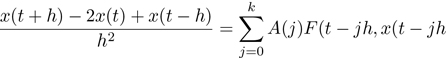

(3.2)

其中，*h* 是步长，*A* 是存放那些神奇系数的数组。where *h* is the step size and *A* is the array of magic coefficients.

例如，二阶 Stormer 积分器为For example, Stormer's integrator of order 2 is

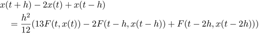

(3.3)

为了用它计算 *x* 未来的值，我们编写一个程序。stormer-2 返回的过程是针对给定函数和步长的积分器；给定 *x* 的历史值，它会估计下一时刻 *x* 的值，即 *x*(*t* + *h*)。过程 t 和 x 从历史记录中提取先前的时刻及 *x* 的值：(x 0 history) 返回 *x*(*t*)，(x 1 history) 返回 *x*(*t* − *h*)，而 (x 2 history) 返回 *x*(*t* − 2*h*)。我们也用类似方式从历史记录中获取某一步的时刻：(t 1 history) 返回 t − h。To use this to compute the future of *x* we write a program. The procedure returned by stormer-2 is an integrator for a given function and step size, that given a history of values of *x*, produces an estimate of the value of *x* at the next time, *x*(*t* + *h*). The procedures t and x extract previous times and values of *x* from the history: (x 0 history) returns *x*(*t*), (x 1 history) returns *x*(*t* *−* *h*), and (x 2 history) returns *x*(*t* *−* 2*h*). We access the time of a step from a history similarly: (t 1 history) returns *t − h*.

```
(define (stormer-2 F h)

  (lambda (history)

    (+ (* 2 (x 0 history))

       (* -1 (x 1 history))

       (* (/ (expt h 2) 12)

          (+ (* 13 (F (t 0 history) (x 0 history)))

             (* -2 (F (t 1 history) (x 1 history)))

             (F (t 2 history) (x 2 history)))))))
```

stepper 返回的过程接收一份历史记录，并使用给定的积分器，将其向前推进 *h*，返回新的历史记录。The procedure returned by stepper takes a history and returns a new history advanced by *h* for the given integrator.

```
(define (stepper h integrator)

  (lambda (history)

    (extend-history (+ (t 0 history) h)

                    (integrator history)

                    history)))
```

过程 evolver 使用过程 stepper，生成一个能够把历史记录向前推进一步的过程 step。过程 evolve 使用 step 过程，将历史记录向前推进指定步数，每步的大小为 *h*。这里，我们显式使用专用的整数算术运算（名为 n:> 和 n:- 的过程）来计数步数。这样，其他所有计算就可以使用不同类型的算术，而不会影响简单的计数。<sup>2</sup>The procedure stepper is used in the procedure evolver to produce a procedure step that will advance a history by one step. The step procedure is used in the procedure evolve that advances the history by a given number of steps of size *h*. We explicitly use specialized integer arithmetic here (the procedures named n:> and n:-) for counting steps. This will allow us to use different types of arithmetic for everything else without affecting simple counting.<sup>2</sup>

```
(define (evolver F h make-integrator)

  (let ((integrator (make-integrator F h)))

    (let ((step (stepper h integrator)))

      (define (evolve history n-steps)

        (if (n:> n-steps 0)

            (evolve (step history) (n:- n-steps 1))

            history))

      evolve)))
```

像方程 3.1 这样的二阶微分方程，通常需要两个初始条件才能确定唯一的轨迹：有了 *x*(*t*<sub>0</sub>) 和 *x*(*t*<sub>0</sub>)，就足以求出所有 *t* 对应的 *x*(*t*)。但我们使用的 Stormer 多步积分器需要三个历史值——*x*(*t*<sub>0</sub>)、*x*(*t*<sub>0</sub> − *h*) 和 *x*(*t*<sub>0</sub> − 2*h*)——才能计算下一个值 *x*(*t*<sub>0</sub> + *h*)。因此，要用这个积分器推进轨迹，我们必须从一份包含 *x* 的三个过去值的初始历史记录开始。A second-order differential equation like equation 3.1 generally needs two initial conditions to determine a unique trajectory: *x*(*t*<sub>0</sub>) and *x*(*t*<sub>0</sub>) are sufficient to get *x*(*t*) for all *t*. But the Stormer multistep integrator we are using requires three history values, *x*(*t*<sub>0</sub>), *x*(*t*<sub>0</sub> *−* *h*), and *x*(*t*<sub>0</sub> *−* 2*h*), to compute the next value *x*(*t*<sub>0</sub> + *h*). So to evolve the trajectory with this integrator we must start with an initial history that has three past values of *x*.

按照方程 3.1 的形式，其右端为：In the form shown in equation 3.1 the right-hand side is:

```
(define (F t x) (- x))
```

由于这个方程的所有解都是正弦型函数的线性组合，我们可以用正弦函数的三个值初始化历史记录，从而得到简单的正弦函数：Because all the solutions of this equation are linear combinations of sinusoids, we can get the simple sine function by initializing the history with three values of the sine function:

```
(define numeric-s0

  (make-initial-history 0 .01 (sin 0) (sin -.01) (sin -.02)))
```

其中，过程 make-initial-history 接收以下参数：where the procedure make-initial-history takes the following arguments:

```
(make-initial-history t h x(t) x(t − h) x(t − 2h))
```

使用 Scheme 的内置算术，以步长 *h* = .01 推进 100 步后，我们得到 sin(1) 的一个很好的近似值：Using Scheme's built-in arithmetic, after 100 steps of size *h* = *.*01 we get a good approximation to sin(1):

```
(x 0 ((evolver F .01 stormer-2) numeric-s0 100))

.8414709493275624

(sin 1)

.8414709848078965
```

### 3.1.2 调整算术运算符3.1.2 Modulating arithmetic operators

让我们考虑调整加法、乘法等运算的含义，使其适用于示例程序的编写者未曾设想过的新数据类型。假设我们改变算术运算符，让它们操作并产生符号表达式，而不是数值。这对调试纯数值计算很有用，因为只要提供符号参数，我们就可以检查所得的符号表达式，确认程序确实在计算我们想要的东西。这也可以成为部分求值器的基础，用于优化数值程序。Let's consider the possibility of modulating what is meant by addition, multiplication, etc., for new data types unimagined by our example's programmer. Suppose we change our arithmetic operators to operate on and produce symbolic expressions rather than numerical values. This can be useful in debugging purely numerical calculations, because if we supply symbolic arguments we can examine the resulting symbolic expressions to make sure that the program is calculating what we intend it to. This can also be the basis of a partial evaluator for optimization of numerical programs.

下面是实现这一目标的一种方法。我们引入算术包这一概念。算术包，或简称算术系统，是从运算符名称到其运算（实现）的映射。我们可以把一个算术系统安装到用户的读取—求值—打印环境中，用该算术系统的实现替换其中所命名运算符的默认绑定。Here is one way to accomplish this goal. We introduce the idea of an *arithmetic package*. An arithmetic package, or just *arithmetic*, is a map from operator names to their operations (implementations). We can install an arithmetic in the user's read-eval-print environment to replace the default bindings of the operators named in the arithmetic with the arithmetic's implementations.

过程 make-arithmetic-1 生成一个新的算术包。它接收新算术系统的名称，以及一个运算生成过程；给定运算符名称，后者会为该运算符构造一个运算，这里就是一个处理过程。过程 make-arithmetic-1 用每个算术运算符调用这个运算生成过程，并把结果汇集成一个新的算术包。对于符号算术，每个运算都实现为一个过程：通过 cons 将运算符名称接到其参数列表的前面，从而构造符号表达式。The procedure make-arithmetic-1 generates a new arithmetic package. It takes a name for the new arithmetic, and an operation-generator procedure that given an operator name constructs an *operation*, here a handler procedure, for that operator. The procedure make-arithmetic-1 calls the operation-generator procedure with each arithmetic operator, accumulating the results into a new arithmetic package. For symbolic arithmetic, the operation is implemented as a procedure that creates a symbolic expression by consing the operator name onto the list of its arguments.

```
(define symbolic-arithmetic-1

  (make-arithmetic-1 'symbolic

    (lambda (operator)

      (lambda args (cons operator args)))))
```

要使用这个新定义的算术系统，我们先安装它。这会重新定义算术运算符，使其采用这个算术系统：<sup>3</sup>To use this newly defined arithmetic, we install it. This redefines the arithmetic operators to use this arithmetic:<sup>3</sup>

```
(install-arithmetic! symbolic-arithmetic-1)
```

对于该算术系统中定义的各个算术运算符，install-arithmetic! 会把用户的同名全局变量的值，改为该算术系统中相应的值。例如，完成此次安装之后：install-arithmetic! changes the values of the user's global variables that are the names of the arithmetic operators defined in the arithmetic to their values in that arithmetic. For example, after this install:

```
(+ ’a ’b)

(+ a b)



(+ 1 2)

(+ 1 2)
```

现在，我们可以观察 Stormer 演化向前推进一步的结果：<sup>4</sup> <sup>5</sup>Now we can observe the result of taking one step of the Stormer evolution:<sup>4</sup> <sup>5</sup>

```
(pp (x 0

       ((evolver F ’h stormer-2)

        (make-initial-history 't ’h ’xt ’xt-h ’xt-2h)

        1)))

(+ (+ (* 2 xt) (* -1 xt-h))

   (* (/ (expt h 2) 12)

      (+ (+ (* 13 (negate xt)) (* -2 (negate xt-h)))

         (negate xt-2h))))
```

只需把 symbolic-arithmetic-1 中的 cons 换成代数化简器，就能轻松生成化简后的表达式，从而得到一个符号运算系统。（我们将在第 4.2 节探索代数化简。）We could easily produce simplified expressions by replacing the cons in symbolic-arithmetic-1 with an algebraic simplifier, and then we would have a symbolic manipulator. (We will explore algebraic simplification in section 4.2.)

这一转变简单得令人难以置信，而我们的原始设计并未为符号计算做任何准备。我们同样可以轻松加入对向量算术、矩阵算术等的支持。This transformation was ridiculously easy, and yet our original design didn't make any provisions for symbolic computation. We could just as easily add support for vector arithmetic, matrix arithmetic, etc.

#### 重新定义运算符的问题Problems with redefining operators

事后重新定义运算符的能力，既带来了极大的灵活性，也让我们能够制造出全新类别的错误！（我们预见到 evolver 过程中可能出现这样的问题，因此使用专用算术运算符 n:> 和 n:- 来计数步数，从而避开了它。）The ability to redefine operators *after* *the* *fact* gives both extreme flexibility and ways to make whole new classes of bugs! (We anticipated such a problem in the evolver procedure and avoided it by using the special arithmetic operators n:> and n:- for counting steps.)

还有一些更微妙的问题。依赖整数运算精确性的程序，在使用不精确的浮点数时，可能无法正确工作。这正是生物或技术系统演化所伴随的风险——有些突变会致命！另一方面，有些突变又会极有价值。但我们必须将这种风险与结构狭隘而脆弱所带来的代价进行权衡。There are more subtle problems. A program that depends on the exactness of operations on integers may not work correctly for inexact floating-point numbers. This is exactly the risk that comes with the evolution of biological or technological systems— some mutations will be fatal! On the other hand, some mutations will be extremely valuable. But that risk must be balanced against the cost of narrow and brittle construction.

事实上，当基本过程可以被重新定义时，除了证明程序在限定于其原本针对的类型时能够工作之外，我们大概无法对它证明太多其他性质。这是一条简单却危险的泛化之路。Indeed, it is probably impossible to prove very much about a program when the primitive procedures can be redefined, except that it will work when restricted to the types it was defined for. This is an easy but dangerous path for generalization.

### 3.1.3 组合算术系统3.1.3 Combining arithmetics

符号算术无法进行数值计算，因此，替换运算符定义破坏了我们的积分示例。我们真正希望的是让运算符的行为取决于其参数：例如，(+ 1 2) 应执行数值加法，而 (+ ’a ’b) 应构造一个列表。因此，算术包必须能够判定，哪一个处理过程适用于传入的参数。The symbolic arithmetic cannot do numerical calculation, so we have broken our integration example by replacing the operator definitions. We really want an operator's action to depend on its arguments: for example, numerical addition for (+ 1 2) but building a list for (+ ’a ’b). Thus the arithmetic packages must be able to determine which handler is appropriate for the arguments tendered.

#### 改进的算术抽象An improved arithmetic abstraction

为每个运算附加一个适用性规范，通常简称适用性，我们就可以组合不同种类的算术。例如，我们可以把符号算术与数值算术组合起来，使组合后的运算能够判定哪种实现适用于其参数。By annotating each operation with an *applicability specification*, often shortened to just an *applicability*, we can combine different kinds of arithmetic. For example, we can combine symbolic and numeric arithmetic so that a combined operation can determine which implementation is appropriate for its arguments.

适用性规范只是一个情况列表，其中每种情况又是一个谓词列表，例如 number? 或 symbolic?。如果一系列参数满足其中一种情况，也就是说，该情况中的每个谓词对相应参数都为真，那么就认为一个过程适用于这些参数。例如，对于二元算术运算符，我们希望数值运算仅适用于 (number? number?) 这种情况，而符号运算则适用于这些情况：((number? symbolic?) (symbolic? number?) (symbolic? symbolic?))。An applicability specification is just a list of *cases*, each of which is a list of predicates, such as number? or symbolic?. A procedure is deemed applicable to a sequence of arguments if the arguments satisfy one of the cases—that is, if each predicate in the case is true of the corresponding argument. For example, for binary arithmetic operators, we would like the numeric operations to be applicable in just the case (number? number?) and the symbolic operations to be applicable in these cases: ((number? symbolic?) (symbolic? number?) (symbolic? symbolic?)).

我们用 make-operation 构造一个运算，其中包含处理过程的适用性，如下所示：We use make-operation to make an operation that includes an applicability for the handler procedure, like this:

```
(define (make-operation operator applicability procedure)

  (list ’operation operator applicability procedure))
```

这样就可以获取一个运算的适用性：It is then possible to get the applicability for an operation:

```
(define (operation-applicability operation)

  (caddr operation))
```

我们引入一种抽象，用来编写运算的适用性信息。过程 all-args 接收两个参数：第一个是运算接收的参数个数（即其元数，见第 26 页），第二个是对每个参数都必须为真的谓词。它返回一个适用性规范，可用来判定该运算是否适用于所提供的参数。在数值算术中，每个运算的所有参数都必须是数。We introduce an abstraction for writing applicability information for an operation. The procedure all-args takes two arguments, the first being the number of arguments that the operation accepts (its *arity*, as on page 26), and the second being a predicate that must be true of each argument. It returns an applicability specification that can be used to determine if the operation is applicable to the arguments supplied to it. In a numeric arithmetic, each operation takes numbers for each of its arguments.

利用 all-args，我们可以为最简单的运算实现一个运算构造器：Using all-args we can implement an operation constructor for the simplest operations:

```
(define (simple-operation operator predicate procedure)

  (make-operation operator

                  (all-args (operator-arity operator)

                            predicate)

                  procedure))
```

拥有一个定义域谓词也会很有用：对于某个算术系统的运算所接收的参数对象（如函数或矩阵），该谓词为真，例如数值算术的 number?。为了支持这一更复杂的构想，我们将为算术包创建一个构造器 make-arithmetic。过程 make-arithmetic 类似于 make-arithmetic-1（见第 71 页），但多了几个参数。We will also find it useful to have a *domain predicate* that is true for the objects (such as functions or matrices) that a given arithmetic's operations take as arguments—for example, number? for numeric arithmetic. To support this more elaborate idea we will create a constructor make-arithmetic for arithmetic packages. The procedure make-arithmetic is like make-arithmetic-1 (see page 71) but has additional arguments.

```
(make-arithmetic  name

                  domain-predicate

                  base-arithmetic-packages

                  map-of-constant-name-to-constant

                  map-of-operator-name-to-operation)
```

make-arithmetic 生成的算术包有一个便于调试的名称，也有上述定义域谓词。它还有一个算术包列表，称为基础算术系统，新算术系统将基于它们构造。此外，该算术系统还包含一组具名常量，以及一组运算符及其相应运算。最后两个参数用于生成这两组内容。An arithmetic package produced by make-arithmetic has a name that is useful for debugging. It has the domain predicate noted above. It has a list of arithmetic packages, called the *bases*, that the new arithmetic will be built from. In addition, the arithmetic will contain a set of named constants, and a set of operators along with their corresponding operations. The final two arguments are used to generate these sets.

向量是使用基础算术系统的一个例子。向量表示为有序的坐标序列，因此，向量上的算术是根据其坐标上的算术定义的。所以，向量算术的基础算术系统，就是适用于向量坐标的算术系统。坐标为数值的向量算术，会使用数值算术作为基础；坐标为符号的向量算术，则会使用符号算术作为基础。为简便起见，我们常用“之上”来指定基础，例如“数之上的向量”或“符号之上的向量”。An example of the use of a base arithmetic is vectors. A vector is represented as an ordered sequence of coordinates: consequently an arithmetic on vectors is defined in terms of arithmetic on its coordinates. So the base arithmetic for a vector arithmetic is the appropriate arithmetic for the vector's coordinates. A vector arithmetic with numeric coordinates will use a numeric arithmetic as its base, while a vector arithmetic with symbolic coordinates will use a symbolic arithmetic as its base. For brevity, we often use the term “over” to specify the base, as in “vectors over numbers” or “vectors over symbols.”

基础算术系统还决定了派生算术系统将定义哪些常量和运算符。所定义的常量，是各基础算术系统所定义常量的并集；所定义的运算符，则是它们的运算符的并集。如果没有基础算术系统，就定义标准的常量名称集和运算符名称集。The base arithmetics also determine the constants and operators that the derived arithmetic will define. The defined constants will be the union of the constants defined by the bases, and the defined operators will be the union of their operators. If there are no bases, then standard sets of constant and operator names will be defined.

利用这些新能力，我们可以定义一个带有适用性信息的数值算术系统。由于数值算术建立在 Scheme 底层之上，对于 Scheme 数值参数，适当的运算符处理过程就是该运算符符号在 Scheme 实现中的值。此外，某些符号，例如加法和乘法的单位元常量，会进行特殊映射。Using these new capabilities, we can define a numeric arithmetic with applicability information. Since numeric arithmetic is built on the Scheme substrate, the appropriate handler for the operator for Scheme number arguments is just the value of the operator symbol for the Scheme implementation. Also, certain symbols, such as the identity constants for addition and multiplication, are specially mapped.

```
(define numeric-arithmetic

  (make-arithmetic ’numeric number? ’()

    (lambda (name)                ;constant generator

      (case name

        ((additive-identity) 0)

        ((multiplicative-identity) 1)

        (else (default-object))))

    (lambda (operator)            ;operation generator

      (simple-operation operator number?

         (get-implementation-value

            (operator->procedure-name operator))))))
```

这段代码的最后两行，会找出 Scheme 实现中由该运算符命名的过程。<sup>6</sup>The last two lines of this code find the procedure defined by the Scheme implementation that is named by the operator.<sup>6</sup>

类似地，我们可以编写 symbolic-extender 构造器，在给定算术系统的基础上构造符号算术系统。We can similarly write the symbolic-extender constructor to construct a symbolic arithmetic based on a given arithmetic.

```
(define (symbolic-extender base-arithmetic)

  (make-arithmetic ’symbolic symbolic? (list base-arithmetic)

    (lambda (name base-constant)        ;constant generator

      base-constant)

    (let ((base-predicate

           (arithmetic-domain-predicate base-arithmetic)))

      (lambda (operator base-operation) ;operation generator

        (make-operation operator

                        (any-arg (operator-arity operator)

                                 symbolic?

                                 base-predicate)

                        (lambda args

                          (cons operator args)))))))
```

它与数值算术的一个区别在于：只要有任意一个参数是符号表达式，符号算术就适用。<sup>7</sup> 这一点通过使用 any-arg 而不是 all-args 来表示；如果至少一个参数满足作为第二个参数传入的谓词，而所有其他参数都满足作为第三个参数传入的谓词，any-arg 就匹配。<sup>8</sup> 还要注意，这个符号算术系统以所提供的 base-arithmetic 为基础，因此我们可以构造出多种这样的算术系统。One difference between this and the numeric arithmetic is that the symbolic arithmetic is applicable whenever *any* argument is a symbolic expression.<sup>7</sup> This is indicated by the use of any-arg rather than all-args; any-arg matches if at least one of the arguments satisfies the predicate passed as the second argument, and all the other arguments satisfy the predicate passed as the third argument.<sup>8</sup> Also notice that this symbolic arithmetic is based on a provided base-arithmetic, which will allow us to build a variety of such arithmetics.

适用性规范不充当处理过程的防护条件：它们不会阻止处理过程被应用于错误的参数。适用性规范只在组合算术系统时使用，用来区分某个运算符可能采用的不同运算，具体如下所述。Applicability specifications are not used as guards on the handlers: they do not prevent the application of a handler to the wrong arguments. The applicability specifications are used only to distinguish among the possible operations for an operator when arithmetics are combined, as explained below.

#### 算术系统的组合子A combinator for arithmetics

按照构造方式，符号算术与数值算术具有相同的形状。symbolic-extender 过程生成的算术系统，拥有与传给它的基础算术系统相同的运算符。为利用部件构建复合算术系统而设计一门组合子语言，可能是个好办法。The symbolic and numeric arithmetics are of the same shape, by construction. The symbolic-extender procedure produces an arithmetic with the same operators as the base arithmetic it is given. Making a combinator language for building composite arithmetics from parts might be a good approach.

下面的过程 add-arithmetics 是一个算术系统组合子。它构造一个新的算术系统，其定义域谓词是各个给定算术系统定义域谓词的析取，而其中每个运算符都映射到给定算术系统中相应运算的并集。<sup>9</sup>The procedure add-arithmetics, below, is a combinator for arithmetics. It makes a new arithmetic whose domain predicate is the disjunction of the given arithmetics’ domain predicates, and each of whose operators is mapped to the union of the operations for the given arithmetics.<sup>9</sup>

```
(define (add-arithmetics . arithmetics)

  (add-arithmetics* arithmetics))



(define (add-arithmetics* arithmetics)

  (if (n:null? (cdr arithmetics))

      (car arithmetics)  ;only one arithmetic

      (make-arithmetic ’add

                       (disjoin*

                        (map arithmetic-domain-predicate

                             arithmetics))

                       arithmetics

                       constant-union

                       operation-union)))
```

make-arithmetic 的第三个参数是待组合的算术包列表。这些算术包必须相互兼容，即为相同名称的运算符指定运算。第四个参数是 constant-union，用于组合多个常量。这里，它选择参数中的一个常量，用于组合后的算术系统；稍后我们会对此加以扩充。<sup>10</sup>The third argument to make-arithmetic is a list of the arithmetic packages being combined. The arithmetic packages must be compatible in that they specify operations for the same named operators. The fourth argument is constant-union, which combines multiple constants. Here this selects one of the argument constants for use in the combined arithmetic; later we will elaborate on this.<sup>10</sup>

```
(define (constant-union name . constants)

  (let ((unique

         (remove default-object?

                 (delete-duplicates constants eqv?))))

    (if (n:pair? unique)

        (car unique)

        (default-object))))
```

最后一个参数是 operation-union，它为结果算术系统中的具名运算符构造运算。只要一个运算在被组合的任一算术系统中适用，它就适用。The last argument is operation-union, which constructs the operation for the named operator in the resulting arithmetic. An operation is applicable if it is applicable in any of the arithmetics that were combined.

```
(define (operation-union operator . operations)

  (operation-union* operator operations))



(define (operation-union* operator operations)

  (make-operation operator

                  (applicability-union*

                   (map operation-applicability operations))

                  (lambda args

                    (operation-union-dispatch operator

                                              operations

                                              args))))
```

过程 operation-union-dispatch 必须根据所提供的参数确定要使用哪个运算。它从给定算术系统中选出适用于给定参数的运算，再将其应用于这些参数。如果不止一个给定算术系统具有适用的运算，就选择 add-arithmetics 的参数中排在最前面的算术系统里的运算。The procedure operation-union-dispatch must determine the operation to use based on the arguments supplied. It chooses the operation from the given arithmetics that is appropriate to the given arguments and applies it to the arguments. If more than one of the given arithmetics has an applicable operation, the operation from the first arithmetic in the arguments to add-arithmetics is chosen.

```
(define (operation-union-dispatch operator operations args)

  (let ((operation

         (find (lambda (operation)

                 (is-operation-applicable? operation args))

               operations)))

    (if (not operation)

        (error "Inapplicable operation:" operator args))

    (apply-operation operation args)))
```

一种常见模式，是把基础算术系统与作用于该系统的扩展器组合起来。将数值算术与基于数值算术构造的符号算术组合起来，就是这样的例子。因此，我们为这一模式提供一个抽象：A common pattern is to combine a base arithmetic with an extender on that arithmetic. The combination of numeric arithmetic and a symbolic arithmetic built on numeric arithmetic is such a case. So we provide an abstraction for that pattern:

```
(define (extend-arithmetic extender base-arithmetic)

  (add-arithmetics base-arithmetic

                   (extender base-arithmetic)))
```

我们可以使用 extend-arithmetic 将数值算术与符号算术组合起来。由于适用情况互不相交——数值算术要求全部是数，而符号算术要求至少有一个符号表达式——因此，除可能的性能问题之外，add-arithmetics 的参数顺序在这里无关紧要。We can use extend-arithmetic to combine the numeric arithmetic and the symbolic arithmetic. Since the applicability cases are disjoint—all numbers for numeric arithmetic and at least one symbolic expression for symbolic arithmetic—the order of arguments to add-arithmetics is irrelevant here, except for possible performance issues.

```
(define combined-arithmetic

  (extend-arithmetic symbolic-extender numeric-arithmetic))



(install-arithmetic! combined-arithmetic)
```

让我们试试这个复合算术系统：Let's try the composite arithmetic:

```
(+ 1 2)

3



(+ 1 ’a)

(+ 1 a)



(+ ’a 2)

(+ a 2)



(+ ’a ’b)

(+ a b)
```

积分器仍然能够进行数值计算（比较第 70 页）：The integrator still works numerically (compare page 70):

```
(define numeric-s0

  (make-initial-history 0 .01 (sin 0) (sin -.01) (sin -.02)))



(x 0 ((evolver F .01 stormer-2) numeric-s0 100))

.8414709493275624
```

它也能够进行符号计算（比较第 72 页）：It works symbolically (compare page 72):

```
(pp (x 0

       ((evolver F ’h stormer-2)

        (make-initial-history 't ’h ’xt ’xt-h ’xt-2h)

        1)))

(+ (+ (* 2 xt) (* -1 xt-h))

   (* (/ (expt h 2) 12)

      (+ (+ (* 13 (negate xt)) (* -2 (negate xt-h)))

         (negate xt-2h))))
```

而且，它还能混合计算，使用数值历史记录和符号步长 h：And it works in combination, with numeric history but symbolic step size h:

```
(pp (x 0 ((evolver F ’h stormer-2) numeric-s0 1)))

(+ 9.999833334166664e-3

   (* (/ (expt h 2) 12)

      -9.999750002487318e-7))
```

请注意这里的强大之处。我们将能够进行符号算术的代码与能够进行数值算术的代码组合起来，创建了一个能够进行同时依赖这两种能力的算术运算的系统。这并不只是两种能力的并集，而是两种机制相互协作，解决任何一种机制单独都无法解决的问题。Notice the power here. We have combined code that can do symbolic arithmetic and code that can do numeric arithmetic. We have created a system that can do arithmetic that depends on both abilities. This is not just the union of the two abilities— it is the cooperation of two mechanisms to solve a problem that neither could solve by itself.

### 3.1.4 函数上的算术3.1.4 Arithmetic on functions

传统数学将数值量上的算术扩展到许多其他种类的对象。几个世纪以来，“算术”已被扩展到复数、向量、线性变换及其矩阵表示等。扩展到函数是一个尤其富有启发性的例子。我们可以使用算术运算符组合相同类型的函数：Traditional mathematics extends arithmetic on numerical quantities to many other kinds of objects. Over the centuries “arithmetic” has been extended to complex numbers, vectors, linear transformations and their representations as matrices, etc. One particularly revealing extension is to functions. We can combine functions of the same type using arithmetic operators:

> (*f* + *g*)(*x*) = *f* (*x*) + *g*(*x*)

> (*f* *−* *g*)(*x*) = *f* (*x*) *−* *g*(*x*)

> (fg)(*x*) = *f* (*x*)*g*(*x*)(*fg*)(*x*) = *f* (*x*)*g*(*x*)

> (*f/g*)(*x*) = *f* (*x*)*/g*(*x*)

> ⋮

参与组合的函数必须具有相同的定义域和值域，并且必须在值域上定义算术运算。The functions that are combined must have the same domain and codomain, and an arithmetic must be defined on the codomain.

扩展到函数并不困难。假定函数以过程实现，那么，只要给定我们希望组合的函数的值域上的算术包，就可以构造一个实现函数算术的算术包。The extension to functions is not hard. Given an arithmetic package for the codomain of the functions that we wish to combine, we can make an arithmetic package that implements the function arithmetic, assuming that functions are implemented as procedures.

```
(define (pure-function-extender codomain-arithmetic)

  (make-arithmetic ’pure-function function?

                   (list codomain-arithmetic)

    (lambda (name codomain-constant)    ; *** see below

      (lambda args codomain-constant))

    (lambda (operator codomain-operation)

      (simple-operation operator function?

        (lambda functions

          (lambda args

            (apply-operation codomain-operation

                             (map (lambda (function)

                                    (apply function args))

                                  functions))))))))
```

注意，常量生成器（标有注释 ***）必须为值域中的每个常量生成一个常函数。例如，函数的加法单位元必须是一个能够接收任意个参数、并返回值域加法单位元的函数。把函数算术与作用于值域的算术组合起来，就能得到一个有用的包：Notice that the constant generator (with comment ***) must produce a constant function for each codomain constant. For example, the additive identity for functions must be the function of any number of arguments that returns the codomain additive identity. Combining a functional arithmetic with the arithmetic that operates on the codomains makes a useful package:

```
(install-arithmetic!

  (extend-arithmetic pure-function-extender

                     numeric-arithmetic))



((+ cos sin) 3)

-.8488724885405782



(+ (cos 3) (sin 3))

-.8488724885405782
```

基于 combined-arithmetic 来构建，我们可以得到更有趣的结果：By building on combined-arithmetic we can get more interesting results:

```
(install-arithmetic!

  (extend-arithmetic pure-function-extender

                     combined-arithmetic))

((+ cos sin) 3)

-.8488724885405782



((+ cos sin) ’a)

(+ (cos a) (sin a))



(* ’b ((+ cos sin) (+ (+ 1 2) ’a)))

(* b (+ (cos (+ 3 a)) (sin (+ 3 a))))
```

数学传统还允许把数值量与函数混合使用，方法是把数值量视为常函数，其类型与将要同它组合的函数相同。The mathematical tradition also allows one to mix numerical quantities with functions by treating the numerical quantities as constant functions of the same type as the functions they will be combined with.

只需对过程 pure-function-extender 稍作修改，就可以很容易地实现把数值量强制转换为常函数：We can implement the coercion of numerical quantities to constant functions quite easily, by minor modifications to the procedure pure-function-extender:

```
(define (function-extender codomain-arithmetic)

  (let ((codomain-predicate

         (arithmetic-domain-predicate codomain-arithmetic)))

    (make-arithmetic ’function

                     (disjoin codomain-predicate function?)

                     (list codomain-arithmetic)

      (lambda (name codomain-constant)

        codomain-constant)

      (lambda (operator codomain-operation)

        (make-operation operator

                        (any-arg (operator-arity operator)

                                 function?

                                 codomain-predicate)

          (lambda things

            (lambda args

              (apply-operation codomain-operation

                 (map (lambda (thing)

                        ;; here is the coercion:

                        (if (function? thing)

                            (apply thing args)

                            thing))

                      things)))))))))
```

为了允许将数等值域中的量强制转换为常函数，新的函数算术的定义域必须同时包含函数，以及函数值域中的元素（即函数可能的取值）。只要任何一个参数是函数，运算符实现就适用；其中的函数会应用于所给的参数。注意，make-arithmetic 的常量生成器不再需要把值域常量改写为函数，因为现在可以直接使用这些常量。To allow the coercion of codomain quantities, such as numbers, to constant functions, the domain of the new function arithmetic must contain both the functions and the elements of the codomain of the functions (the possible values of the functions). The operator implementation is applicable if any of the arguments is a function; and functions are applied to the arguments that are given. Note that the constant generator for the make-arithmetic doesn't need to rewrite the codomain constants as functions, since the constants can now be used directly.

有了这个版本，我们就可以With this version we can

[output not shown]

这引出了一个有趣的问题：我们有 a 和 b 这样的符号来表示字面数，却没有东西来表示字面函数。例如，如果我们写This raises an interesting problem: we have symbols, such as a and b, that represent literal numbers, but nothing to represent literal functions. For example, if we write

```
(* ’b ((+ ’c cos sin) (+ 3 ’a)))
```

我们的算术系统就会把 c 视为字面数。但我们可能希望 c 是一个字面函数，并作为函数参与组合。当前设计很难做到这一点，因为 c 不携带类型信息，而上下文也不足以区分这些用法。our arithmetic will treat c as a literal number. But we might wish to have c be a literal function that combines as a function. It's difficult to do this with our current design, because c carries no type information, and the context is insufficient to distinguish usages.

不过，我们可以构造一个除了名称之外没有任何性质的字面函数。这样的函数只需把自己的名称接到参数列表的前面。But we can make a literal function that has no properties except for a name. Such a function just attaches its name to the list of its arguments.

```
(define (literal-function name)

  (lambda args

    (cons name args)))
```

有了这个定义，字面函数 c 就可以正确地与其他函数组合：With this definition we can have a literal function c correctly combine with other functions:

```
(* ’b ((+ (literal-function ’c) cos sin) (+ (+ 1 2) ’a)))

(* b (+ (+ (c (+ 3 a)) (cos (+ 3 a))) (sin (+ 3 a))))
```

这是一个适用范围较窄的解决方案，但它处理了一种有用的情况。This is a narrow solution that handles a useful case.

### 3.1.5 组合子的问题3.1.5 Problems with combinators

到目前为止，我们逐步构造的算术结构，是通过组合子将简单结构组合成复杂结构的一个例子。但使用组合子构建这个系统存在一些严重缺点。首先，结构的某些性质由组合手段决定。例如，我们指出过，add-arithmetics 会为其参数赋予优先次序，因此参数顺序可能影响结果。其次，这个设计隐含着分层：必须先构造值域算术，才能构造函数算术；这意味着函数算术一旦构造完成，就不可能再扩充值域算术。最后，我们可能希望定义一种算术，处理那些返回函数的函数。在这个框架内，若不引入另一种自引用机制，就无法以一般的方式做到这一点，而安排自引用又很繁琐。The arithmetic structures we have been building up to now are an example of the use of combinators to build complex structures by combining simpler ones. But there are some serious drawbacks to building this system using combinators. First, some properties of the structure are determined by the means of combination. For example, we pointed out that add-arithmetics prioritized its arguments, such that their order can matter. Second, the layering implicit in this design, such that the codomain arithmetic must be constructed prior to the function arithmetic, means that it's impossible to augment the codomain arithmetic after the function arithmetic has been constructed. Finally, we might wish to define an arithmetic for functions that return functions. This cannot be done in a general way within this framework, without introducing another mechanism for self reference, and self reference is cumbersome to arrange.

组合子强大而有用，但由组合子构建的系统并不十分灵活。一个问题是，必须事先确定各部件的形状：能够获得的通用性取决于对各部件形状的详细规划，而且必须有一个集中明确的部件组合方案。对于算术这样已经得到充分理解的领域，这不成问题，但它不适合开放式构建。在Combinators are powerful and useful, but a system built of combinators is not very flexible. One problem is that the shapes of the parts must be worked out ahead of time: the generality that will be available depends on the detailed plan for the shapes of the parts, and there must be a localized plan for how the parts are combined. This is not a problem for a well-understood domain, such as arithmetic, but it is not appropriate for open-ended construction. In 第 3.2 节section 3.2中，我们将看到如何逐步加入新种类的算术，而无须决定它们在层次结构中的位置，也无须修改那些已经能够工作的现有部件。 we will see how to add new kinds of arithmetic incrementally, without having to decide where they go in a hierarchy, and without having to change the existing parts that already work.

组合子的另一个问题是，组合子系统中任何部件的行为都必须独立于其上下文。对设计者而言，一个强大的灵活性来源，就是构建确实依赖上下文的系统。通过改变系统的上下文，我们可以获得不同的行为。这相当危险，因为某种变化将如何表现可能很难预测。不过，经过谨慎控制的变化是有用的。Other problems with combinators are that the behavior of any part of a combinator system must be independent of its context. A powerful source of flexibility that is available to a designer is to build systems that *do* depend upon their context. By varying the context of a system we can obtain variation of the behavior. This is quite dangerous, because it may be hard to predict how a variation will behave. However, carefully controlled variations can be useful.

## 练习 3.1：用布尔算术热身Exercise 3.1: Warmup with boolean arithmetic

在数字电路设计中，布尔运算 and、or 和 not 分别用运算符 *、+ 和 - 表示。In digital design the boolean operations *and*, *or*, and *not* are written with the operators *, +, and -, respectively.

Scheme 中有一个谓词 boolean?，它仅对 #t 和 #f 为真。利用它构造一个布尔算术包，使其能与我们已有的算术系统组合。注意，所有其他算术运算符对布尔值都没有定义，因此，把 cos 之类的运算应用于布尔值时，恰当的结果应是报告错误。There is a Scheme predicate boolean? that is true only of #t and #f. Use this to make a boolean arithmetic package that can be combined with the arithmetics we have. Note that all other arithmetic operators are undefined for booleans, so the appropriate result of applying something like cos to a boolean is to report an error.

下面的模板可以帮助你起步：The following template could help get you started:

```
(define boolean-arithmetic

  (make-arithmetic ’boolean boolean? ’()

    (lambda (name)

      (case name

        ((additive-identity) #f)

        ((multiplicative-identity) #t)

        (else (default-object))))

    (lambda (operator)

      (let ((procedure

             (case operator

               ((+) <...>)

               ((-) <...>)

               ((*) <...>)

               ((negate) <...>)

               (else

                (lambda args

                  (error "Operator undefined in Boolean"

                         operator))))))

        (simple-operation operator boolean? procedure)))))
```

在数字电路设计中，运算符 - 通常只用作一元运算符，并以 negate 实现。安装算术系统时，二元运算符 +、*、- 和 / 会被推广为 *n* 元运算符。In digital design the operator - is typically used only as a unary operator and is realized as negate. When an arithmetic is installed, the binary operators +, *, -, and / are generalized to be *n*-ary operators.

安装器会把一元应用 (- operand) 转换成 (negate operand)。因此，要让 - 正常工作，你需要为运算符 negate 定义一元布尔运算。The unary application (- *operand*) is transformed by the installer into (negate *operand*). Thus to make - work, you will need to define the unary boolean operation for the operator negate.

## 练习 3.2：向量算术Exercise 3.2: Vector arithmetic

我们将构造并安装一个几何向量的算术包。这是一项较大的作业，会暴露出迄今为止我们所开发系统的许多困难和不足。We will make and install an arithmetic package on geometric vectors. This is a big assignment that will bring to the surface many of the difficulties and inadequacies of the system we have developed so far.

1. a. 我们将用由数值量组成的 Scheme vector 来表示向量。向量的元素是相对于某组笛卡尔坐标轴的坐标。这里有几个问题。加法（以及减法）只对维数相同的向量有定义，因此你的算术系统必须了解维数。首先，以适用于向量坐标的运算构成的算术系统为基础，构造一个仅定义向量加法、取负和减法的算术系统。对向量应用任何其他运算都应报告错误。提示：以下过程会有所帮助：**a.** We will represent a vector as a Scheme vector of numerical quantities. The elements of a vector are coordinates relative to some Cartesian axes. There are a few issues here. Addition (and subtraction) is defined only for vectors of the same dimension, so your arithmetic must know about dimensions. First, make an arithmetic that defines only addition, negation, and subtraction of vectors over a base arithmetic of operations applicable to the coordinates of vectors. Applying any other operation to a vector should report an error. Hint: The following procedures will be helpful:

```
(define (vector-element-wise element-procedure)

  (lambda vecs    ; Note: this takes multiple vectors

    (ensure-vector-lengths-match vecs)

    (apply vector-map element-procedure vecs)))



(define (ensure-vector-lengths-match vecs)

  (let ((first-vec-length (vector-length (car vecs))))

    (if (any (lambda (v)

               (not (n:= (vector-length v)

                         first-vec-length)))

             vecs)

        (error "Vector dimension mismatch:" vecs))))
```

这里对 apply 的使用颇为微妙。理解它的一种方法，是设想语言支持如下这样的省略号：The use of apply here is subtle. One way to think about it is to imagine that the language supported an ellipsis like this:

```
(define (vector-element-wise element-procedure)

  (lambda (v1 v2 ...)

    (vector-map element-procedure v1 v2 ...)))
```

构建所要求的算术系统，并证明它既适用于数值向量，也适用于坐标混合使用数值和符号的向量。Build the required arithmetic and show that it works for numerical vectors and for vectors with mixed numerical and symbolic coordinates.

1. b. 你的向量加法需要对坐标做加法。坐标加法过程可以是 install-arithmetic! 将在用户环境中提供的 + 运算符的值，也可以是向量扩展的基础算术系统中的加法运算。这两种做法都能通过许多测试，而且使用已安装的加法实际上可能更通用。你采用了哪一种？展示另一种选择的实现方式。这一选择如何影响你日后扩展这个系统的能力？说明你的理由。**b.** Your vector addition required addition of the coordinates. The coordinate addition procedure could be the value of the + operator that will be made available in the user environment by install-arithmetic!, or it could be the addition operation from the base arithmetic of your vector extension. Either of these would satisfy many tests, and using the installed addition may actually be more general. Which did you use? Show how to implement the other choice. How does this choice affect your ability to make future extensions to this system? Explain your reasoning.

提示：控制一个过程中运算符解释方式的一种好办法，是把每个运算符要使用的过程作为参数，传给一个“生成器过程”，由它返回所需的过程。例如，要控制 vector-magnitude 中使用的算术运算，可以写：Hint: A nice way to control the interpretation of operators in a procedure is to provide the procedure to use for each operator as arguments to a “maker procedure” that returns the procedure needed. For example, to control the arithmetic operations used in vector-magnitude one might write:

```
(define (vector-magnitude-maker + * sqrt)

  (let ((dot-product (dot-product-maker + *)))

    (define (vector-magnitude v)

      (sqrt (dot-product v v)))

    vector-magnitude))
```

1. c. 乘法该怎么处理？首先，对于两个向量，把乘法定义为它们的点积是合理的。但这里有一个小问题。你需要同时使用加法和乘法运算，它们或许来自坐标上的算术系统。这并不难解决。修改你的向量算术，把两个向量的乘法定义为它们的点积。证明你的点积运算能够正常工作。**c.** What shall we do about multiplication? First, for two vectors it is reasonable to define multiplication to be their dot product. But there is a bit of a problem here. You need to be able to use both the addition and multiplication operations, perhaps from the arithmetic on the coordinates. This is not hard to solve. Modify your vector arithmetic to define multiplication of two vectors as their dot product. Show that your dot product works.
2. d. 为你的向量算术加入向量模长，将数值运算符 magnitude 扩展为能够给出向量的长度。上面提供的代码已经完成了大部分工作！**d.** Add vector magnitude to your vector arithmetic, extending the numerical operator magnitude to give the length of a vector. The code given above is most of the work!
3. e. 向量乘以标量，或标量乘以向量，都应产生标量乘法的结果（即每个坐标都乘以该标量的向量）。所以，根据参数类型的不同，乘法可以表示点积，也可以表示标量乘法。修改你的向量算术，实现这一点。证明你的向量算术既能处理点积，也能处理标量乘法。提示：第 78 页的 operation-union 过程可以让这个问题得到非常优雅的解决。**e.** Multiplication of a vector by a scalar or multiplication of a scalar by a vector should produce the scalar product (the vector with each coordinate multiplied by the scalar). So multiplication can mean either dot product or scalar product, depending on the types of its arguments. Modify your vector arithmetic to make this work. Show that your vector arithmetic can handle both dot product and scalar product. Hint: The operation-union procedure on page 78 enables a very elegant way to solve this problem.

## 练习 3.3：扩展的顺序Exercise 3.3: Ordering of extensions

考虑将你的向量扩展（练习 3.2）与现有算术系统组合的两种可能顺序：Consider two possible orderings for combining your vector extension (exercise 3.2) with the existing arithmetics:

```
(define vec-before-func

 (extend-arithmetic

  function-extender

  (extend-arithmetic vector-extender combined-arithmetic)))



(define func-before-vec

 (extend-arithmetic

  vector-extender

  (extend-arithmetic function-extender combined-arithmetic)))
```

扩展的顺序如何影响所得算术系统的性质？下面的过程构造单位圆上的点：How does the ordering of extensions affect the properties of the resulting arithmetic? The following procedure makes points on the unit circle:

```
(define (unit-circle x)

  (vector (sin x) (cos x)))
```

如果分别在安装 vec-before-func 和 func-before-vec 后得到的环境中，执行以下各个表达式：If we execute each of the following expressions in environments resulting from installing vec-before-func and func-before-vec:

```
((magnitude unit-circle) ’a)



((magnitude (vector sin cos)) ’a)
```

结果（未经化简）应为：The result (unsimplified) should be:

```
(sqrt (+ (* (sin a) (sin a)) (* (cos a) (cos a))))
```

然而，这两个表达式各自都会在两种扩展顺序之一的情况下失败。能否构造一个算术系统，让两者都能正确求值？请解释。However, each of these expressions fails with one of the two orderings of the extensions. Is it possible to make an arithmetic for which both evaluate correctly? Explain.

## 3.2 可扩展的泛型过程3.2 Extensible generic procedures

像Systems built by combinators, as in 第 3.1 节section 3.1那样通过组合子构建的系统，会成为美丽的钻石般的系统。有时候，这正是正确的思路，我们还会再次遇到它，但要给钻石添东西非常困难。如果把系统构建成一团泥，那么再添些泥就很容易了。<sup>11</sup>, result in beautiful diamond-like systems. This is sometimes the right idea, and we will see it arise again, but it is very hard to add to a diamond. If a system is built as a ball of mud, it is easy to add more mud.<sup>11</sup>

组织这团泥的一种方式，是把系统建立在可扩展泛型过程的底层基础之上。Lisp、Scheme 和 Python 等现代动态类型编程语言，通常都提供内置算术，能够泛型地处理整数、浮点数、有理数、复数等多种数值量 [115, 64, 105]。但建立在这些语言之上的系统，通常并不容易在事后扩展。One organization for a ball of mud is a system erected on a substrate of extensible generic procedures. Modern dynamically typed programming languages, such as Lisp, Scheme, and Python, usually have built-in arithmetic that is generic over a variety of types of numerical quantities, such as integers, floats, rationals, and complex numbers [115, 64, 105]. But systems built on these languages are usually not easily extensible after the fact.

我们在The problems we indicated in 第 3.1.5 节section 3.1.5指出的问题，是使用组合子 add-arithmetics 的结果。为了解决这些问题，我们将放弃这个组合子。不过，算术包抽象和扩展器的思想仍然有用。我们将构建一个算术包，其运算使用能够动态增添新行为的泛型过程。随后，我们就可以扩展泛型算术，并将这些扩展加入泛型算术中。<sup>12</sup> are the result of using the combinator add-arithmetics. To solve these problems we will abandon that combinator. However, the arithmetic package abstraction is still useful, as is the idea of an extender. We will build an arithmetic package in which the operations use generic procedures that can be dynamically augmented with new behavior. We can then extend the generic arithmetic and add the extensions to the generic arithmetic.<sup>12</sup>

我们将从实现泛型过程开始。这类过程在定义之后，还可以通过添加处理过程来进行动态扩展。一个泛型过程由一个分派器与一组规则组合而成，每条规则描述一个适用于给定参数集合的处理过程。这样的规则把处理过程与其适用性结合在一起。We will start by implementing generic procedures, which are procedures that can be dynamically extended by adding handlers after the generic procedures are defined. A generic procedure is a dispatcher combined with a set of *rules*, each of which describes a handler that is appropriate for a given set of arguments. Such a rule combines a handler with its applicability.

让我们定义一个名为 plus 的泛型过程，使其像加法一样处理数值量和符号量，借此考察这种机制如何工作：Let's examine how this might work, by defining a generic procedure named plus that works like addition with numeric and symbolic quantities:

```
(define plus (simple-generic-procedure ’plus 2 #f))



(define-generic-procedure-handler plus

  (all-args 2 number?)

  (lambda (a b) (+ a b)))



(define-generic-procedure-handler plus

  (any-arg 2 symbolic? number?)

  (lambda (a b) (list ’+ a b)))



(plus 1 2)

3



(plus 1 ’a)

(+ 1 a)



(plus ’a 2)

(+ a 2)



(plus ’a ’b)

(+ a b)
```

过程 simple-generic-procedure 接收三个参数。第一个是任意名称，用于在调试时标识该过程；第二个是过程的元数。第三个参数用于提供默认处理过程；如果未提供（以 #f 表示），那么在没有任何特定处理过程适用时，就会发出错误信号。这里，plus 绑定到 simple-generic-procedure 返回的新泛型过程。它是一个 Scheme 过程，可以用指定个数的参数调用。The procedure simple-generic-procedure takes three arguments: The first is an arbitrary name to identify the procedure when debugging; the second is the procedure's arity. The third argument is used to provide a default handler; if none is supplied (indicated by #f), then if no specific handler is applicable an error is signaled. Here plus is bound to the new generic procedure returned by simple-generic-procedure. It is a Scheme procedure that can be called with the specified number of arguments.

过程 define-generic-procedure-handler 为现有泛型过程添加一条规则。第一个参数是要扩展的泛型过程；第二个参数是待添加规则的适用性规范（见第 73 页）；第三个参数是处理满足该规范的参数的处理过程。The procedure define-generic-procedure-handler adds a rule to an existing generic procedure. Its first argument is the generic procedure to be extended; the second argument is an applicability specification (as on page 73) for the rule being added; and the third argument is the handler for arguments that satisfy that specification.

```
(define-generic-procedure-handler generic-procedure

                                  applicability

                                  handler-procedure)
```

我们经常需要指定一条规则，其中不同参数具有不同类型。例如，要构造一个向量算术包，就需要指定 * 运算符的解释方式。如果两个参数都是向量，恰当的处理过程会计算点积。如果一个参数是标量，另一个是向量，那么恰当的处理过程会用该标量缩放向量的各个元素。适用性参数正是实现这一点的手段。It is often necessary to specify a rule in which different arguments are of different types. For example, to make a vector arithmetic package we need to specify the interpretation of the * operator. If both arguments are vectors, the appropriate handler computes the dot product. If one argument is a scalar and the other is a vector, then the appropriate handler scales the vector elements by the scalar. The applicability argument is the means by which this is accomplished.

我们在上面用来构造泛型过程 plus 的 simple-generic-procedure 构造器，是用过程 generic-procedure-constructor 创建的The simple-generic-procedure constructor we used above to make the generic procedure plus is created with the procedure generic-procedure-constructor

```
(define simple-generic-procedure

  (generic-procedure-constructor make-simple-dispatch-store))
```

其中，make-simple-dispatch-store 是一个封装了保存、检索和选择处理过程策略的过程。where make-simple-dispatch-store is a procedure that encapsulates a strategy for saving, retrieving, and choosing a handler.

generic-procedure-constructor 接收一个分派存储构造器，并生成一个泛型过程构造器；后者本身接收三个参数——便于调试的名称、元数，以及在没有适用处理过程时使用的默认处理过程。如果默认处理过程参数为 #f，则默认处理过程会发出错误信号：The generic-procedure-constructor takes a dispatch-store constructor and produces a generic-procedure constructor that itself takes three arguments—a name that is useful in debugging, an arity, and a default handler to be used if there are no applicable handlers. If the default handler argument is #f, the default handler signals an error:

```
((generic-procedure-constructor dispatch-store-constructor)

 name

 arity

 default-handler)
```

之所以用这种方式构造泛型过程，是因为我们将需要一系列泛型过程，它们的区别在于分派存储的选择。The reason why generic procedures are made in this way is that we will need families of generic procedures that differ in the choice of dispatch store.

在In 第 3.2.3 节section 3.2.3中，我们将看到实现这一机制的一种方法。但首先，让我们看看如何使用它。, we will see one way to implement this mechanism. But first let's see how to use it.

### 3.2.1 泛型算术3.2.1 Generic arithmetic

我们可以利用这个新的泛型过程机制构建算术包，其中运算符映射到以泛型过程实现的运算。这将使我们能够构造自引用结构。例如，我们可能希望构造一个包含向量算术的泛型算术系统，其中向量及向量的分量都由同一组泛型过程来操作。仅使用前面引入的 add-arithmetics，我们无法构建这样的结构。We can use this new generic-procedure mechanism to build arithmetic packages in which the operators map to operations that are implemented as generic procedures. This will allow us to make self-referential structures. For example, we might want to make a generic arithmetic that includes vector arithmetic where both the vectors and the components of a vector are manipulated by the same generic procedures. We could not build such a structure using just add-arithmetics introduced earlier.

```
(define (make-generic-arithmetic dispatch-store-maker)

  (make-arithmetic ’generic any-object? ’()

    constant-union

    (let ((make-generic-procedure

           (generic-procedure-constructor

            dispatch-store-maker)))

      (lambda (operator)

        (simple-operation operator

                any-object?

                (make-generic-procedure

                 operator

                 (operator-arity operator)

                 #f))))))
```

make-generic-arithmetic 过程创建一个新的算术系统。对于每个算术运算符，它都构造一个适用于任何参数、并由泛型过程实现的运算。（谓词 any-object? 对任何对象都为真。）我们可以用通常的方式安装这个算术系统。The make-generic-arithmetic procedure creates a new arithmetic. For each arithmetic operator, it constructs an operation that is applicable to any arguments and is implemented by a generic procedure. (The predicate any-object? is true of anything.) We can install this arithmetic in the usual way.

但首先，让我们为这些泛型过程定义一些处理过程。现在我们有了泛型算术对象，做这件事相当简单。例如，我们可以从任何已经构造好的算术系统中取出运算和常量。But first, let's define some handlers for the generic procedures. It's pretty simple to do now that we have the generic arithmetic object. For example, we can grab the operations and constants from any already-constructed arithmetic.

```
(define (add-to-generic-arithmetic! generic-arithmetic

                                    arithmetic)

  (add-generic-arith-constants! generic-arithmetic

                                arithmetic)

  (add-generic-arith-operations! generic-arithmetic

                                 arithmetic))
```

这个过程接收一个泛型算术包，以及一个拥有相同运算符的普通算术包。它使用 constant-union 将常量并入泛型算术。对于给定算术系统的每个运算符，它都会为相应的泛型过程添加一个处理过程。This takes a generic arithmetic package and an ordinary arithmetic package with the same operators. It merges constants into the generic arithmetic using constant-union. And for each operator of the given arithmetic it adds a handler to the corresponding generic procedure.

为某个特定运算符添加处理过程时，使用标准的泛型过程机制，从算术系统的运算中提取所需的适用性和过程。Adding a handler for a particular operator uses the standard generic procedure mechanism, extracting the necessary applicability and procedure from the arithmetic's operation.

```
(define (add-generic-arith-operations! generic-arithmetic

                                       arithmetic)

  (for-each

   (lambda (operator)

     (let ((generic-procedure

            (simple-operation-procedure

             (arithmetic-operation operator

                                   generic-arithmetic)))

           (operation

            (arithmetic-operation operator arithmetic)))

       (define-generic-procedure-handler

           generic-procedure

           (operation-applicability operation)

           (operation-procedure operation))))

   (arithmetic-operators arithmetic)))
```

对于给定算术系统中的每个运算符，add-generic-arith-operations! 过程会找出需要扩充的泛型过程。然后，它使用给定算术系统中相应处理过程的适用性，为该泛型过程定义一个处理过程，这就是该运算符在给定算术系统中的处理过程。The add-generic-arith-operations! procedure finds, for each operator in the given arithmetic, the generic procedure that must be augmented. It then defines a handler for that generic procedure that is the handler for that operator in the given arithmetic, using the applicability for that handler in the given arithmetic.

将某个算术系统的常量加入泛型算术的代码与此类似。对于泛型算术中的每个常量名，它会在泛型算术的名称—常量值关联表中找到相应条目。然后，用现有常量与从给定算术系统中获取的同名常量的 constant-union 结果，替换该常量值。The code for adding the constants from an arithmetic to the generic arithmetic is similar. For each constant name in the generic arithmetic it finds the entry in the association of names to constant values in the generic arithmetic. It then replaces the constant value with the constant-union of the existing constant and the constant it got for that same name from the given arithmetic.

```
(define (add-generic-arith-constants! generic-arithmetic

                                      arithmetic)

  (for-each

   (lambda (name)

     (let ((binding

            (arithmetic-constant-binding name

                                         generic-arithmetic))

           (element

            (find-arithmetic-constant name arithmetic)))

       (set-cdr! binding

                 (constant-union name

                                 (cdr binding)

                                 element))))

   (arithmetic-constant-names generic-arithmetic)))
```

#### 泛型算术的乐趣Fun with generic arithmetics

我们可以给泛型算术加入许多算术系统，使其呈现有趣的行为：We can add many arithmetics to a generic arithmetic to give it interesting behavior:

```
(let ((g

       (make-generic-arithmetic make-simple-dispatch-store)))

  (add-to-generic-arithmetic! g numeric-arithmetic)

  (add-to-generic-arithmetic! g

    (function-extender numeric-arithmetic))

  (add-to-generic-arithmetic! g

    (symbolic-extender numeric-arithmetic))

  (install-arithmetic! g))
```

这样得到的泛型算术，将数值算术、数值算术之上的符号算术，以及数值算术之上的函数算术组合在一起：This produces a generic arithmetic that combines numeric arithmetic with symbolic arithmetic over numeric arithmetic and function arithmetic over numeric arithmetic:

```
(+ 1 3 ’a ’b)

(+ (+ 4 a) b)
```

我们甚至还能运行一些更复杂的问题，如第 79 页所示：And we can even run some more complex problems, as on page 79:

```
(pp (x 0 ((evolver F ’h stormer-2) numeric-s0 1)))

(+ 9.999833334166664e-3

   (* (/ (expt h 2) 12)

      -9.999750002487318e-7))
```

和以前一样，我们可以混合使用符号与函数：As before, we can mix symbols and functions:

```
(* ’b ((+ cos sin) 3))

(* b -.8488724885405782)
```

但下面的表达式会发出错误信号，因为它试图把符号量 (cos a) 和 (sin a) 当作数来相加：but the following will signal an error, trying to add the symbolic quantities (cos a) and (sin a) as numbers:

```
(* ’b ((+ cos sin) ’a))
```

出现这个错误，是因为 cos 和 sin 都像 + 一样，是数值运算符。由于我们有建立在数值算术之上的符号算术，这些运算符得到扩展，对于符号输入（这里是 a），会产生符号输出 (cos a) 和 (sin a)。我们还加入了数值算术之上的函数算术，因此，如果以数值运算组合函数（这里用的是 +），就只有在函数输出是数时，才能组合这些输出。但符号结果无法按数值方式相加。这是我们构建算术系统 g 的方式所导致的。We get this error because cos and sin are numeric operators, like +. Since we have symbolic arithmetic over numeric arithmetic, these operators are extended so that for symbolic input, here a, they produce symbolic outputs, (cos a) and (sin a). We also added function arithmetic over numeric arithmetic, so if functions are numerically combined (here by +) their outputs may be combined only if the outputs are numbers. But the symbolic results cannot be added numerically. This is a consequence of the way we built the arithmetic g.

不过，泛型算术有一种魔力。它可以形成闭包：泛型算术的所有扩展，都可以建立在泛型算术本身之上！But there is magic in generic arithmetic. It can be closed: all extensions to the generic arithmetic can be made over the generic arithmetic!

```
(let ((g

       (make-generic-arithmetic make-simple-dispatch-store)))

  (add-to-generic-arithmetic! g numeric-arithmetic)

  (extend-generic-arithmetic! g symbolic-extender)

  (extend-generic-arithmetic! g function-extender)

  (install-arithmetic! g))
```

这里我们使用一个新过程 extend-generic-arithmetic!，它表达了一种常见模式。Here we use a new procedure extend-generic-arithmetic! that captures a common pattern.

```
(define (extend-generic-arithmetic! generic-arithmetic

                                    extender)

  (add-to-generic-arithmetic! generic-arithmetic

      (extender generic-arithmetic)))
```

现在，由于函数定义在泛型算术之上，我们就可以使用复杂的混合表达式了：Now we can use complex mixed expressions, because the functions are defined over the generic arithmetic:

```
(* ’b ((+ ’c cos sin) (+ 3 ’a)))

(* b (+ (+ c (cos (+ 3 a))) (sin (+ 3 a))))
```

我们甚至可以使用返回函数的函数：We can even use functions that return functions:

```
(((+ (lambda (x) (lambda (y) (cons x y)))

      (lambda (x) (lambda (y) (cons y x))))

  3)

4)

(+ (3 . 4) (4 . 3))
```

这么说，我们或许已经达到了理想境界？So perhaps we have achieved nirvana?

### 3.2.2 构造依赖于顺序！3.2.2 Construction depends on order!

遗憾的是，这严重依赖于向泛型过程添加规则的顺序。这并不奇怪，因为泛型过程系统是通过赋值构造的。改变构造顺序，就能看出这一点：Unfortunately, there is a severe dependence on the order in which rules are added to the generic procedures. This is not surprising, because the construction of the generic procedure system is by assignment. We can see this by changing the order of construction:

```
(let ((g

       (make-generic-arithmetic make-simple-dispatch-store)))

  (add-to-generic-arithmetic! g numeric-arithmetic)

  (extend-generic-arithmetic! g function-extender) ;*

  (extend-generic-arithmetic! g symbolic-extender) ;*

  (install-arithmetic! g))
```

接着，我们就会发现，下面这个示例and then we will find that the example

```
(* ’b ((+ ’c cos sin) (+ 3 ’a)))
```

虽然在之前的算术系统中能够工作，现在却失败了。这是因为符号算术截获了 (+ ’c cos sin)，产生一个符号表达式，而这个表达式并不是能够应用于 (+ 3 a) 的函数。问题在于，+ 的符号运算的适用性会接受这样的参数：至少一个参数是符号参数，其他参数满足基础算术系统的定义域谓词。然而，符号算术是以泛型算术为基础创建的，而泛型算术的定义域谓词会接受任何东西！同样适用于这些参数的，还有一个 + 的函数运算，但由于扩展顺序的偶然安排，它没有被选中。不幸的是，规则的选择存在歧义。最好不要出现多个运算同时适用的情况。which worked in the previous arithmetic, fails because the symbolic arithmetic captures (+ ’c cos sin) to produce a symbolic expression, which is not a function that can be applied to (+ 3 a). The problem is that the applicability of the symbolic operation for + accepts arguments with at least one symbolic argument and other arguments from the domain predicate of the base. But the symbolic arithmetic was created over the generic arithmetic as a base, and the domain predicate of a generic arithmetic accepts anything! There is also a function operation for + that is applicable to the same arguments, but it has not been chosen because of the accidental ordering of the extensions. Unfortunately, the choice of rule is ambiguous. It would be better to not have more than one applicable operation.

解决这一问题的一种办法，是限制符号量只能表示数。我们可以像第 92 页那样构建泛型算术，使符号算术建立在数值算术之上，而不是整个泛型算术之上：One way to resolve this problem is to restrict the symbolic quantities to represent numbers. We can do this by building our generic arithmetic so that the symbolic arithmetic is over the numeric arithmetic, as we did on page 92, rather than over the entire generic arithmetic:

```
(let ((g

       (make-generic-arithmetic make-simple-dispatch-store)))

  (add-to-generic-arithmetic! g numeric-arithmetic)

  (extend-generic-arithmetic! g function-extender)

  (add-to-generic-arithmetic! g

      (symbolic-extender numeric-arithmetic))

  (install-arithmetic! g))
```

这种方式能够工作，而且与顺序无关，因为规则选择不再有歧义。因此，现在 ’c 会被解释为一个常量，由函数扩展器将其强制转换为常函数。This works, independent of the ordering, because there is no ambiguity in the choice of rules. So now the ’c will be interpreted as a constant to be coerced to a constant function by the function extender.

```
(* ’b ((+ ’c cos sin) (+ 3 ’a)))

(* b (+ (+ c (cos (+ 3 a))) (sin (+ 3 a))))
```

遗憾的是，除了数以外，我们还可能希望构造其他量之上的符号表达式。目前，我们还无法为这个问题实现通用的解决方案。不过，如果确实想要一个名为 c 的字面函数，我们可以像前面那样使用 literal-function：Unfortunately, we may want to have symbolic expressions over other quantities besides numbers. We cannot yet implement a general solution to this problem. But if we really want a literal function named c, we can use literal-function as we did earlier:

```
(* ’b ((+ (literal-function ’c) cos sin) (+ 3 ’a)))

(* b (+ (+ (c (+ 3 a)) (cos (+ 3 a))) (sin (+ 3 a))))
```

这种方式能够工作，而且与泛型算术的构造顺序无关。This will work independent of the order of construction of the generic arithmetic.

有了这一机制，我们现在就可以用字面函数对 Stormer 积分器求值：With this mechanism we are now in a position to evaluate the Stormer integrator with a literal function:

```
(pp (x 0 ((evolver (literal-function ’F) ’h stormer-2)

          (make-initial-history 't ’h ’xt ’xt-h ’xt-2h)

          1))

(+ (+ (* 2 xt) (* -1 xt-h))

   (* (/ (expt h 2) 12)

      (+ (+ (* 13 (f t xt))

            (* -2 (f (- t h) xt-h)))

         (f (- t (* 2 h)) xt-2h))))
```

这相当难看，如果查看两个积分步的输出，还会更糟。不过，看看两步积分的化简结果还是很有趣的。使用一个神奇的符号表达式化简器，我们就能得到相当易读的表达式。这对于调试数值过程很有用。This is pretty ugly, and it would be worse if we looked at the output of two integration steps. But it is interesting to look at the result of simplifying a two-step integration. Using a magic symbolic-expression simplifier we get a pretty readable expression. This can be useful for debugging a numerical process.

```
(+ (* 2 (expt h 2) (f t xt))

   (* -1/4 (expt h 2) (f (+ (* -1 h) t) xt-h))

   (* 1/6 (expt h 2) (f (+ (* -2 h) t) xt-2h))

   (* 13/12

      (expt h 2)

      (f (+ h t)

         (+ (* 13/12 (expt h 2) (f t xt))

            (* -1/6 (expt h 2) (f (+ (* -1 h) t) xt-h))

            (* 1/12 (expt h 2) (f (+ (* -2 h) t) xt-2h))

            (* 2 xt)

            (* -1 xt-h))))

   (* 3 xt)

   (* -2 xt-h))
```

例如，注意，对加速度函数 f 的不同顶层调用只有四次。第四次顶层调用的第二个参数，使用了对 f 的三次已经计算过的调用。如果消除公共子表达式，就得到：For example, notice that there are only four distinct top-level calls to the acceleration function f. The second argument to the fourth top-level call uses three calls to f that have already been computed. If we eliminate common subexpressions we get:

```
(let* ((G84 (expt h 2)) (G85 (f t xt)) (G87 (* -1 h))

       (G88 (+ G87 t)) (G89 (f G88 xt-h)) (G91 (* -2 h))

       (G92 (+ G91 t)) (G93 (f G92 xt-2h)))

  (+ (* 2 G84 G85)

     (* -1/4 G84 G89)

     (* 1/6 G84 G93)

     (* 13/12 G84

        (f (+ h t)

           (+ (* 13/12 G84 G85)

              (* -1/6 G84 G89)

              (* 1/12 G84 G93)

              (* 2 xt)

              (* -1 xt-h))))

     (* 3 xt)

     (* -2 xt-h)))
```

这里可以清楚看出，对 f 的不同调用只有四次。虽然基本积分器在每个积分步中都会调用 f 三次，但这两步有两次中间调用是重叠的。对于这样简单的例子，这一点固然显而易见，但我们由此可以看到，符号求值如何帮助我们理解数值计算。Here we clearly see that there are only four distinct calls to f. Though each integration step in the basic integrator makes three calls to f, the two steps overlap on two intermediate calls. While this is obvious for such a simple example, we see how symbolic evaluation might help in understanding a numerical computation.

### 3.2.3 实现泛型过程3.2.3 Implementing generic procedures

我们已经利用泛型过程做了许多惊人的事情。但怎样才能让这样的机制运转起来呢？We have used generic procedures to do amazing things. But how do we make such a thing work?

#### 为泛型过程构造构造器Making constructors for generic procedures

在第 89 页，我们构造了一个简单的泛型过程构造器：On page 89 we made a simple generic procedure constructor:

```
(define simple-generic-procedure

  (generic-procedure-constructor make-simple-dispatch-store))
```

过程 generic-procedure-constructor 接收一个“分派策略”过程，返回一个泛型过程构造器；后者接收名称、元数和默认处理过程规范。当用这三个参数调用该构造器时，它会返回一个泛型过程，并将其与一个为该过程新建的元数据存储关联起来。该存储保存名称、元数、分派策略的一个实例，以及默认处理过程（如果有的话）。分派策略实例会维护处理过程、它们的适用性，以及根据传给泛型过程的给定参数决定选择哪个处理过程的机制。The procedure generic-procedure-constructor is given a “dispatch strategy” procedure; it returns a generic-procedure constructor that takes a name, an arity, and a default-handler specification. When this procedure is called with these three arguments it returns a generic procedure that it associates with a newly constructed metadata store for that procedure, which holds the name, the arity, an instance of the dispatch strategy, and the default handler, if any. The dispatch-strategy instance will maintain the handlers, their applicabilities, and the mechanism for deciding which handler to choose for given arguments to the generic procedure.

generic-procedure-constructor 的实现代码如下：The code that implements generic-procedure-constructor is:

```
(define (generic-procedure-constructor dispatch-store-maker)

  (lambda (name arity default-handler)

    (let ((metadata

           (make-generic-metadata

             name arity (dispatch-store-maker)

             (or default-handler

                 (error-generic-procedure-handler name)))))

      (define (the-generic-procedure . args)

        (generic-procedure-dispatch metadata args))

      (set-generic-procedure-metadata! the-generic-procedure

                                       metadata)

      the-generic-procedure)))
```

该实现用一个普通的 Scheme 过程 the-generic-procedure 表示泛型过程，并用一个元数据存储（保存规则等）来决定过程的行为。这个存储通过“便签”（如第 28 页所述）与泛型过程关联起来，日后可以通过调用 generic-procedure-metadata 取得。这使得 define-generic-procedure-handler 之类的过程能够修改给定泛型过程的元数据。This implementation uses the-generic-procedure, an ordinary Scheme procedure, to represent the generic procedure, and a metadata store (for rules, etc.) that determines the procedure's behavior. This store is associated with the generic procedure using a “sticky note” (as on page 28) and can later be obtained by calling generic-procedure-metadata. This allows procedures such as define-generic-procedure-handler to modify the metadata of a given generic procedure.

generic-procedure-constructor 的参数是一个过程，它创建用于保存和检索处理过程的分派存储。分派存储封装了选择处理过程的策略。The argument to generic-procedure-constructor is a procedure that creates a dispatch store for saving and retrieving handlers. The dispatch store encapsulates the strategy for choosing a handler.

下面是我们一直使用的简单分派存储构造器。分派存储实现为一个接收消息的过程：Here is the simple dispatch-store constructor we have used so far. The dispatch store is implemented as a message-accepting procedure:

```
(define (make-simple-dispatch-store)

  (let ((rules ’()) (default-handler #f))

    (define (get-handler args)

      ;; body will be shown in text below.

      ...)

    (define (add-handler! applicability handler)

      ;; body will be shown in text below.

      ...)

    (define (get-default-handler) default-handler)

    (define (set-default-handler! handler)

      (set! default-handler handler))

    (lambda (message)      ; the simple dispatch store

      (case message

        ((get-handler) get-handler)

        ((add-handler!) add-handler!)

        ((get-default-handler) get-default-handler)

        ((set-default-handler!) set-default-handler!)

        ((get-rules) (lambda () rules))

        (else (error "Unknown message:" message))))))
```

简单分派存储只维护一个规则列表，每条规则将一个适用性与一个处理过程配对。当以泛型过程的参数调用内部过程 get-handler 时，它会顺序扫描列表，寻找适用性能够被传入参数满足的处理过程；找到则返回该处理过程，否则返回 #f：The simple dispatch store just maintains a list of the rules, each of which pairs an applicability with a handler. When the get-handler internal procedure is called with arguments for the generic procedure, it scans the list sequentially for a handler whose applicability is satisfied by the arguments tendered; it returns the handler, or #f if it doesn't find one:

```
(define (get-handler args)

  (let ((rule

         (find (lambda (rule)

                 (predicates-match? (car rule) args))

               rules)))

    (and rule (cdr rule))))
```

选择要运行的处理过程，可以采用许多策略。上面的代码返回列表中第一个适用的处理过程。另一种策略是返回所有适用的处理过程。如果不止一个处理过程适用，或许应该尝试执行全部处理过程（并行执行？），再比较结果！将分派存储构造器作为参数传给 generic-procedure-constructor，可以在创建泛型过程构造器时选择策略，而不是将策略硬编码在实现中。There are many possible strategies for choosing handlers to run. The above code returns the first applicable handler in the list. Another strategy is to return all applicable handlers. If more than one handler is applicable, perhaps all should be tried (in parallel?) and the results compared! Passing a dispatch-store constructor as an argument to generic-procedure-constructor allows the strategy to be chosen when the generic-procedure constructor is created, rather than being hard-coded into the implementation.

#### 为泛型过程添加处理过程Adding handlers to generic procedures

处理过程定义过程（见下文）通过调用分派存储的内部过程 add-handler，来添加新规则。对于上面的 make-simple-dispatch-store，add-handler 会把新规则添加到规则列表的最前面。（但如果已经有一条处理该适用性的规则，就只替换处理过程。）The handler definition procedure (see below) adds new rules by calling the internal procedure add-handler of the dispatch store. For make-simple-dispatch-store above, add-handler adds the new rule to the front of the list of rules. (But if there was already a rule for handling that applicability, it just replaces the handler.)

```
(define (add-handler! applicability handler)

  (for-each (lambda (predicates)

              (let ((p (assoc predicates rules)))

                (if p

                    (set-cdr! p handler)

                    (set! rules

                          (cons (cons predicates handler)

                                rules)))))

            applicability))
```

define-generic-procedure-handler 过程使用元数据表，取得泛型过程的元数据记录。它向分派存储索取 add-handler! 过程，并用这个过程向元数据添加一条规则，将适用性与处理过程关联起来。分派存储实例由 generic-metadata-dispatch-store 从泛型过程的元数据中取出。The define-generic-procedure-handler procedure uses the metadata table to get the metadata record for the generic procedure. It asks the dispatch store for the add-handler! procedure and uses that procedure to add a rule to the metadata that associates the applicability with the handler. The dispatch-store instance is retrieved from the metadata of the generic procedure by generic-metadata-dispatch-store.

```
(define (define-generic-procedure-handler generic-procedure

                                          applicability

                                          handler)

  (((generic-metadata-dispatch-store

     (generic-procedure-metadata generic-procedure))

    ’add-handler!)

   applicability

   handler))
```

最后，这一机制的核心是分派，它由泛型过程（第 97 页的 the-generic-procedure）调用，负责寻找合适的处理过程并应用它。如果没有适用的处理过程，就调用在构造泛型过程时提供的默认处理过程。<sup>13</sup>Finally, the heart of the mechanism is the dispatch, called by a generic procedure (the-generic-procedure on page 97), which finds an appropriate handler and applies it. The default handler, as supplied during construction of the generic procedure, is called if there is no applicable handler.<sup>13</sup>

```
(define (generic-procedure-dispatch metadata args)

  (let ((handler

         (get-generic-procedure-handler metadata args)))

    (apply handler args)))



(define (get-generic-procedure-handler metadata args)

  (or ((generic-metadata-getter metadata) args)

      ((generic-metadata-default-getter metadata))))
```

#### 可扩展泛型过程的威力The power of extensible generics

在可扩展泛型过程这一底层基础之上构造系统，是一个强大的思想。在我们的例子中，可以为语言设计者未曾设想过的新数据类型，定义加法、乘法等的含义。例如，如果系统的算术运算符实现为可扩展的泛型过程，用户就可以扩展它们，以支持四元数、向量、矩阵、模素数整数、函数、张量、微分形式等对象上的算术。这不仅使新的能力成为可能，还能扩展旧程序，让一个原本用于操作简单数值量的程序，变得能够操作标量值函数。Construction of a system on a substrate of extensible generic procedures is a powerful idea. In our example it is possible to define what is meant by addition, multiplication, etc., for new data types unimagined by the language designer. For example, if the arithmetic operators of a system are implemented as extensible generics, a user may extend them to support arithmetic on quaternions, vectors, matrices, integers modulo a prime, functions, tensors, differential forms, This is not just making new capabilities possible; it also extends old programs, so a program that was written to manipulate simple numerical quantities may become useful for manipulating scalar-valued functions.

我们已经看到，以这种方式使用可扩展泛型过程，可能会伴随一些问题。另一方面，有些“突变”会极有价值。例如，可以把算术扩展到符号量。最简单的办法，是为所有运算符加入泛型扩展，使其接收符号量作为参数，并返回一个数据结构，表示对这些参数执行所指定的运算。再加入一个代数表达式化简器，我们就突然拥有了一个符号运算系统。这对调试纯数值计算很有用，因为只要为它们提供符号参数，我们就可以检查所得符号表达式，确认程序计算的确实是我们想要的东西。这也是用于优化数值程序的部分求值器的基础。而函数求导，可以看作将算术泛型扩展到一种复合数据类型（见We have seen that there are potential problems associated with this use of extensible generic procedures. On the other hand, some “mutations” will be extremely valuable. For example, it is possible to extend arithmetic to symbolic quantities. The simplest way to do this is to make a generic extension to all of the operators to take symbolic quantities as arguments and return a data structure representing the indicated operation on the arguments. With the addition of a simplifier of algebraic expressions we suddenly have a symbolic manipulator. This is useful in debugging purely numerical calculations, because if we give them symbolic arguments we can examine the resulting symbolic expressions to make sure that the program is calculating what we intend it to. It is also the basis of a partial evaluator for optimization of numerical programs. And functional differentiation can be viewed as a generic extension of arithmetic to a compound data type (see 第 3.3 节section 3.3）。我们用于教授经典力学 [121] 的 scmutils 系统，正是以这种方式实现求导的。). The scmutils system we use to teach classical mechanics [121] implements differentiation in exactly this way.

## 练习 3.4：函数值Exercise 3.4: Functional values

泛型算术结构允许我们使系统闭合，让返回函数的函数也能正常工作，如下面的例子所示The generic arithmetic structure allows us to close the system so that functions that return functions can work, as in the example

```
(((* 3

    (lambda (x) (lambda (y) (+ x y)))

    (lambda (x) (lambda (y) (vector y x))))

 ’a)

4)

(* (* 3 (+ a 4)) #(4 a))
```

1. a. 要让这一点在前面介绍的纯粹基于组合子的算术系统中成立，有多困难？该算术系统介绍于**a.** How hard is it to arrange for this to work in the purely combinator-based arithmetic introduced in 第 3.1 节section 3.1？为什么？? Why?
2. b. 第 86 页的练习 3.3 询问了向量扩展与函数扩展的顺序会产生什么影响。泛型系统能够支持那里讨论的两个表达式（下文再次列出）吗？请解释。**b.** Exercise 3.3 on page 86 asked about the implications of ordering of vector and functional extensions. Is the generic system able to support both expressions discussed there (and copied below)? Explain.

```
((magnitude unit-circle) ’a)

((magnitude (vector sin cos)) ’a)
```

1. c. 有没有什么好办法，能让下面的表达式正常工作？**c.** Is there any good way to make the following work at all?

```
((vector cos sin) 3)

#(-.9899924966004454 .1411200080598672)
```

给出能够使它正常工作的代码，或者解释其中的困难。Show code that makes this work or explain the difficulties.

## 练习 3.5：一个古怪的错误Exercise 3.5: A weird bug

考虑 arith.scm 中的 +-like（“类似加法”）过程，如下所示，它在安装算术系统时实现 *n* 元过程 + 和 *。它返回一个由名称和过程组成的对；安装器会将该名称绑定到该过程。Consider the +-like (“plus-like”) procedure in arith.scm, shown below, which implements *n*-ary procedures + and * as part of installing an arithmetic. It returns a pair of a name and a procedure; the installer will bind the name to the procedure.

看起来，它的写法会使得每次以零个参数调用该运算时，都执行计算单位元的 get-identity 过程。It seems that it is written to execute the get-identity procedure that computes the identity every time the operation is called with no arguments.

```
(define (+-like operator identity-name)

  (lambda (arithmetic)

    (let ((binary-operation

           (find-arithmetic-operation operator arithmetic)))

      (and binary-operation

           (let ((binary

                  (operation-procedure binary-operation))

                 (get-identity

                  (identity-name->getter identity-name

                                         arithmetic)))

             (cons operator

                   (lambda args

                     (case (length args)

                       ((0) (get-identity))

                       ((1) (car args))

                       (else (pairwise binary args))))))))))
```

或许某个运算符的单位元应该只计算一次，而不是每次调用处理过程时都计算。因此，有人提议把代码改成下面这样：Perhaps the identity for an operator should be computed only once, not every time the handler is called. As a consequence, it is proposed that the code should be modified as follows:

```
(define (+-like operator identity-name)

  (lambda (arithmetic)

    (let ((binary-operation

           (find-arithmetic-operation operator arithmetic)))

      (and binary-operation

           (let ((binary

                  (operation-procedure binary-operation))

                 (identity

                  ((identity-name->getter identity-name

                                          arithmetic))))

             (cons operator

                   (lambda args

                     (case (length args)

                       ((0) identity)

                       ((1) (car args))

                       (else (pairwise binary args))))))))))
```

然而，这里面有一个微妙的错误！你能触发这个错误吗？你能解释它吗？However, this has a subtle bug! Can you elicit the bug? Can you explain it?

## 练习 3.6：矩阵Exercise 3.6: Matrices

矩阵在科学与工程计算中无处不在。Matrices are ubiquitous in scientific and technical computing.

1. a. 构造并安装一个数值矩阵的算术包，提供 +、-、negate 和 * 运算。这个算术系统需要知道矩阵的行数与列数，因为只有第一个矩阵的列数等于第二个矩阵的行数时，矩阵乘法才有定义。**a.** Make and install an arithmetic package for matrices of numbers, with operations +, -, negate, and *. This arithmetic needs to be able to know the number of rows and the number of columns in a matrix, since matrix multiplication is defined only if the number of columns in the first matrix is equal to the number of rows in the second one.

确保你的乘法过程能够让矩阵与标量或向量相乘。为了让矩阵与向量良好配合，你可能需要区分行向量与列向量。这会如何影响向量包的设计？（见第 85 页的练习 3.2。）Make sure that your multiplier can multiply a matrix with a scalar or with a vector. For matrices to play well with vectors you probably need to distinguish row vectors and column vectors. How does this affect the design of the vector package? (See exercise 3.2 on page 85.)

你可以假定向量和矩阵的维数较小，因此无须处理稀疏表示。矩阵的一种合理表示是 Scheme 向量，其中每个元素又是一个表示一行的 Scheme 向量。You may assume that the vectors and matrices are of small dimension, so you do not need to deal with sparse representations. A reasonable representation of a matrix is a Scheme vector in which each element is a Scheme vector representing a row.

1. b. 向量和矩阵可以包含符号数值量。使这种情况也能正常工作。**b.** Vectors and matrices may contain symbolic numerical quantities. Make this work.
2. c. 矩阵求逆适合纳入你的算术系统。如果一个符号矩阵是稠密的，其逆矩阵所占空间可能是维数的阶乘量级。为什么？**c.** Matrix inversion is appropriate for your arithmetic. If a symbolic matrix is dense, the inverse may take space that is factorial in the dimension. Why?

注意：我们并不要求你实现矩阵求逆。Note: We are not asking you to implement matrix inversion.

## 练习 3.7：字面向量与字面矩阵Exercise 3.7: Literal vectors and matrices

借助向量与矩阵的符号表达式代数，也可以对字面矩阵和字面向量进行算术运算。你能让这些复合结构的符号代数，与元素为符号数值表达式的向量和矩阵良好配合吗？提醒：这相当困难。或许适合把它作为一个长期项目的一部分。It is also possible to have arithmetic on literal matrices and literal vectors with an algebra of symbolic expressions of vectors and matrices. Can you make symbolic algebra of these compound structures play well with vectors and matrices that have symbolic numerical expressions as elements? Caution: This is quite hard. Perhaps it is appropriate as part of a long-term project.

## 3.3 示例：自动微分3.3 Example: Automatic differentiation

自动微分是可扩展泛型过程的一项非凡应用。<sup>14</sup> 这是一种优美的方法，可以获得一个程序，用来计算给定程序所计算函数的导数。<sup>15</sup> 如今，自动微分已经是机器学习应用的重要组成部分。One remarkable application of extensible generic procedures is *automatic differentiation*.<sup>14</sup> This is a beautiful way to obtain a program that computes the derivative of the function computed by a given program.<sup>15</sup> Automatic differentiation is now an important component in machine learning applications.

我们将看到，实现自动微分的一种简单方法，是扩展泛型算术基本过程，使其能够处理微分对象这一新的复合数据类型。这将使我们既能对数值函数，也能对符号函数进行自动微分。它还将使自动微分能够用于高阶过程，也就是将其他过程作为值返回的过程。We will see that a simple way to implement automatic differentiation is to extend the generic arithmetic primitives to work with *differential* *objects*, a new compound data type. This will enable the automatic differentiation of symbolic as well as numerical functions. It will also enable us to make automatic differentiation work with higher-order procedures—procedures that return other procedures as values.

下面是一个简单的自动微分示例，用来说明我们讨论的内容：Here is a simple example of automatic differentiation to illustrate what we are talking about:

```
((derivative (lambda (x) (expt x 3))) 2)

12
```

注意，计算参数立方的函数的导数，是一个新函数；当以 2 为参数调用它时，它返回的值是 12。Note that the derivative of the function that computes the cube of its argument is a new function, which when given 2 as its argument returns 12 as its value.

如果把算术扩展为能够处理符号表达式，并对结果做一些代数化简，就得到：If we extend the arithmetic to handle symbolic expressions, and we do some algebraic simplification on the result, we get:

```
((derivative (lambda (x) (expt x 3))) ’a)

(* 3 (expt a 2))
```

而且，编程语言的全部能力都可使用，包括高阶过程。这种系统对于处理有趣的物理问题中出现的巨大表达式很有用。<sup>16</sup>And the full power of the programming language is available, including higher-order procedures. This kind of system is useful in working with the very large expressions that occur in interesting physics problems.<sup>16</sup>

```
(define (root-newton f initial-guess tolerance)

  (let ((Df (derivative f)))

    (define (improve-guess xn)

      (- xn (/ (f xn) (Df xn))))

    (let loop ((xn initial-guess))

      (let ((xn+1 (improve-guess xn)))

        (if (close-enuf? xn xn+1 tolerance)

            xn+1

            (loop xn+1))))))
```

注意，root-newton 中名为 Df 的局部过程，会计算作为 *f* 传入的过程所计算函数的导数。Notice that the local procedure named Df in root-newton is a procedure that computes the derivative of the function computed by the procedure passed in as *f*.

例如，假设我们想知道第一象限中满足 cos(*θ*) = sin(*θ*) 的角 *θ*。（答案是 π/4 ≈ .7853981633974484。）我们可以写：For example, suppose we want to know the angle *θ* in the first quadrant for which cos(*θ*) = sin(*θ*). (The answer is *π/*4 ≈ *.*7853981633974484) We can write:

```
(define (cs theta)

  (- (cos theta) (sin theta)))



(root-newton cs 0.5 1e-8)

.7853981633974484
```

这一结果达到了机器所能提供的全部精度。This result is correct to full machine accuracy.

### 3.3.1 自动微分如何工作3.3.1 How automatic differentiation works

我们用一种称为微分对象的数据类型来实现这个定义。微分对象 [x, δx] 可以看作带有一个小增量的数，即 *x* + δx。但我们将其视为一种类似复数的新数值量：它有两个分量，一个有限部分和一个无穷小部分。<sup>17</sup> 我们扩展每个基本算术函数，使其能够处理微分对象：每个基本算术函数 *f* 都必须知道自己的导函数 Df，从而有：We implement this definition using a data type that we call a *differential object*. A differential object [*x, δx*] can be thought of as a number with a small increment, *x* + *δx*. But we treat it as a new numerical quantity similar to a complex number: it has two components, a *finite part* and an *infinitesimal part*.<sup>17</sup> We extend each primitive arithmetic function to work with differential objects: each primitive arithmetic function *f* must know its derivative function *Df* , so that:

(3.5)

注意，*f* 在点 *x* 处的导数 Df (*x*)，就是所得微分对象的无穷小部分中 δx 的系数。Note that the derivative of *f* at the point *x*, *Df* (*x*), is the coefficient of *δx* in the infinitesimal part of the resulting differential object.

因此，只要能计算所有基本函数作用于微分对象的结果，就能计算所有函数组合在微分对象上的结果。得到这样的结果后，我们就可以提取组合函数的导数：导数就是所得微分对象中无穷小增量的系数。Thus, if we can compute the results of all primitive functions on differential objects, we can compute the results of all compositions of functions on differential objects. Given such a result, we can extract the derivative of the composition: the derivative is the coefficient of the infinitesimal increment in the resulting differential object.

要扩展泛型算术运算符，使其能够对微分对象进行计算，我们只需提供一个过程，用来计算该运算符所指的基本算术函数的导数。接着，就可以使用普通的 Scheme 组合方式，得到任意基本函数组合的导数。<sup>18</sup>To extend a generic arithmetic operator to compute with differential objects, we need only supply a procedure that computes the derivative of the primitive arithmetic function that the operator names. Then we can use ordinary Scheme compositions to get the derivative of any composition of primitive functions.<sup>18</sup>

给定一个实现一元函数 f 的过程，过程 derivative 会生成一个新过程 the-derivative，用于计算 f 所计算函数的导数。<sup>19</sup> 当把这个导数过程应用于某个参数 x 时，它会创建一个新的无穷小增量 dx，再将其加到参数上，得到表示 *x* + δx 的新微分对象 [x, δx]。然后，将过程 f 应用于该微分对象，并从所得值中提取无穷小增量 dx 的系数，从而得到 f 的导数：Given a procedure implementing a unary function f, the procedure derivative produces a new procedure the-derivative that computes the derivative of the function computed by f.<sup>19</sup> When applied to some argument, x, the derivative creates a new infinitesimal increment dx and adds it to the argument to get the new differential object [*x, δx*] that represents *x* + *δx*. The procedure f is then applied to this differential object and the derivative of f is obtained by extracting the coefficient of the infinitesimal increment dx from the value:

```
(define (derivative f)

  (define (the-derivative x)

    (let* ((dx (make-new-dx))

           (value (f (d:+ x (make-infinitesimal dx)))))

      (extract-dx-part value dx)))

  the-derivative)
```

过程 make-infinitesimal 构造一个有限部分为零、无穷小部分为 dx 的微分对象。过程 d:+ 用于将微分对象相加。细节将在The procedure make-infinitesimal makes a differential object whose finite part is zero and whose infinitesimal part is dx. The procedure d:+ adds differential objects. The details will be explained in 第 3.3.3 节中解释。section 3.3.3.

#### 扩展基本过程Extending the primitives

我们需要构造处理过程，扩展基本算术泛型过程，使其能够操作微分对象。对于每个一元过程，我们都要构造结果的有限部分和无穷小部分，并按照方程 3.5 将它们组合起来。因此，对于计算函数 *f* 的一元基本算术过程，其处理过程由 diff:unary-proc 构造，输入是计算 *f* 的过程 f，以及计算其导数 Df 的过程 df。我们使用微分对象专用的加法和乘法过程 d:+ 与 d:* 将它们粘合起来，其细节将在后文说明。We need to make handler procedures that extend the primitive arithmetic generic procedures to operate on differential objects. For each unary procedure we have to make the finite part of the result and the infinitesimal part of the result, and we have to put the results together, as expressed in equation 3.5. So the handler for a unary primitive arithmetic procedure that computes function *f* is constructed by diff:unary-proc from the procedure f for *f* and the procedure df for its derivative *Df*. These are glued together using special addition and multiplication procedures d:+ and d:* for differential objects, to be explained in 第 3.3.3 节中解释。section 3.3.3.

```
(define (diff:unary-proc f df)

  (define (uop x)       ; x is a differential object

      (let ((xf (finite-part x))

            (dx (infinitesimal-part x)))

        (d:+ (f xf) (d:* (df xf) dx))))

  uop)
```

例如，针对微分对象的 sqrt 过程的处理过程就是：For example, the sqrt procedure handler for differential objects is just:

```
(define diff:sqrt

  (diff:unary-proc sqrt (lambda (x) (/ 1 (* 2 (sqrt x))))))
```

diff:unary-proc 的第一个参数是 sqrt 过程，第二个参数是计算 sqrt 的导数的过程。The first argument of diff:unary-proc is the sqrt procedure and the second argument is a procedure that computes the derivative of sqrt.

我们使用下面的方式，将新处理过程加入泛型 sqrt 过程We add the new handler to the generic sqrt procedure using

```
(assign-handler! sqrt diff:sqrt differential?)
```

其中，differential? 是一个仅对微分对象为真的谓词。过程 assign-handler! 只是一种有用模式的简写：where differential? is a predicate that is true only of differential objects. The procedure assign-handler! is just shorthand for a useful pattern:

```
(define (assign-handler! procedure handler . preds)

  (define-generic-procedure-handler procedure

    (apply match-args preds)

    handler))
```

而过程 match-args 则根据一系列谓词构造适用性规范。And the procedure match-args makes an applicability specification from a sequence of predicates.

其他一元基本过程的处理过程都很直接：<sup>20</sup>Handlers for other unary primitives are straightforward:<sup>20</sup>

```
(define diff:exp (diff:unary-proc exp exp))



(define diff:log (diff:unary-proc log (lambda (x) (/ 1 x))))



(define diff:sin (diff:unary-proc sin cos))



(define diff:cos

        (diff:unary-proc cos (lambda (x) (* -1 (sin x)))))

⋮
```

二元算术运算稍微复杂一些。Binary arithmetic operations are a bit more complicated.

(3.6)

其中，∂<sub>0</sub>*f* 和 ∂<sub>1</sub>*f* 是 *f* 分别对两个参数的偏导函数。设 *f* 是一个二元函数，那么 ∂<sub>0</sub>*f* 就是一个新的二元函数，用于计算 *f* 对第一个参数的偏导数：where *∂*<sub>0</sub>*f* and *∂*<sub>1</sub>*f* are the partial derivative functions of *f* with respect to the two arguments. Let *f* be a function of two arguments; then *∂*<sub>0</sub>*f* is a new function of two arguments that computes the partial derivative of *f* with respect to its first argument:

要实现二元运算，我们可能会认为，只需遵循一元运算的方案即可，其中 d0f 和 d1f 是两个偏导函数：To implement binary operations we might think that we could simply follow the plan for unary operations, where d0f and d1f are the two partial derivative functions:

```
(define (diff:binary-proc f d0f d1f)

  (define (bop x y)

    (let ((dx (infinitesimal-part x))

          (dy (infinitesimal-part y))

          (xf (finite-part x))

          (yf (finite-part y)))

      (d:+ (f xf yf)

           (d:+ (d:* dx (d0f xf yf))

                (d:* (d1f xf yf) dy)))))

  bop)
```

这是一个不错的方案，但还不完全正确：它无法确保为两个参数选择有限部分和无穷小部分时保持一致。我们需要更谨慎地选择这些部分。我们将在后文解释这一技术细节并加以修正This is a good plan, but it isn't quite right: it doesn't ensure that the finite and infinitesimal parts are consistently chosen for the two arguments. We need to be more careful about how we choose the parts. We will explain this technical detail and fix it in 第 3.3.3 节中解释。section 3.3.3，不过，眼下先使用这段大体正确的代码。, but let's go with this approximately correct code for now.

加法和乘法很直接，因为其偏导数很简单；而除法和幂运算则更有意思。我们只展示 diff:+ 的处理过程指派，因为其他情形都与此类似。Addition and multiplication are straightforward, because the partial derivatives are simple, but division and exponentiation are more interesting. We show the assignment of handlers only for diff:+ because all the others are similar.

```
(define diff:+

  (diff:binary-proc +

                    (lambda (x y) 1)

                    (lambda (x y) 1)))



(assign-handler! + diff:+ differential? any-object?)

(assign-handler! + diff:+ any-object? differential?)



(define diff:*

  (diff:binary-proc *

                    (lambda (x y) y)

                    (lambda (x y) x)))



(define diff:/

  (diff:binary-proc /

                    (lambda (x y)

                      (/ 1 y))

                    (lambda (x y)

                      (* -1 (/ x (square y))))))
```

```
(define diff:expt

  (diff:binary-proc expt

    (lambda (x y)

      (* y (expt x (- y 1))))

    (lambda (x y)

      (if (and (number? x) (zero? x))

          (if (number? y)

              (if (positive? y)

                  0

                  (error "Derivative undefined: EXPT"

                         x y))

              0)

          (* (log x) (expt x y))))))
```

#### 提取导数值Extracting the derivative's value

为了计算一个函数的导数值，我们将该函数应用于一个微分对象，得到一个结果。我们必须从这一结果中提取导数值。有几种可能情况需要处理。如果结果是微分对象，就必须从该对象中取出导数值。如果结果不是微分对象，导数值就是零。还有一些情况我们尚未提及。因此，这里需要一个泛型过程，其默认处理过程产生零。To compute the value of the derivative of a function, we apply the function to a differential object and obtain a result. We have to extract the derivative's value from that result. There are several possibilities that must be handled. If the result is a differential object, we have to pull the derivative's value out of the object. If the result is not a differential object, the derivative's value is zero. There are other cases that we have not mentioned. This calls for a generic procedure with a default that produces a zero.

```
(define (extract-dx-default value dx) 0)



(define extract-dx-part

  (simple-generic-procedure ’extract-dx-part 2

                            extract-dx-default))
```

如果返回的是微分对象，dx 的系数就是所需的导数。实际情况会稍微复杂一些，但基本思想可以表达如下：In the case where a differential object is returned, the coefficient of dx is the required derivative. This will turn out to be a bit complicated, but the basic idea can be expressed as follows:

```
(define (extract-dx-differential value dx)

  (extract-dx-coefficient-from (infinitesimal-part value) dx))



(define-generic-procedure-handler extract-dx-part

  (match-args differential? diff-factor?)

  extract-dx-differential)
```

这还不完全正确，因为出于一些技术原因，微分对象的结构比我们已经展示的更复杂。后文将对此作完整解释。The reason this is not quite right is that for technical reasons the structure of a differential object is more complex than we have already shown. It will be fully explained in 第 3.3.3 节中解释。section 3.3.3.

注意：我们把提取器设计为泛型过程，是为了日后能够扩展到返回函数或复合对象的函数，例如返回向量、矩阵和张量的函数。（见第 124 页的练习 3.12。）Note: We made the extractor generic to enable future extensions to functions that return functions or compound objects, such as vectors, matrices, and tensors. (See exercise 3.12 on page 124.)

除了可能还需纳入更多基本运算符和数据结构之外，实现自动微分真正需要的就只有这些了！处理过程中引用的所有过程，都是通常的泛型算术过程；它们可以包括符号算术和函数算术。Except for the fact that there may be more primitive operators and data structures to be included, this is all that is really needed to implement automatic differentiation! All of the procedures referred to in the handlers are the usual generic procedures on arithmetic; they may include symbolic arithmetic and functional arithmetic.

### 3.3.2 n 元函数的导数3.3.2 Derivatives of n-ary functions

对于具有多个参数的函数，我们需要能够计算它对每个参数的偏导数。一种做法如下：<sup>21</sup>For a function with multiple arguments we need to be able to compute the partial derivatives with respect to each argument. One way to do this is:<sup>21</sup>

```
(define ((partial i) f)

  (define (the-derivative . args)

    (if (not (< i (length args)))

        (error "Not enough arguments for PARTIAL" i f args))

    (let* ((dx (make-new-dx))

           (value

            (apply f (map (lambda (arg j)

                            (if (= i j)

                                (d:+ arg

                                     (make-infinitesimal dx))

                                arg))

                          args (iota (length args))))))

      (extract-dx-part value dx)))

  the-derivative)
```

这里，我们把所提供参数中的第 i 个参数增加 dx，再将 f 应用于这些参数，并从所得结果中提取无穷小量 dx 的系数。<sup>22</sup>Here we are extracting the coefficient of the infinitesimal dx in the result of applying f to the arguments supplied with the ith argument incremented by dx.<sup>22</sup>

现在考虑一个二元函数 *g*。展开方程 3.6，我们发现导数 Dg 与一个由各参数增量组成的向量相乘：Now consider a function *g* of two arguments. Expanding on equation 3.6 we find that the derivative *Dg* is multiplied by a vector of increments to the arguments:

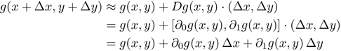

*g* 在点 x, y 处的导数 Dg，是方括号中的那一对偏导数。这个由偏导数组成的协向量与增量向量的内积，就是函数 *g* 的增量。general-derivative 过程计算的正是这个结果：The derivative *Dg* of *g* at the point *x, y* is the pair of partial derivatives in square brackets. The inner product of that *covector* of partials with the *vector* of increments is the increment to the function *g*. The general-derivative procedure computes this result:

```
(define (general-derivative g)

  (define ((the-derivative . args) . increments)

    (let ((n (length args)))

      (assert (= n (length increments)))

      (if (= n 1)

          (* ((derivative g) (car args))

             (car increments))

          (reduce (lambda (x y) (+ y x))

                  0

                  (map (lambda (i inc)

                         (* (apply ((partial i) g) args)

                             inc))

                       (iota n)

                       increments)))))

  the-derivative)
```

遗憾的是，general-derivative 并不返回偏导数所组成的结构。在许多场合，若有一个真正给出偏导数协向量的求导过程 gradient，会很有用。（见练习 3.10。）Unfortunately general-derivative does not return the structure of partial derivatives. It is useful in many contexts to have a derivative procedure gradient that actually gives the covector of partial derivatives. (See exercise 3.10.)

## 练习 3.8：偏导数Exercise 3.8: Partial derivatives

理解偏导数的另一种方式，是从 *λ* 演算中的柯里化入手。画一幅图，说明数据必须如何流动。用柯里化固定那些保持不变的参数，生成一个单参数过程，再对它应用普通的求导运算。编写这个版本的偏导数过程。Another way to think about partial derivatives is in terms of *λ*-calculus currying. Draw a diagram of how the data must flow. Use currying to fix the arguments that are held constant, producing a one-argument procedure that the ordinary derivative will be applied to. Write that version of the partial derivative procedure.

## 练习 3.9：添加处理过程Exercise 3.9: Adding handlers

有些基本算术函数，我们尚未为其添加处理微分对象的处理过程，例如 tan。There are primitive arithmetic functions for which we did not add handlers for differential objects, for example tan.

1. a. 为 tan 和 atan1 添加处理过程（atan1 是一个单参数函数）。**a.** Add handlers for tan and atan1 (atan1 is a function of one argument).
2. b. 如果能让 atan 像 Scheme 报告 [109] 中那样，也可以接受两个参数，那就太好了，因为我们通常希望保留所在象限的信息。修改泛型过程 atan，使它正确地做到这一点：只有一个参数时使用 atan1，给出两个参数时使用 atan2。另外，为微分量安装一个 atan2 处理过程。记住，它必须与 atan1 处理过程共存。**b.** It would be really nice to have atan optionally take two arguments, as in the Scheme Report [109], because we usually want to preserve the quadrant we are working in. Fix the generic procedure atan to do this correctly—using atan1 for one argument and atan2 if given two arguments. Also, install an atan2 handler for differentials. Remember, it must coexist with the atan1 handler.

## 练习 3.10：向量与协向量Exercise 3.10: Vectors and covectors

如上所述，导数的概念可以推广到多参数函数。多参数函数的 gradient 是由相对于每个参数的偏导数组成的协向量。As described above, the idea of derivative can be generalized to functions with multiple arguments. The gradient of a function of multiple arguments is the covector of partial derivatives with respect to each of the arguments.

1. a. 设计向量和协向量的数据类型，使 Dg(x, y) 的值为偏导数的协向量。编写一个给出该值的 gradient 过程。记住，向量与协向量的乘积应当是它们的内积，即各对应分量乘积之和。**a.** Develop data types for vectors and covectors such that the value of *Dg*(*x, y*) is the covector of partials. Write a gradient procedure that delivers that value. Remember, the product of a vector and a covector should be their inner product—the sum of the componentwise products of their elements.
2. b. 注意，如果函数的输入是向量，就类似于有多个输入，因此梯度的输出应当是协向量。还要注意，如果函数的输入是协向量，那么梯度的输出应当是向量。实现这些行为。**b.** Notice that if the input to a function is a vector, that is similar to multiple inputs, so the output of the gradient should be a covector. Note also that if the input to a function is a covector, then the output of the gradient should be a vector. Make this work.

### 3.3.3 一些技术细节3.3.3 Some technical details

虽然自动微分背后的思想并不复杂，但要使它正确工作，还必须处理一些微妙的技术细节。Although the idea behind automatic differentiation is not complicated, there are a number of subtle technical details that must be addressed for it to work correctly.

#### 微分代数Differential algebra

如果要计算二阶导数，就必须对导函数求导。对这样的函数求值时，会有两个无穷小量参与其中。为了计算多阶导数以及多变量函数的导数，我们在“无穷小空间”中定义一种微分对象的代数。这些对象是多元幂级数，其中任何无穷小增量的指数都不大于一。<sup>23</sup>If we want to compute a second derivative we must take a derivative of a derivative function. The evaluation of such a function will have two infinitesimals in play. To enable the computation of multiple derivatives and derivatives of functions of several variables we define an algebra of differential objects in “infinitesimal space.” The objects are multivariate power series in which no infinitesimal increment has exponent greater than one.<sup>23</sup>

微分对象用一个带标记的列表表示，列表中存放幂级数的各项。每一项都有一个系数和一个无穷小增量因子列表。各项按阶数降序排列。（阶数就是增量因子的个数。因此，δxδy 的阶数高于 δx 或 δy。）下面是一个简陋但可用的实现：<sup>24</sup>A differential object is represented by a tagged list of the terms of a power series. Each term has a coefficient and a list of infinitesimal incremental factors. The terms are kept sorted, in descending order. (Order is the number of incrementals. So *δxδy* is higher order than *δx* or *δy*.) Here is a quick and dirty implementation:<sup>24</sup>

```
(define differential-tag 'differential)



(define (differential? x)

  (and (pair? x) (eq? (car x) differential-tag)))



(define (diff-terms h)

  (if (differential? h)

      (cdr h)

      (list (make-diff-term h ’()))))
```

项列表就是微分对象的 cdr。不过，如果给定的对象不是显式的微分对象，例如一个数，我们就将它强制转换为只有一项、且不含增量因子的微分对象。根据一个（预先排好序的）项列表构造微分对象时，我们总是尽量返回简化后的形式；它可能只是一个数，而不是显式的微分对象：The term list is just the cdr of the differential object. However, if we are given an object that is not explicitly a differential object, for example a number, we coerce it to a differential object with a single term and with no incremental factors. When we make a differential object from a (presorted) list of terms, we always try to return a simplified version, which may be just a number, which is not explicitly a differential object:

```
(define (make-differential terms)

  (let ((terms                       ; Nonzero terms

         (filter

          (lambda (term)

            (let ((coeff (diff-coefficient term)))

              (not (and (number? coeff) (= coeff 0)))))

          terms)))

    (cond ((null? terms) 0)

          ((and (null? (cdr terms))

                ;; Finite part only:

                (null? (diff-factors (car terms))))

           (diff-coefficient (car terms)))

          ((every diff-term? terms)

           (cons differential-tag terms))

          (else (error "Bad terms")))))
```

在这个实现中，各项也用带标记的列表表示，每个列表包含一个系数和一个有序的因子列表。In this implementation the terms are also represented as tagged lists, each containing a coefficient and an ordered list of factors.

```
(define diff-term-tag 'diff-term)



(define (make-diff-term coefficient factors)

  (list diff-term-tag coefficient factors))



(define (diff-term? x)

  (and (pair? x) (eq? (car x) diff-term-tag)))



(define (diff-coefficient x)

  (cadr x))



(define (diff-factors x)

  (caddr x))
```

要计算导数，我们需要能够对微分对象做加法和乘法：To compute derivatives we need to be able to add and multiply differential objects:

```
(define (d:+ x y)

  (make-differential

   (+diff-termlists (diff-terms x) (diff-terms y))))



(define (d:* x y)

  (make-differential

   (*diff-termlists (diff-terms x) (diff-terms y))))
```

我们还需要这个：and we also need this:

```
(define (make-infinitesimal dx)

  (make-differential (list (make-diff-term 1 (list dx)))))
```

在项列表的加法中，我们确保并利用各项的排序，让高阶项位于列表前面。只有因子相同的两项才能相加。如果系数之和为零，就不把所得的项包括在结果中。Addition of term lists is where we enforce and use the sorting of terms, with higher-order terms coming earlier in the lists. We can add two terms only if they have the same factors. And if the sum of the coefficients is zero we do not include the resulting term.

```
(define (+diff-termlists l1 l2)

  (cond ((null? l1) l2)

        ((null? l2) l1)

        (else

         (let ((t1 (car l1)) (t2 (car l2)))

           (cond ((equal? (diff-factors t1) (diff-factors t2))

                  (let ((newcoeff (+ (diff-coefficient t1)

                                     (diff-coefficient t2))))

                    (if (and (number? newcoeff)

                             (= newcoeff 0))

                        (+diff-termlists (cdr l1) (cdr l2))

                        (cons

                         (make-diff-term newcoeff

                                         (diff-factors t1))

                         (+diff-termlists (cdr l1)

                                          (cdr l2))))))

                 ((diff-term>? t1 t2)

                  (cons t1 (+diff-termlists (cdr l1) l2)))

                 (else

                  (cons t2

                        (+diff-termlists l1 (cdr l2)))))))))
```

只要能对单独的项做乘法，项列表的乘法就很直接。两个项列表 l1 和 l2 的乘积，是将 l1 中的每一项与 l2 中的每一项相乘，再把所得的各个项列表相加得到的项列表。Multiplication of term lists is straightforward, if we can multiply individual terms. The product of two term lists l1 and l2 is the term list resulting from adding up the term lists resulting from multiplying every term in l1 by every term in l2.

```
(define (*diff-termlists l1 l2)

  (reduce (lambda (x y)

            (+diff-termlists y x))

          ’()

          (map (lambda (t1)

                 (append-map (lambda (t2)

                               (*diff-terms t1 t2))

                             l2))

               l1)))
```

一项具有一个系数和一个因子列表（即那些无穷小量）。微分对象中，任何一项都不能含有指数大于一的无穷小量，因为 δx<sup>2</sup> = 0。因此，将两项相乘时，必须检查要合并的因子列表是否没有共同的因子。这就是 *diff-terms 返回只含乘积项的列表或空列表的原因，这些列表随后在 *diff-termlists 中被拼接起来。合并两个因子列表时，我们保持因子的有序性；这样更容易对各项排序。A term has a coefficient and a list of factors (the infinitesimals). In a differential object no term may have an infinitesimal with an exponent greater than one, because *δx*<sup>2</sup> = 0. Thus, when we multiply two terms we must check that the lists of factors we are merging have no factors in common. This is the reason that *diff-terms returns a list of the product term or an empty list, to be appended in *diff-termlists. We keep the factors sorted when we merge the two lists of factors; this makes it easier to sort the terms.

```
(define (*diff-terms x y)

  (let ((fx (diff-factors x)) (fy (diff-factors y)))

    (if (null? (ordered-intersect diff-factor>? fx fy))

        (list (make-diff-term

               (* (diff-coefficient x) (diff-coefficient y))

               (ordered-union diff-factor>? fx fy)))

        ’())))
```

#### 有限部分与无穷小部分Finite and infinitesimal parts

微分对象具有有限部分和无穷小部分。第 109 页的 diff:binary-proc 过程，对于含有多个无穷小量的微分对象并不正确。为了确保以一致的方式选取参数 x 和 y 的各个部分，我们实际使用的是：A differential object has a finite part and an infinitesimal part. Our diff:binary-proc procedure on page 109 is not correct for differential objects with more than one infinitesimal. To ensure that the parts of the arguments x and y are selected consistently we actually use:

```
(define (diff:binary-proc f d0f d1f)

  (define (bop x y)

    (let ((factor (maximal-factor x y)))

      (let ((dx (infinitesimal-part x factor))

            (dy (infinitesimal-part y factor))

            (xe (finite-part x factor))

            (ye (finite-part y factor)))

        (d:+ (f xe ye)

             (d:+ (d:* dx (d0f xe ye))

                  (d:* (d1f xe ye) dy))))))

  bop)
```

其中，factor 由 maximal-factor 选出，使 x 和 y 都在一个因子数最多的项中含有它。where factor is chosen by maximal-factor so that both x and y contain it in a term with the largest number of factors.

微分对象的有限部分，是除去那些含有最高阶项中最大因子的项后所剩的所有项；无穷小部分则是其余的项，它们都含有该因子。The finite part of a differential object is all terms except for terms containing the maximal factor in a term of highest order, and the infinitesimal part is the remaining terms, all of which contain that factor.

考虑下面的计算：Consider the following computation:

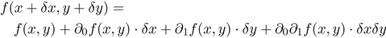

最高阶项是 ∂<sub>0</sub>∂<sub>1</sub>*f* (x, y) · δxδy。它关于 *x* 和 *y* 是对称的。关键在于，我们可以选择任意一个最大因子（这里是 δx 或 δy）作为主因子，并按任何与这一选择一致的方式把微分对象分成两部分。选哪一个并不重要，因为 R → R 的混合偏导数可以交换求导次序。<sup>25</sup>The highest-order term is *∂*<sub>0</sub>*∂*<sub>1</sub>*f* (*x, y*) · *δxδy*. It is symmetrical with respect to *x* and *y*. The crucial point is that we may break the differential object into parts in any way consistent with any one of the maximal factors (here *δx* or *δy*) being primary. It doesn't matter which is chosen, because mixed partials of **R** **→** **R** commute.<sup>25</sup>

```
(define (finite-part x #!optional factor)

  (if (differential? x)

      (let ((factor (default-maximal-factor x factor)))

        (make-differential

         (remove (lambda (term)

                   (memv factor (diff-factors term)))

                 (diff-terms x))))

      x))



(define (infinitesimal-part x #!optional factor)

  (if (differential? x)

      (let ((factor (default-maximal-factor x factor)))

        (make-differential

         (filter (lambda (term)

                   (memv factor (diff-factors term)))

                 (diff-terms x))))

      0))



(define (default-maximal-factor x factor)

  (if (default-object? factor)

      (maximal-factor x)

      factor))
```

#### 提取操作究竟如何工作How extracting really works

如第 114 页所述，为了能够求多阶导数，或者处理有多个参数的函数，微分对象用多元幂级数表示，其中任何无穷小增量的指数都不大于一。级数的每一项都有一个系数和一个无穷小增量因子列表。这使得提取相对于任意一个增量因子的导数变得复杂。实际情况如下：As explained on page 114, to make it possible to take multiple derivatives or to handle functions with more than one argument, a differential object is represented as a multivariate power series in which no infinitesimal increment has exponent greater than one. Each term in this series has a coefficient and a list of infinitesimal incremental factors. This complicates the extraction of the derivative with respect to any one incremental factor. Here is the real story:

如果返回的是微分对象，我们必须在结果中找出含有无穷小因子 dx 的那些项，这个因子对应于正在计算的导数。我们收集这些项，并从每一项中去掉 dx。如果取出含有 dx 的项并作上述处理后没有留下任何项，导数的值就是零。如果恰好剩下一项，而且它不含微分因子，那么这一项的系数就是导数的值。但如果剩余的项仍含有微分因子，就必须把由这些剩余项构成的微分对象作为导数的值返回。In the case where a differential object is returned we must find those terms of the result that contain the infinitesimal factor dx for the derivative we are evaluating. We collect those terms, removing dx from each. If there are no terms left after taking out the ones with dx, the value of the derivative is zero. If there is exactly one term left, which has no differential factors, then the coefficient of that term is the value of the derivative. But if there are remaining terms with differential factors, we must return the differential object with those residual terms as the value of the derivative.

```
(define (extract-dx-differential value dx)

  (let ((dx-diff-terms

         (filter-map

          (lambda (term)

            (let ((factors (diff-factors term)))

              (and (memv dx factors)

                   (make-diff-term (diff-coefficient term)

                                   (delv dx factors)))))

          (diff-terms value))))

    (cond ((null? dx-diff-terms) 0)

          ((and (null? (cdr dx-diff-terms))

                (null? (diff-factors (car dx-diff-terms))))

           (diff-coefficient (car dx-diff-terms)))

          (else (make-differential dx-diff-terms)))))



(define-generic-procedure-handler extract-dx-part

  (match-args differential? diff-factor?)

  extract-dx-differential)
```

#### 高阶函数Higher-order functions

在许多应用中，我们希望自动微分器能够正确处理返回函数值的函数：For many applications we want our automatic differentiator to work correctly for functions that return functions as values:

```
(((derivative

   (lambda (x)

     (lambda (y z)

       (* x y z))))

  2)

 3

 4)

;Value: 12
```

再加上字面函数和偏导数，情况就更有趣了。Including literal functions and partial derivatives makes this even more interesting.

```
((derivative

  (lambda (x)

    (((partial 1) (literal-function ’f))

     x ’v)))

 ’u)

(((partial 0) ((partial 1) f)) u v)
```

情况甚至还会更加复杂：And things can get even more complicated:

```
(((derivative

   (lambda (x)

     (derivative

      (lambda (y)

        ((literal-function ’f)

         x y)))))

  ’u)

 ’v)

(((partial 0) ((partial 1) f)) u v)
```

要使这些情况正常工作，过程 extract-dx-part 就会变得相当复杂。Making this work introduces serious complexity in the procedure extract-dx-part.

如果将函数应用于微分对象所得到的结果是一个函数，例如导数的导数，我们就需要推迟提取操作，直到那个函数被传入参数并调用时再进行：If the result of applying a function to a differential object is a function—a derivative of a derivative, for example—we need to defer the extraction until that function is called with arguments:

在返回函数的情况下，例如In a case where a function is returned, as in

```
(((derivative

   (lambda (x)

     (derivative

      (lambda (y)

        (* x y)))))

  ’u)

 ’v)

1
```

我们无法在函数应用于参数之前提取导数。因此，我们推迟提取，直到获得这次应用所产生的值。我们扩展泛型提取器：we cannot extract the derivative until the function is applied to arguments. So we defer the extraction until we get the value resulting from that application. We extend our generic extractor:

```
(define (extract-dx-function fn dx)

  (lambda args

    (extract-dx-part (apply fn args) dx)))



(define-generic-procedure-handler extract-dx-part

  (match-args function? diff-factor?)

  extract-dx-function)
```

遗憾的是，这一版 extract-dx-function 有一个微妙的错误。<sup>26</sup> 我们的修补办法是，用一段重新映射因子 dx 的代码包裹新的延迟过程的过程体，以避免这种麻烦的冲突。因此，我们把函数的处理过程改为：Unfortunately, this version of extract-dx-function has a subtle bug.<sup>26</sup> Our patch is to wrap the body of the new deferred procedure with code that remaps the factor dx to avoid the unpleasant conflict. So, we change the handler for functions to:

```
(define (extract-dx-function fn dx)

  (lambda args

    (let ((eps (make-new-dx)))

       (replace-dx dx eps

        (extract-dx-part

         (apply fn

           (map (lambda (arg)

                  (replace-dx eps dx arg))

                args))

         dx)))))
```

这会创建一个全新的因子 eps，并在参数中用它代表 dx，从而避免与其他任何 dx 实例发生冲突。This creates a brand-new factor eps and uses it to stand for dx in the arguments, thus preventing collision with any other instances of dx.

因子的替换本身也稍微复杂一些，因为代码必须深入遍查数据结构。我们将把替换操作做成泛型过程，以便将它扩展到新的数据种类。默认情况下，替换只是对象上的恒等操作：Replacement of the factors is itself a bit more complicated, because the code has to grovel around in the data structures. We will make the replacement a generic procedure, so we can extend it to new kinds of data. The default is that the replacement is just the identity on the object:

```
(define (replace-dx-default new-dx old-dx object) object)



(define replace-dx

  (simple-generic-procedure ’replace-dx 3

                            replace-dx-default))
```

对于微分对象，我们必须真正进入其内部，用新因子替换旧因子，并且必须保持因子列表的有序性：For a differential object we have to actually go in and substitute the new factor for the old one, and we have to keep the factor lists sorted:

```
(define (replace-dx-differential new-dx old-dx object)

  (make-differential

   (sort (map (lambda (term)

                (make-diff-term

                 (diff-coefficient term)

                 (sort (substitute new-dx old-dx

                                   (diff-factors term))

                       diff-factor>?)))

              (diff-terms object))

         diff-term>?)))



(define-generic-procedure-handler replace-dx

  (match-args diff-factor? diff-factor? differential?)

  replace-dx-differential)
```

最后，如果对象本身是函数，我们就必须推迟操作，直到有了参数、能够计算出一个值时再进行：Finally, if the object is itself a function we have to defer it until arguments are available to compute a value:

```
(define (replace-dx-function new-dx old-dx fn)

  (lambda args

    (let ((eps (make-new-dx)))

      (replace-dx old-dx eps

        (replace-dx new-dx old-dx

          (apply fn

            (map (lambda (arg)

                   (replace-dx eps old-dx arg))

                 args)))))))



(define-generic-procedure-handler replace-dx

  (match-args diff-factor? diff-factor? function?)

  replace-dx-function)
```

这比我们可能预想的复杂得多。它实际上对微分因子做了三次替换。这是为了避免与 fn 的过程体中可能自由出现的因子发生冲突；这些因子继承自函数 fn 定义时的词法环境。<sup>27</sup>This is quite a bit more complicated than we might expect. It actually does three replacements of the differential factors. This is to prevent collisions with factors that may be free in the body of fn that are inherited from the lexical environment of definition of the function fn.<sup>27</sup>

## 练习 3.11：那个错误！Exercise 3.11: The bug!

在得知第 121 页脚注 26 指出的错误之前，过程 extract-dx-function 是这样写的：Before we became aware of the bug pointed out in footnote 26 on page 121, the procedure extract-dx-function was written:

```
(define (extract-dx-function fn dx)

  (lambda args

    (extract-dx-part (apply fn args) dx)))
```

构造一个函数，使其导数用这一早期版本的 extract-dx-part 计算时是错误的，而用修正后的版本计算时是正确的，以此说明为什么要使用 replace-dx 包装层。这并不容易！你可能需要阅读脚注 26 指向的参考文献。Demonstrate the reason for the use of the replace-dx wrapper by constructing a function whose derivative is wrong with this earlier version of extract-dx-part but is correct in the fixed version. This is not easy! You may want to read the references pointed at in footnote 26.

### 3.3.4 接受微分参数的字面函数3.3.4 Literal functions of differential arguments

对于简单参数，应用字面函数，只需构造一个表达式，表示将函数表达式应用于这些参数。但字面函数也必须能够接受微分对象作为参数。这时，字面函数必须为那些微分量参数构造（偏）导数表达式。对于一个 n 参数函数的第 i 个参数，适当的导数表达式为：For simple arguments, applying a literal function is just a matter of constructing the expression that is the application of the function expression to the arguments. But literal functions must also be able to accept differential objects as arguments. When that happens, the literal function must construct (partial) derivative expressions for the arguments that are differentials. For the ith argument of an n-argument function the appropriate derivative expression is:

```
(define (deriv-expr i n fexp)

  (if (= n 1)

      ‘(derivative ,fexp)

      ‘((partial ,i) ,fexp)))
```

有些参数可能是微分对象，因此字面函数必须为每个参数选定有限部分和无穷小部分。与二元算术处理过程一样，必须以一致的方式选取最大因子。我们的字面函数能够接受多个参数，所以这看起来可能很复杂，但我们编写的 maximal-factor 过程能够处理多个参数。这一点解释于Some arguments may be differential objects, so a literal function must choose, for each argument, a finite part and an infinitesimal part. Just as for binary arithmetic handlers, the maximal factor must be consistently chosen. Our literal functions are able to take many arguments, so this may seem complicated, but we wrote the maximal-factor procedure to handle many arguments. This is explained in 第 3.3.3 节中解释。section 3.3.3.

如果参数中没有微分对象，我们只需用 cons 构造所需的表达式。如果有微分对象，就需要求字面函数的导数。为此，我们从所有参数中找出一个最大因子，并分离出各参数的有限部分，即不含该因子的项。（无穷小部分就是含有该因子的项。）偏导数本身也是字面函数，其表达式在构造时加入了参数的索引。所得的微分对象，就是在各参数有限部分处求得的偏导数与各参数无穷小部分的内积。If there are no differential objects among the arguments we just cons up the required expression. If there are differential objects we need to make a derivative of the literal function. To do this we find a maximal factor from all of the arguments and separate out the finite parts of the arguments—the terms that do not have that factor. (The infinitesimal parts are the terms that have that factor.) The partial derivatives are themselves literal functions with expressions that are constructed to include the argument index. The resulting differential object is the inner product of the partial derivatives at the finite parts of the arguments with the infinitesimal parts of the arguments.

下面的过程将这些内容汇集在一起：This is all brought together in the following procedure:

```
(define (literal-function fexp)

  (define (the-function . args)

    (if (any differential? args)

        (let ((n (length args))

              (factor (apply maximal-factor args)))

          (let ((realargs

                 (map (lambda (arg)

                        (finite-part arg factor))

                      args))

                (deltargs

                 (map (lambda (arg)

                        (infinitesimal-part arg factor))

                      args)))

            (let ((fxs (apply the-function realargs))

                  (partials

                   (map (lambda (i)

                          (apply (literal-function

                                  (deriv-expr i n fexp))

                                 realargs))

                        (iota n))))

              (fold d:+ fxs

                (map d:* partials deltargs)))))

        ‘(,fexp ,@args)))

  the-function)
```

## 练习 3.12：返回结构化值的函数Exercise 3.12: Functions with structured values

我们将 extract-dx-part 过程做成了泛型过程（第 110 页），以便将它扩展到微分对象和函数以外的值。扩展 extract-dx-part，使其能够处理返回向量的函数的导数。注意：你还必须扩展提取器中的泛型过程 replace-dx（第 122 页）。We made the extract-dx-part procedure generic (page 110) so we could extend it for values other than differential objects and functions. Extend extract-dx-part to work with derivatives of functions that return vectors. Note: You also have to extend the replace-dx generic procedure (page 122) in the extractor.

## 3.4 高效的泛型过程3.4 Efficient generic procedures

在In 第 3.2.3 节section 3.2.3我们利用元数据中提供的分派存储，查找适用的规则，从而分派到一个处理过程： we dispatched to a handler by finding an applicable rule using the dispatch store provided in the metadata:

```
(define (generic-procedure-dispatch metadata args)

  (let ((handler

         (get-generic-procedure-handler metadata args)))

    (apply handler args)))
```

我们在第 89 页用来构造 simple-generic-procedure 构造器的分派存储实现（第 98 页）相当简陋。简单分派存储将规则集维护为一个规则列表。每条规则表示为一个适用性说明与一个处理过程组成的序对。适用性说明是由谓词列表组成的列表，这些谓词要应用于传入的参数。由 simple-generic-procedure 构造的泛型过程，通过顺序扫描规则列表、寻找参数所满足的适用性说明，来找到恰当的处理过程。The implementation of the dispatch store (on page 98) we used (on page 89) to make the simple-generic-procedure constructor was rather crude. The simple dispatch store maintains the rule set as a list of rules. Each rule is represented as a pair of an applicability and a handler. The applicability is a list of lists of predicates to apply to tendered arguments. The way a generic procedure constructed by simple-generic-procedure finds an appropriate handler is to sequentially scan the list of rules looking for an applicability that is satisfied by the arguments.

这非常低效，因为许多规则的适用性说明可能在某个给定的操作数位置上具有相同的谓词。例如，在一个兼有数值算术和符号算术的系统中，可能有许多乘法规则的第一个谓词都是 number?。因此，在找到适用规则之前，可能会多次应用 number? 谓词。如果能组织好规则，使查找适用规则时不做冗余测试，那就好了。通常可以用索引来实现这一点。This is seriously inefficient, because the applicability of many rules may have the same predicate in a given operand position: For example, for multiplication in a system of numerical and symbolic arithmetic there may be many rules whose first predicate is number?. So the number? predicate may be applied many times before finding an applicable rule. It would be good to organize the rules so that finding an applicable one does not perform redundant tests. This is usually accomplished by the use of an index.

### 3.4.1 前缀树3.4.1 Tries

一种简单的索引机制基于前缀树。<sup>28</sup>One simple index mechanism is based on the *trie*.<sup>28</sup>

前缀树通常是一种树结构，但更一般地说，它也可以是有向图。前缀树的每个节点都有连接到后继节点的边。每条边都关联着一个谓词。接受测试的数据是一个线性的特征序列，在这里就是泛型过程的参数。A trie is traditionally a tree structure, but more generally it may be a directed graph. Each node in the trie has edges connecting to successor nodes. Each edge has an associated predicate. The data being tested is a linear sequence of features, in this case the arguments to a generic procedure.

从前缀树的根节点开始，取出序列中的第一个特征，用从根节点出发的各条边上的谓词分别测试它。沿着测试成功的谓词所在的边进入下一个节点，然后对特征序列的剩余部分重复这一过程。当所有特征都用完时，当前节点中就存有相关联的值，在这里就是适用于这些参数的处理过程。Starting at the root of the trie, the first feature is taken from the sequence and is tested by each predicate on an edge emanating from the root node. The successful predicate's edge is followed to the next node, and the process repeats with the remainder of the sequence of features. When we run out of features, the current node will contain the associated value, in this case an applicable handler for the arguments.

在任意节点，都可能有多个谓词测试成功。如果发生这种情况，就必须沿所有成功的分支继续查找。因此，可能会有多个适用的处理过程，必须另有办法来决定该怎么办。It is possible that at any node, more than one predicate may succeed. If this happens, then all of the successful branches must be followed. Thus there may be multiple applicable handlers, and there must be a separate means of deciding what to do.

下面说明如何使用前缀树。对以下命令序列求值，会逐步构造出图 3.1 所示的前缀树。Here is how we can use a trie. Evaluating the following sequence of commands will incrementally construct the trie shown in figure 3.1.

a-trie：一棵字典树；negative-number?：负数判断；even-number?：偶数判断；symbol?：符号判断；number?：数值判断。

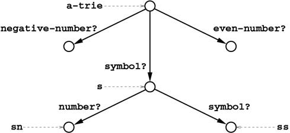

图 3.1 前缀树可用于对特征序列进行分类。前缀树是一种有向图，其中每条边都有一个谓词。从根节点开始，用从根节点出发的各条边上的谓词测试第一个特征。如果某个谓词得到满足，就移动到那条边末端的节点，测试下一个特征。对后续特征重复这一过程。所到达的终端节点集合，就是该序列的分类结果。Figure 3.1 A trie can be used to classify sequences of features. A trie is a directed graph in which each edge has a predicate. Starting at the root, the first feature is tested by each predicate on an edge proceeding from the root. If a predicate is satisfied, the process moves to the node at the end of that edge and the next feature is tested. This is repeated with successive features. The classification of the sequence is the set of terminal nodes arrived at.

```
(define a-trie (make-trie))
```

我们可以向这棵前缀树添加一条边We can add an edge to this trie

```
(define s (add-edge-to-trie a-trie symbol?))
```

其中，add-edge-to-trie 返回位于新边目标端的新节点。对符号进行匹配会到达这个节点。where add-edge-to-trie returns the new node that is at the target end of the new edge. This node is reached by being matched against a symbol.

我们可以构造由多条边组成的链，并用相应边上的谓词所组成的列表来引用这些链We can make chains of edges, which are referenced by lists of the corresponding edge predicates

```
(define sn (add-edge-to-trie s number?))
```

从根节点沿路径 (list symbol? number?) 可到达节点 sn。使用路径来构造边链，有一种比反复调用 add-edge-to-trie 更简单的方法：The node sn is reached from the root via the path (list symbol? number?). Using a path, there is a simpler way to make a chain of edges than repeatedly calling add-edge-to-trie:

```
(define ss (intern-path-trie a-trie (list symbol? symbol?)))
```

我们可以给任何节点添加一个值（这里展示的是符号值，但稍后我们将存储作为处理过程的过程值）：We can add a value to any node (here we show symbolic values, but we will later store values that are procedural handlers):

```
(trie-has-value? sn)

#f



(set-trie-value! sn ’(symbol number))



(trie-has-value? sn)

#t



(trie-value sn)

(symbol number)
```

我们也可以用基于路径的接口来设置值We can also use a path-based interface to set values

```
(set-path-value! a-trie (list symbol? symbol?)

                ’(symbol symbol))



(trie-value ss)

(symbol symbol)
```

注意，intern-path-trie 和 set-path-value! 都会尽可能重用现有的节点和边，只在必要时添加边和节点。Note that both intern-path-trie and set-path-value! reuse existing nodes and edges when possible, adding edges and nodes where necessary.

现在，我们可以将一个特征序列与目前构造出的前缀树进行匹配：Now we can match a feature sequence against the trie we have constructed so far:

```
(equal? (list ss) (get-matching-tries a-trie ’(a b)))

#t



(equal? (list s) (get-matching-tries a-trie ’(c)))

#t
```

我们还可以将匹配与取值结合起来。过程 get-a-value 找出所有匹配的节点，从中选出一个具有值的节点，并返回该值。We can also combine matching with value fetching. The procedure get-a-value finds all matching nodes, picks one that has a value, and returns that value.

```
(get-a-value a-trie ’(a b))

(symbol symbol)
```

但并非所有特征序列都有相关联的值：But not all feature sequences have an associated value:

```
(get-a-value a-trie ’(-4))

;Unable to match features: (-4)
```

我们可以逐步给前缀树中的节点添加值：We can incrementally add values to nodes in the trie:

```
(set-path-value! a-trie (list negative-number?)

                 ’(negative-number))

(set-path-value! a-trie (list even-number?)

                 ’(even-number))



(get-all-values a-trie ’(-4))

((even-number) (negative-number))
```

其中，get-all-values 找出与给定特征序列匹配的所有节点，并返回它们的值。where get-all-values finds all the nodes matching a given feature sequence and returns their values.

有了这个前缀树实现，我们就能构造一个以它为索引的分派存储：Given this trie implementation, we can make a dispatch store that uses a trie as its index:

```
(define (make-trie-dispatch-store)

  (let ((delegate (make-simple-dispatch-store))

        (trie (make-trie)))

    (define (get-handler args)

      (get-a-value trie args))

    (define (add-handler! applicability handler)

      ((delegate ’add-handler!) applicability handler)

      (for-each (lambda (path)

                  (set-path-value! trie path handler))

                applicability))

    (lambda (message)

      (case message

        ((get-handler) get-handler)

        ((add-handler!) add-handler!)

        (else (delegate message))))))
```

我们将大部分操作委托给一个简单分派存储，从而使这个分派存储保持简单。没有被委托的操作是 add-handler! 和 get-handler：前者把处理过程同时存入简单分派存储和前缀树，后者则完全使用前缀树进行访问。简单分派存储管理默认处理过程，也管理规则集，这对调试很有用。与更广为人知的继承思想不同，这是通过委托来扩展接口的一个简单例子。We make this dispatch store simple by delegating most of the operations to a simple dispatch store. The operations that are not delegated are add-handler!, which simultaneously stores the handler in the simple dispatch store and also in the trie, and get-handler, which exclusively uses the trie for access. The simple dispatch store manages the default handler and also the set of rules, which is useful for debugging. This is a simple example of the use of delegation to extend an interface, as opposed to the better-known inheritance idea.

## 练习 3.13：前缀树规则Exercise 3.13: Trie rules

为了便于试验不同的分派存储，我们向 generic-procedure-constructor 和 make-generic-arithmetic 提供了分派存储构造器。例如，可以像第 95 页那样构造完整的泛型算术，但改用 make-trie-dispatch-store，如下所示：To make it easy to experiment with different dispatch stores, we gave generic-procedure-constructor and make-generic-arithmetic the dispatch store maker. For example, we can build a full generic arithmetic as on page 95 but using make-trie-dispatch-store as follows:

```
(define trie-full-generic-arithmetic

  (let ((g (make-generic-arithmetic make-trie-dispatch-store)))

    (add-to-generic-arithmetic! g numeric-arithmetic)

    (extend-generic-arithmetic! g function-extender)

    (add-to-generic-arithmetic! g

       (symbolic-extender numeric-arithmetic))

    g))



(install-arithmetic! trie-full-generic-arithmetic)
```

1. a. 这是否改变了我们在下述小节中费力处理的对顺序的依赖？**a.** Does this make any change to the dependence on order that we wrestled with in 第 3.2.2 节section 3.2.2?
2. b. 一般来说，谓词的哪些特征可能导致某个参数序列有多个适当处理过程的情况？**b.** In general, what characteristics of the predicates could produce situations where there is more than one appropriate handler for a sequence of arguments?
3. c. 我们的泛型算术代码中是否存在这样的情况？**c.** Are there any such situations in our generic arithmetic code?

我们提供了一个简陋的工具，用于衡量分派策略的效果。用 with-predicate-counts 包裹任意计算，就能知道每个分派谓词在一次执行中被调用了多少次。例如，在使用基于前缀树的分派存储的泛型算术中，对 (fib 20) 求值可能产生类似下面的结果：<sup>29</sup>We have provided a crude tool to measure the effectiveness of our dispatch strategy. By wrapping any computation with with-predicate-counts we can find out how many times each dispatch predicate is called in an execution. For example, evaluating (fib 20) in a generic arithmetic with a trie-based dispatch store may yield something like this:<sup>29</sup>

```
(define (fib n)

  (if (< n 2)

      n

      (+ (fib (- n 1)) (fib (- n 2)))))



(with-predicate-counts (lambda () (fib 20)))

(109453 number)

(109453 function)

(54727 any-object)

(109453 symbolic)

6765
```

## 练习 3.14：分派效率：意外的陷阱！Exercise 3.14: Dispatch efficiency: gotcha!

有了这个性能工具，考察以下计算的执行情况会很有启发：Given this performance tool it is instructive to look at executions of

```
(define (test-stormer-counts)

  (define (F t x) (- x))

  (define numeric-s0

    (make-initial-history 0 .01 (sin 0) (sin -.01) (sin -.02)))

  (with-predicate-counts

   (lambda ()

     (x 0 ((evolver F ’h stormer-2) numeric-s0 1)))))
```

一方面，使用 make-simple-dispatch-store 中基于规则列表的分派，所用算术由下式得到：for the rule-list–based dispatch in make-simple-dispatch-store, in the arithmetic you get by:

```
(define full-generic-arithmetic

  (let ((g (make-generic-arithmetic make-simple-dispatch-store)))

    (add-to-generic-arithmetic! g numeric-arithmetic)

    (extend-generic-arithmetic! g function-extender)

    (add-to-generic-arithmetic! g

            (symbolic-extender numeric-arithmetic))

    g))



(install-arithmetic! full-generic-arithmetic)
```

另一方面，使用基于前缀树的版本（练习 3.13），所用算术由下式得到：and the trie-based version (exercise 3.13), in the arithmetic you get by:

```
(install-arithmetic! trie-full-generic-arithmetic)
```

对于某些问题，前缀树的性能应当远好于简单的规则列表。如果有大量规则具有相同的起始片段，我们预期使用前缀树会有更好的性能。For some problems the trie should have much better performance than the simple rule list. We expect that the performance will be better with the trie if we have a large number of rules with the same initial segment.

理解这一点很重要，因为前缀树有时对性能没有帮助，这似乎有违直觉。我们引入前缀树的明确目的，就是避免冗余调用。用简短的一段话解释这一现象。Understanding this is important, because the fact that sometimes the trie does not help with the performance appears counterintuitive. We explicitly introduced the trie to avoid redundant calls. Explain this phenomenon in a concise paragraph.

要获得进一步的认识，可以考察 (fib 20) 在这两种实现中的性能。For an additional insight, look at the performance of (fib 20) in the two implementations.

当有多个处理过程适用于某个给定的参数序列时，应该如何使用它们并不明确；处理这种情况是消歧策略的职责。设计消歧策略时，需要考虑许多因素。例如，选择最特定的处理过程通常是一个好策略；不过，实现这种策略需要更多信息。有时，运行所有适用的处理过程并比较其结果是恰当的。这可以用来发现错误，并提供一种冗余。或者，如果每个处理过程提供的都是部分信息，例如数值区间，那么可以组合不同处理过程的结果，以获得更完善的信息。When more than one handler is applicable for a given sequence of arguments, it is not clear how to use those handlers; addressing this situation is the job of a *resolution* *policy*. There are many considerations when designing a resolution policy. For example, a policy that chooses the most specific handler is often a good policy; however, we need more information to implement such a policy. Sometimes it is appropriate to run all of the applicable handlers and compare their results. This can be used to catch errors and provide a kind of redundancy. Or if we have partial information provided by each handler, such as a numerical interval, the results of different handlers can be combined to provide better information.

### 3.4.2 缓存3.4.2 Caching

通过使用前缀树，我们消除了对参数谓词的冗余求值。我们还可以做得更好，用抽象完全消除谓词求值。谓词标识了一个对象集合，将其与其他所有对象区分开来；换句话说，谓词与它所区分出的集合实际上是同一回事。在前缀树实现中，我们利用谓词过程是否相等来避免冗余；否则，前缀树中就会出现冗余的边，它也就毫无帮助了。这也是谓词组合不太适合与前缀树实现混用的原因。With the use of tries we have eliminated redundant evaluation of argument predicates. We can do better by using abstraction to eliminate the evaluation of predicates altogether. A predicate identifies a set of objects that are distinguished from all other objects; in other words, the predicate and the set it distinguishes are effectively the same. In our trie implementation, we use the equality of the predicate procedures to avoid redundancy; otherwise we would have redundant edges in the trie and it would be no help at all. This is also why the use of combinations of predicates doesn't mix well with the trie implementation.

这里的问题是，我们想建立一个按谓词区分对象的索引，但过程的不透明性使它们作为索引键时并不可靠。我们真正想做的是，给某个谓词所区分出的集合指定一个名字。如果能够通过简单查看一个给定对象就得到这个名字，我们就完全不必计算谓词了。这个名字就是“类型”；但为避免混淆，我们将把这个名字称为标记。The problem here is that we want to build an index that discriminates objects according to predicates, but the opacity of procedures makes them unreliable when used as keys to the index. What we'd really like is to assign a name to the set distinguished by a given predicate. If we had a way to get that name from a given object by superficial examination, we could avoid computing the predicate at all. This name is a “type”; but in order to avoid confusion we will refer to this name as a *tag*.

有了从对象获取标记的方法，我们就能构造一个缓存，保存前一次分派得到的处理过程，并在其他参数具有相同标记模式的分派中重用它。但如果没有显式附加的标记，这种方法就有局限，因为我们只能按照实现规定的表示形式来区分对象。例如，区分数和符号很容易，但要区分素数就不容易了，因为实现通常不会对它们采用特殊表示。Given a way to get a tag from an object, we can make a cache that saves the handler resulting from a previous dispatch and reuses it for other dispatches whose arguments have the same tag pattern. But in the absence of explicitly attached tags, there are limitations to this approach, because we can only discriminate objects that share an implementation-specified representation. For example, it's easy to distinguish between a number and a symbol, but it's not easy to distinguish a prime number, because it's unusual for an implementation to represent them specially.

我们将在下述小节重新讨论显式标记的问题：We will return to the problem of explicit tagging in 第 3.5 节section 3.5，不过在此之前，仍然可以利用 Scheme 实现提供的表示标记，构造有用的缓存。给定一个实现特定的过程 implementation-type-name，用来获取对象的表示标记，我们就可以构造带缓存的分派存储：, but in the meantime it is still possible to make a useful cache using the representation tags from the Scheme implementation. Given an implementation-specific procedure implementation-type-name to obtain the representation tag of an object, we can make a cached dispatch store:

```
(define a-cached-dispatch-store

  (cache-wrapped-dispatch-store (make-trie-dispatch-store)

                                implementation-type-name))
```

这个分派存储在前缀树分派存储外包裹了一层缓存，但同样也可以用它来包裹简单分派存储。This dispatch store wraps a cache around a trie dispatch store, but it could just as well wrap a simple dispatch store.

带缓存分派存储的核心，是一个基于哈希表构建的记忆化器。哈希表的键，是由过程 implementation-type-name 从参数中提取出的表示标记列表。将 implementation-type-name 作为 get-key 传给这个分派存储包装层，就能用它为我们即将开发的更强大的标记机制构造带缓存的分派存储。The heart of the cached dispatch store is a memoizer built on a hash table. The key for the hash table is the list of representation tags extracted by the implementation-type-name procedure from the arguments. By passing implementation-type-name into this dispatch-store wrapper (as get-key) we can use it to make cached dispatch stores for more powerful tag mechanisms that we will develop soon.

```
(define (cache-wrapped-dispatch-store dispatch-store get-key)

  (let ((get-handler

         (simple-list-memoizer

           eqv?

           (lambda (args) (map get-key args))

           (dispatch-store ’get-handler))))

    (lambda (message)

      (case message

        ((get-handler) get-handler)

        (else (dispatch-store message))))))
```

对 simple-list-memoizer 的调用，会在它的最后一个参数外包裹一层缓存，生成该参数的记忆化版本。第二个参数指定如何从过程的参数中取得缓存键。eqv? 参数指定如何在缓存中判定标记是否相同。The call to simple-list-memoizer wraps a cache around its last argument, producing a memoized version of it. The second argument specifies how to get the cache key from the procedure's arguments. The eqv? argument specifies how the tags will be identified in the cache.

## 练习 3.15：缓存性能Exercise 3.15: Cache performance

使用我们在第 130 页为练习 3.14 引入的同一性能工具，针对练习 3.14 中考察过的那些泛型算术，测量带缓存的分派版本执行 (test-stormer-counts) 和 (fib 20) 时的情况。记录结果。比较起来如何？Using the same performance tool we introduced for exercise 3.14 on page 130, make measurements for execution of (test-stormer-counts) and (fib 20) in the cached version of dispatch with the same generic arithmetics explored in exercise 3.14. Record your results. How do they compare?

## 3.5 高效的用户定义类型3.5 Efficient user-defined types

在In 第 3.4.2 节section 3.4.2我们将标记作为分派缓存机制的一部分引入。每个参数都映射到一个标记，然后以标记列表为缓存键，获取处理过程。如果缓存中有与这个标记列表关联的处理过程，就使用它。否则，就利用谓词前缀树查找适当的处理过程，并将它存入缓存，与该标记列表关联起来。 we introduced tags as part of a caching mechanism for dispatch. Each argument is mapped to a tag, and the list of tags is then used as a key in a cache to obtain the handler. If the cache has a handler associated with this list of tags, it is used. If not, the trie of predicates is used to find the appropriate handler and it is entered into the cache associated with the list of tags.

这个机制相当粗糙：适用性说明中能用的谓词受到限制，对于标记相同的任意两个对象，它们必须总是给出相同的布尔值。因此，类型的区分不能比现有标记更精细。那些标记是实现特定的符号，如 pair、vector 或 procedure。这严重限制了可用的谓词。例如，我们无法制定规则，区分满足 even-integer? 的整数和满足 odd-integer? 的整数。This mechanism is pretty crude: the predicates that can be used for the applicability specifications are restricted to those that always give the same boolean value for any two objects with the same tag. So the discrimination of types cannot be any finer than the available tags. The tags were implementation-specific symbols, such as pair, vector, or procedure. So this severely limits the possible predicates. We could not have rules that distinguish between integers that satisfy even-integer? and integers that satisfy odd-integer?, for example.

我们需要一种标记系统，它既能在计算上轻易获取与数据项关联的标记，又不把标记限制为少量实现特定的值。通过显式的数据结构，或通过关联表，为每个数据项附加一个标记，就能做到这一点。What is needed is a system of tagging that makes it computationally easy to obtain the tag associated with a data item, but where the tags are not restricted to a small set of implementation-specific values. This can be accomplished by attaching a tag to each data item, either with an explicit data structure or via a table of associations.

这里有几个相互交织的问题：我们想在适用性说明中使用谓词；想要高效的分派机制；还想能够指定谓词之间的关系，并在分派中使用这些关系。例如，我们希望能够声明，谓词 integer? 是谓词 even-integer? 和 odd-integer? 的析取，还能声明 integer? 是 positive-integer?、negative-integer? 和 zero? 的析取。We have several problems interwoven here: we want to use predicates in applicability specifications; we want an efficient mechanism for dispatch; and we want to be able to specify relationships between predicates that can be used in the dispatch. For example, we want to be able to say that the predicate integer? is the disjunction of the predicates even-integer? and odd-integer?, and also that integer? is the disjunction of positive-integer?, negative-integer?, and zero?.

为表达这些关系，我们需要给谓词附加元数据；但若像第 28 页处理函数元数时那样，通过增加一次关联查找来获取谓词的元数据，就会带来过大的开销，因为元数据中会包含对其他标记的引用，而沿着这些引用进行查找必须是高效的。To capture such relationships we need to put metadata on the predicates; but adding an associative lookup to get the metadata of a predicate, as we did with the arity of a function (on page 28), adds too much overhead, because the metadata will contain references to other tags, and chasing these references must be efficient.

一种解决办法是注册所需的谓词。注册会创建一种新的标记，即与谓词关联的数据结构。这种标记很容易附加到被该谓词接受的对象上。标记也为存储元数据提供了便利的地方。One way out is to register the needed predicates. Registration creates a new kind of tag, a data structure that is associated with the predicate. The tag will be easy to attach to objects that are accepted by the predicate. The tag will provide a convenient place to store metadata.

我们将构造一个系统，其中每个独立对象只能有一个标记，而且可以声明谓词之间的关系。这看起来可能过于简单，但足以满足我们的目的。We will construct a system in which each distinct object can have only one tag and where relationships between predicates can be declared. This may appear to be overly simple, but it is adequate for our purposes.

### 3.5.1 用谓词表示类型3.5.1 Predicates as types

先从一些简单的谓词开始。例如，基本过程 exact-integer? 已经作为简单谓词预先注册到我们的系统中：Let's start with some *simple predicates*. For example, the primitive procedure exact-integer? is preregistered in our system as a simple predicate:

```
(predicate? exact-integer?)

#t
```

现在来定义一个新的、非基本的谓词。我们将以这个特别慢的素数测试为基础来构造它。Now let's define a new predicate that's not a primitive. We will build it on this particularly slow test for prime numbers.

```
(define (slow-prime? n)

  (and (n:exact-positive-integer? n)

       (n:>= n 2)

       (let loop ((k 2))

         (or (n:> (n:square k) n)

             (and (not (n:= (n:remainder n k) 0))

                  (loop (n:+ k 1)))))))
```

注意，所有算术运算符都加了 n: 前缀，以确保使用的是底层 Scheme 运算。Note that all of the arithmetic operators are prefixed with n: to ensure that we get the underlying Scheme operations.

我们构造抽象谓词 prime-number?，为其提供一个用于错误消息的名字，以及判定对象是否为素数的准则 slow-prime?：We construct the prime-number? abstract predicate, with a name for use in error messages and a criterion, slow-prime?, for an object to be considered a prime number:

```
(define prime-number?

  (simple-abstract-predicate ’prime-number slow-prime?))
```

过程 simple-abstract-predicate 创建一个抽象谓词，这是对代价高昂的谓词（这里是 slow-prime?）的结果进行记忆化的一种巧妙技巧。抽象谓词有一个相关联的构造器，用于创建带标记对象；该对象由抽象谓词的标记和一个对象组成。构造器要求待加标记的对象满足那个代价高昂的谓词。所得的带标记对象既满足抽象谓词，又携带其标记。因此，可以使用快速的抽象谓词，或等价地根据标记进行分派，来测试带标记对象是否具有那个代价高昂的谓词所定义的性质。The procedure simple-abstract-predicate creates an *abstract predicate*, which is a clever trick for memoizing the result of an expensive predicate (in this case slow-prime?). An abstract predicate has an associated constructor that is used to make a *tagged object*, consisting of the abstract predicate's tag and an object. The constructor requires that the object to be tagged satisfies the expensive predicate. The resulting tagged object satisfies the abstract predicate, as well as carrying its tag. Consequently the tagged object can be tested for the property defined by the expensive predicate by using the fast abstract predicate (or, equivalently, by dispatching on its tag).

例如，抽象谓词 prime-number? 用来给已验证为素数的对象加上标记，以便高效实现泛型分派。这一点很重要，因为我们不希望在分派过程中执行 slow-prime? 来判定一个数是否为素数。因此，我们构造一个新的带标记对象，其中既包含一个标记（prime-number? 的标记），也包含一个数据值（原始素数）。泛型过程收到带标记对象时，就能高效地取出其标记，并用它作为缓存键。For example, the abstract predicate prime-number? is used to tag objects that are verified prime numbers, for the efficient implementation of generic dispatch. This is important because we do not want to execute slow-prime? during the dispatch to determine whether a number is prime. So we build a new *tagged object*, which contains both a *tag* (the tag for prime-number?) and a *datum* (the raw prime number). When a generic procedure is handed a tagged object, it can efficiently retrieve its tag and use that as a cache key.

为了构造带标记对象，我们用 predicate-constructor 获取与抽象谓词相关联的构造器：In order to make tagged objects, we use predicate-constructor to get the constructor associated with the abstract predicate:

```
(define make-prime-number

  (predicate-constructor prime-number?))



(define short-list-of-primes

  (list (make-prime-number 2)

        (make-prime-number 7)

        (make-prime-number 31)))
```

构造器 make-prime-number 要求其参数必须是由 slow-prime? 判定的素数：这个构造器能加上标记的对象只能是素数。The constructor make-prime-number requires that its argument be prime, as determined by slow-prime?: the only objects that can be tagged by this constructor are prime numbers.

```
(make-prime-number 4)

;Ill-formed data for prime-number: 4
```

### 3.5.2 谓词之间的关系3.5.2 Relationships between predicates

用抽象谓词定义的集合之间可以存在关系。例如，素数集是正整数集的子集。正整数集、偶整数集和奇整数集都是整数集的子集。这很重要，因为任何适用于整数的操作，也适用于任一子集中的任意元素；但有些操作可以应用于子集中的元素，却不能应用于包含它的超集中所有元素。例如，偶整数除以二不会有余数，但对整个整数集而言并非如此。The sets that we can define with abstract predicates can be related to one another. For example, the primes are a subset of the positive integers. The positive integers, the even integers, and the odd integers are subsets of the integers. This is important because any operation that is applicable to an integer is applicable to any element of any subset, but there are operations that can be applied to an element of a subset that cannot be applied to all elements of an enclosing superset. For example, the even integers can be halved without leaving a remainder, but that is not true of the full integers.

定义 prime-number? 时，我们实际上定义了一个对象集合。但这个集合与 exact-integer? 定义的集合并没有关系：When we defined prime-number?, we effectively defined a set of objects. But that set has no relation to the set defined by exact-integer?:

```
(exact-integer? (make-prime-number 2))

#f
```

我们希望在这些集合之间建立恰当的关系，为此可以给谓词本身添加一些元数据：We would like these sets to be properly related, which is done by adding some metadata to the predicates themselves:

```
(set-predicate<=! prime-number? exact-integer?)
```

过程 set-predicate<=! 修改作为其参数的谓词的元数据，表明第一个参数定义的集合是第二个参数定义的集合的（非严格）子集。在这里，我们声明 prime-number? 定义的集合是 exact-integer? 定义的集合的子集。完成这一步之后，exact-integer? 就能识别我们的对象：This procedure set-predicate<=! modifies the metadata of its argument predicates to indicate that the set defined by the first argument is a (non-strict) subset of the set defined by the second argument. In our case, the set defined by prime-number? is declared to be a subset of the set defined by exact-integer?. Once this is done, exact-integer? will recognize our objects:

```
(exact-integer? (make-prime-number 2))

#t
```

### 3.5.3 谓词就是分派键3.5.3 Predicates are dispatch keys

我们定义的抽象谓词适合用于泛型分派。更好的是，它们可以用作缓存键，从而使分派高效。如前所述，注册谓词时，会创建一个新标记并将其与谓词关联。我们只需要一种从给定对象获取标记的方法：过程 get-tag 就能做到这一点。The abstract predicates we have defined are suitable for use in generic dispatch. Even better, they can be used as cache keys to make dispatch efficient. As we described above, when a predicate is registered, a new tag is created and associated with the predicate. All we need is a way to get the tag for a given object: the procedure get-tag does this.

如果将 get-tag 作为 get-key 参数传给 cache-wrapped-dispatch-store，就得到了一个可工作的实现。不过，由于谓词定义的集合可能有子集，我们需要考虑给定参数存在多个候选处理过程的情况。有多种方法可以解决这种情况，但最常用的方法是通过某种手段找出“最特定”的处理过程，并调用它。由于子集关系是一种偏序，哪个处理过程最特定可能并不明确，因此实现必须另用其他办法来消除歧义。If we pass get-tag to cache-wrapped-dispatch-store as its get-key argument, we have a working implementation. However, since the set defined by a predicate can have subsets, we need to consider a situation where there are multiple potential handlers for some given arguments. There are a number of possible ways to resolve this situation, but the most common is to identify the “most specific” handler by some means, and invoke that one. Since the subset relation is a partial order, it may not be clear which handler is most specific, so the implementation must resolve the ambiguity by independent means.

下面是这样的一种实现。它用过程 rule< 将匹配的规则按适当的顺序排序，然后从结果中选出一个处理过程。<sup>30</sup>Here is one such implementation. It uses a procedure rule< to sort the matching rules into an appropriate order, then chooses a handler from the result.<sup>30</sup>

```
(define (make-subsetting-dispatch-store-maker choose-handler)

  (lambda ()

    (let ((delegate (make-simple-dispatch-store)))

      (define (get-handler args)

        (let ((matching

               (filter (lambda (rule)

                        (is-generic-handler-applicable?

                         rule args))

                      ((delegate ’get-rules)))))

         (and (n:pair? matching)

              (choose-handler    ; from sorted handlers

               (map cdr (sort matching rule<))

               ((delegate ’get-default-handler))))))

     (lambda (message)

       (case message

         ((get-handler) get-handler)

         (else (delegate message)))))))
```

过程 make-most-specific-dispatch-store 将排序后的第一个处理过程选作实际使用的处理过程：The procedure make-most-specific-dispatch-store chooses the first of the sorted handlers to be the effective handler:

```
(define make-most-specific-dispatch-store

  (make-subsetting-dispatch-store-maker

   (lambda (handlers default-handler)

     (car handlers))))
```

另一种可能的选择，是构造“链式”分派存储，其中每个处理过程都获得一个参数，可用来调用排序序列中的下一个处理过程。当子集的处理过程希望扩展超集处理过程的行为，而不是覆盖它时，这会很有用。我们将在冒险游戏的时钟处理过程中看到这样的例子，见Another possible choice is to make a “chaining” dispatch store, in which each handler gets an argument that can be used to invoke the next handler in the sorted sequence. This is useful for cases where a subset handler wants to extend the behavior of a superset handler rather than overriding it. We will see an example of this in the clock handler of the adventure game in 第 3.5.4 节section 3.5.4.

```
(define make-chaining-dispatch-store

  (make-subsetting-dispatch-store-maker

   (lambda (handlers default-handler)

     (let loop ((handlers handlers))

       (if (pair? handlers)

           (let ((handler (car handlers))

                 (next-handler (loop (cdr handlers))))

             (lambda args

               (apply handler (cons next-handler args))))

           default-handler)))))
```

这两种分派存储都可以通过添加缓存包装层，变成带缓存的分派存储：Either one of these dispatch stores can be made into a cached dispatch store by adding a caching wrapper:

```
(define (make-cached-most-specific-dispatch-store)

  (cache-wrapped-dispatch-store

     (make-most-specific-dispatch-store)

     get-tag))



(define (make-cached-chaining-dispatch-store)

  (cache-wrapped-dispatch-store

     (make-chaining-dispatch-store)

     get-tag))
```

然后，我们创建相应的泛型过程构造器：Then we create the corresponding generic-procedure constructors:

```
(define most-specific-generic-procedure

  (generic-procedure-constructor

   make-cached-most-specific-dispatch-store))



(define chaining-generic-procedure

  (generic-procedure-constructor

   make-cached-chaining-dispatch-store))
```

### 3.5.4 示例：冒险游戏3.5.4 Example: An adventure game

为世界建模的一种传统方式是“面向对象编程”。其思想是，所建模的世界由对象构成，每个对象都有独立的局部状态，对象之间松散耦合。假定每个对象都有特定的行为。对象可以接收其他对象发来的消息，改变自身状态，并向其他对象发送消息。对于我们希望建模的行为不依赖多个信息源协作的情形，这种方式非常自然：每条消息都来自另一个对象。这对程序的组织方式是一种严格的约束。One traditional way to model a world is “object-oriented programming.” The idea is that the world being modeled is made up of objects, each of which has independent local state, and the coupling between the objects is loose. Each object is assumed to have particular behaviors. An object may receive messages from other objects, change its state, and send messages to other objects. This is very natural for situations where the behavior we wish to model does not depend on the collaboration of multiple sources of information: each message comes from one other object. This is a tight constraint on the organization of a program.

把问题分解成若干部分，还有其他方法。我们对“算术”的考察已经足以表明，一个运算符（如 *）的含义可以依赖多个参数的性质。例如，数与向量的乘积，与两个向量的乘积或两个数的乘积，是不同的运算。这类问题很自然地可以用泛型过程来表述。<sup>31</sup>There are other ways to break a problem into pieces. We have looked at “arithmetic” enough to see that the meaning of an operator, such as *, can depend on the properties of multiple arguments. For example, the product of a number and a vector is a different operation from the product of two vectors or of two numbers. This kind of problem is naturally formulated in terms of generic procedures.<sup>31</sup>

考虑用泛型过程为一个由“地点”“物品”和“人物”组成的世界建模。那些被认为是实体局部状态的状态变量，应当如何表示和封装？哪些操作适合在什么种类的实体上作为泛型操作？既然将实体归为类型（或集合），并把某些操作表述为适用于某个包含范围较广的集合中的所有成员，是很自然的，那么应当如何安排子类型关系？任何面向对象的观点都会为这些设计问题规定具体答案；在这里，我们有更多自由，也必须设计所要采用的约定。Consider the problem of modeling a world made of “places,” “things,” and “people” with generic procedures. How should the state variables that are presumed to be local to the entities be represented and packaged? What operations are appropriately generic over what kinds of entities? Since it is natural to group entities into types (or sets) and to express some of the operations as appropriate for all members of an inclusive set, how is subtyping to be arranged? Any object-oriented view will prescribe specific answers to these design questions; here we have more freedom, and must design the conventions that will be used.

为了说明这一过程，我们将为一个简单的冒险游戏构造一个世界。这里有通过通道相连的房间网络，里面住着各种生物，其中一些是自主的，也就是说它们可以四处游荡。这里有一个由玩家控制的化身。还有一些物品，其中一些可以被生物捡起并携带。生物之间可以以各种方式互动：巨魔可以咬其他生物，造成伤害；任何生物都可以拿走另一个生物携带的物品。To illustrate this process we will build a world for a simple adventure game. There is a network of rooms connected by passages and inhabited by a variety of creatures, some of which are *autonomous* in that they can wander around. There is an *avatar* that is controlled by the player. There are things, some of which can be picked up and carried by the creatures. There are ways that the creatures can interact: a troll can bite another creature and damage it; any creature can take a thing carried by another creature.

这个世界中的每个实体都有一组具名属性。其中一些是固定的，另一些则可以改变。例如，房间有通向其他房间的出口。它们表示网络的拓扑结构，不能更改。房间还容纳着一些东西，例如当前位于房间中的生物，以及可以获取的物品。随着生物四处移动、将物品带入或带离其他房间，房间容纳的内容也会改变。在计算模型中，我们将把这组具名属性表示为从名字到属性值的表。Every entity in our world has a set of named properties. Some of these are fixed and others are changeable. For example, a room has exits to other rooms. These represent the topology of the network and cannot be changed. A room also has contents, such as the creatures who are currently in the room and things that may be acquired. The contents of a room change as creatures move around and as they carry things to and from other rooms. We will computationally model this set of named properties as a table from names to property values.

有一组泛型过程适用于这个世界。例如，有些东西可以移动，如书、生物和化身。在所有情况下，移动一个东西都需要将它从来源处所容纳的内容中删除，将它加入目的地所容纳的内容，并改变它的位置属性。这一操作对于书、人和巨魔都是一样的，它们全都是“可移动物品”集合的成员。There is a set of generic procedures that are appropriate for this world. For example, some things, such as books, creatures, and the avatar, are movable. In every case, moving a thing requires deleting it from the contents of the source, adding it to the contents of the destination, and changing its location property. This operation is the same for books, people, and trolls, all of which are members of the “movable things” set.

书可以阅读；人可以说话；巨魔可以咬生物。为了实现这些行为，书具有一些不同于人或巨魔的特有属性。但这些不同种类的可移动物品也有一些共同属性，例如位置。因此，实例化这样的东西时，必须为它的全部属性建立一张表，包括从包含范围更广的集合继承的那些属性。实现 move 等运算符行为的规则，必须能够在每种情况下找到适当的处理过程来操作这些属性。A book can be read; a person can say something; a troll can bite a creature. To implement these behaviors there are specific properties of books that are different from the properties of people or those of trolls. But these different kinds of movable things have some properties in common, such as location. So when such a thing is instantiated, it must make a table for all of its properties, including those inherited from more inclusive sets. The rules for implementing the behavior of operators such as move must be able to find appropriate handlers for manipulating the properties in each case.

#### 游戏The game

我们的游戏在一张 MIT 的粗略拓扑地图上进行。其中有各种自主智能体（非玩家角色），例如学生和管理人员。比如，教务注册主任就是一只巨魔。这里既有可移动的东西，也有不可移动的东西，可移动的东西可以由自主智能体或玩家化身拿走。虽然这个游戏细节不多，但可以把它扩展得非常有趣。Our game is played on a rough topological map of MIT. There are various autonomous agents (non-player characters), such as students and officials. The registrar, for example, is a troll. There are movable and immovable things, and movable things can be taken by an autonomous agent or the player's avatar. Although this game has little detail, it can be expanded to be very interesting.

我们创建一个游戏会话，其中名为 gjs 的化身出现在随机地点。游戏向玩家介绍化身周围的环境。We create a session with an avatar named gjs who appears in a random place. The game tells the player about the environment of the avatar.

```
(start-adventure ’gjs)

You are in dorm-row

You see here: registrar

You can exit: east
```

既然教务注册主任在这里，还是离开为妙！（他可能会咬人，咬得足够多次后，化身就会死去。）Since the registrar is here it is prudent to leave! (He may bite, and after enough bites the avatar will die.)

```
(go ’east)

gjs leaves via the east exit

gjs enters lobby-7

You are in lobby-7

You can see: lobby-10 infinite-corridor

You can exit: up west east

alyssa-hacker enters lobby-7

alyssa-hacker says: Hi gjs

ben-bitdiddle enters lobby-7

ben-bitdiddle says: Hi alyssa-hacker gjs

registrar enters lobby-7

registrar says: Hi ben-bitdiddle alyssa-hacker gjs
```

注意，几个自主智能体在化身之后到达，而且是一个接一个地到达。因此可以看出，报告描述的是一段模拟时间，而不是某个瞬间状态的概述。这是我们的实现附带产生的现象，并非刻意的设计选择。Notice that several autonomous agents arrive after the avatar, and that they do so one at a time. So we see that the report is for an interval of simulated time rather than a summary of the state at an instant. This is an artifact of our implementation rather than a deliberate design choice.

不幸的是，教务注册主任跟了过来，所以又该离开了。Unfortunately the registrar has followed, so it's time to leave again.

```
(say "I am out of here!")

gjs says: I am out of here!



(go ’east)

gjs leaves via the east exit

gjs enters lobby-10

You are in lobby-10

You can see: lobby-7 infinite-corridor great-court

You can exit: east south west up



(go ’up)

gjs leaves via the up exit

gjs enters 10-250

You are in 10-250

You see here: blackboard

You can exit: up down
```

10-250 房间是一间大讲堂，有一块大黑板。也许我们可以把它拿走？Room 10-250 is a lecture hall, with a large blackboard. Perhaps we can take it?

```
(take-thing ’blackboard)

blackboard is not movable
```

真遗憾——gjs 喜欢黑板。我们继续四处看看吧。So sad—gjs loves blackboards. Let's keep looking around.

```
(go ’up)

gjs leaves via the up exit

gjs enters barker-library

You are in barker-library

You see here: engineering-book

You can exit: up down

An earth-shattering, soul-piercing scream is heard...
```

显然，有一只巨魔（也许是教务注册主任）吃掉了某个人。不过，这里有一本应该可以拿走的书，于是我们拿起它，返回大讲堂。Apparently, a troll (maybe the registrar) has eaten someone. However, here is a book that should be takable, so we take it and return to the lecture hall.

```
(take-thing ’engineering-book)

gjs picks up engineering-book



(go 'down)

gjs leaves via the down exit

gjs enters 10-250

You are in 10-250

Your bag contains: engineering-book

You see here: blackboard

You can exit: up down
```

从大讲堂回到 lobby-10，我们遇到了 lambda-man，他立刻偷走了我们的书。From the lecture hall we return to lobby-10, where we encounter lambda-man, who promptly steals our book.

```
(go ’down)

gjs leaves via the down exit

gjs enters lobby-10

gjs says: Hi lambda-man

You are in lobby-10

Your bag contains: engineering-book

You see here: lambda-man

You can see: lobby-7 infinite-corridor great-court

You can exit: east south west up

alyssa-hacker enters lobby-10

alyssa-hacker says: Hi gjs lambda-man

lambda-man takes engineering-book from gjs

gjs says: Yaaaah! I am upset!
```

#### 对象类型The object types

要在游戏中创建一个对象，我们先用 make-property 定义一些属性，用 make-type 定义类型谓词，用 type-instantiator 获取与该谓词相关联的实例化器，再用适当的参数调用这个实例化器。To create an object in our game, we define some properties with make-property, define a type predicate with make-type, get the predicate's associated instantiator with type-instantiator, and call that instantiator with appropriate arguments.

怎样创建一只巨魔？巨魔构造器 make-troll 接受一些参数，用来指定正在构造的这只巨魔的各项特定属性值。巨魔将在给定地点被创建，并具有 restlessness（四处走动的倾向）、acquisitiveness（拿取物品的倾向）和 hunger（咬其他人的倾向）。How do we make a troll? The make-troll constructor for a troll takes arguments that specify the values for properties that are specific to the particular troll being constructed. The troll will be created in a given place with a restlessness (proclivity to move around), an acquisitiveness (proclivity to take things), and a hunger (proclivity to bite other people).

```
(define (create-troll name place restlessness hunger)

  (make-troll ’name name

              ’location place

              ’restlessness restlessness

              ’acquisitiveness 1/10

              ’hunger hunger))
```

我们创建两只巨魔：grendel 和 registrar。最初将它们放在随机地点，并赋予一些随机的倾向。We create two trolls: grendel and registrar. They are initially placed in random places, with some random proclivities.

```
(define (create-trolls places)

  (map (lambda (name)

         (create-troll name

                       (random-choice places)

                       (random-bias 3)

                       (random-bias 3)))

       ’(grendel registrar)))
```

过程 random-choice 从给定的列表中随机选择一项。过程 random-bias 选择一个数（这里是 1、2 或 3），并返回它的倒数。The procedure random-choice randomly selects one item from the list it is given. The procedure random-bias chooses a number (in this case 1, 2, or 3) and returns its reciprocal.

巨魔类型被定义为一个仅对巨魔返回真的谓词。传给 make-type 过程的参数，是类型的名字以及巨魔特有属性的描述。（只有巨魔才有 hunger 属性。）The troll type is defined as a predicate that is true only of trolls. The make-type procedure is given a name for the type and a descriptor of the properties that are specific to trolls. (Only trolls have a hunger property.)

```
(define troll:hunger

  (make-property ’hunger ’predicate bias?))



(define troll?

  (make-type 'troll (list troll:hunger)))
```

巨魔是一种特定类型的自主智能体。因此，巨魔集合是自主智能体集合的子集（<=）。The troll is a specific type of autonomous agent. Thus the set of trolls is a subset of (<=) the set of autonomous agents.

```
(set-predicate<=! troll? autonomous-agent?)
```

巨魔的构造器直接由定义该类型的谓词导出，hunger 属性的访问器也是如此。The constructor for trolls is directly derived from the predicate that defines the type, as is the accessor for the hunger property.

```
(define make-troll

  (type-instantiator troll?))



(define get-hunger

  (property-getter troll:hunger troll?))
```

自主智能体偶尔会受到“时钟”的刺激而采取某种行动。巨魔特有的行动是咬其他人。Autonomous agents are occasionally stimulated by the “clock” to take some action. The distinctive action of the troll is to bite other people.

```
(define-clock-handler troll? eat-people!)
```

通过抛掷一枚有偏硬币，来决定巨魔此刻是否饥饿。如果饥饿，它就寻找其他人（巨魔也是人！）；如果找到了，就选一个来咬，使受害者受到一些伤害。叙述者会描述发生的事情。A biased coin is flipped to determine whether the troll is hungry at the moment. If it is hungry it looks for other people (trolls are people too!), and if there are some it chooses one to bite, causing the victim to suffer some damage. The narrator describes what happens.

```
(define (eat-people! troll)

  (if (flip-coin (get-hunger troll))

      (let ((people (people-here troll)))

        (if (n:null? people)

            (narrate! (list (possessive troll) "belly rumbles")

                      troll)

            (let ((victim (random-choice people)))

              (narrate! (list troll "takes a bite out of"

                              victim)

                        troll)

              (suffer! (random-number 3) victim))))))
```

过程 flip-coin 生成一个介于 0 与 1 之间的随机小数。如果这个小数大于参数，就返回真。过程 random-number 返回一个小于等于其参数的正数。The procedure flip-coin generates a random fraction between 0 and 1. If that fraction is greater than the argument, it returns true. The procedure random-number returns a positive number less than or equal to its argument.

过程 narrate! 用于给故事添加叙述。narrate! 的第二个参数（上述代码中的 troll）可以是任何具有位置的东西。叙述者会在由此确定的地点播报第一个参数中的内容。只有身处那个地点，才能听到这条播报。The procedure narrate! is used to add narration to the story. The second argument to narrate! (troll in the above code) may be anything that has a location. The narrator announces its first argument in the location thus determined. One can only hear that announcement if one is in that location.

我们说过，巨魔是一种自主智能体。自主智能体类型由其谓词定义，该谓词指定这类智能体所需的属性。我们还指定，自主智能体集合是全体人物集合的子集。We said that a troll is a kind of autonomous agent. The autonomous agent type is defined by its predicate, which specifies the properties that are needed for such an agent. We also specify that the set of autonomous agents is a subset of the set of all persons.

```
(define autonomous-agent:restlessness

  (make-property 'restlessness ’predicate bias?))



(define autonomous-agent:acquisitiveness

  (make-property ’acquisitiveness ’predicate bias?))



(define autonomous-agent?

  (make-type ’autonomous-agent

             (list autonomous-agent:restlessness

                   autonomous-agent:acquisitiveness)))



(set-predicate<=! autonomous-agent? person?)
```

巨魔构造器除了指定巨魔特有的 hunger 属性，还指定了构造自主智能体所需的属性 restlessness 和 acquisitiveness 的值。由于巨魔是自主智能体，而自主智能体是人物，因此人物及其所有超集的属性也都必须有值。在这个系统中，几乎所有属性都有默认值，未指定时会自动填入。例如，所有对象都需要名字；巨魔构造器中指定了 name。但人物还有一个 health 属性，用于累计伤害，而巨魔构造器并未显式指定这个属性的值。The constructor for trolls specified values for the properties restlessness and acquisitiveness, which are needed to make an autonomous agent, in addition to the hunger property specific to trolls. Since trolls are autonomous agents, and autonomous agents are persons, there must also be values for the properties of a person and all its supersets. In this system almost all properties have default values that are automatically filled if not specified. For example, all objects need names; the name was specified in the constructor for trolls. But a person also has a health property, necessary to accumulate damage, and this property value was not explicitly specified in the constructor for trolls.

#### 泛型过程The generic procedures

现在已经看到对象是如何构造的，接下来看看如何实现它们的行为。具体来说，我们将看到，泛型过程是描述复杂行为的有效工具。Now that we have seen how objects are built, we will look at how to implement their behavior. Specifically, we will see how generic procedures are an effective tool for describing complex behavior.

我们用 property-getter 定义了 eat-people! 中使用的 get-hunger。给定类型对象的某个属性的取值器，被实现为一个泛型过程；它接受对象作为参数，并返回该属性的值。We defined get-hunger, which is used in eat-people!, in terms of property-getter. A getter for a property of objects of a given type is implemented as a generic procedure that takes an object as an argument and returns the value of the property.

```
(define (property-getter property type)

  (let ((procedure    ; the getter

         (most-specific-generic-procedure

          (symbol ’get- (property-name property))

          1           ; arity

          #f)))       ; default handler

    (define-generic-procedure-handler procedure

      (match-args type)

      (lambda (object)

        (get-property-value property object)))

    procedure))
```

这里展示了如何构造一个名称自动生成（例如 get-hunger）、接受一个参数的泛型过程，以及如何添加一个执行实际访问操作的处理过程。most-specific-generic-procedure 的最后一个参数是该过程的默认处理过程；指定为 #f，意味着默认行为是报告错误。This shows the construction of a generic procedure with a generated name (for example get-hunger) that takes one argument, and the addition of a handler that does the actual access. The last argument to most-specific-generic-procedure is the default handler for the procedure; specifying #f means that the default is to signal an error.

我们还用 define-clock-handler 描述时钟滴答时要采取的行动。该过程只是给已经构造好的泛型过程 clock-tick! 添加一个处理过程。We also used define-clock-handler to describe an action to take when the clock ticks. That procedure just adds a handler to a generic procedure clock-tick!, which is already constructed.

```
(define (define-clock-handler type action)

  (define-generic-procedure-handler clock-tick!

    (match-args type)

    (lambda (super object)

      (super object)

      (action object))))
```

这个泛型过程支持“链式调用”：每个处理过程都获得一个额外参数（这里是 super），调用它就会调用为给定对象所属超集定义的处理过程。传给 super 的参数与这里收到的参数含义相同；在本例中只有一个参数，将它继续传下去即可。这与 Java 等语言所用的机制本质相同，只不过那些语言用一个特殊关键字，而不是参数来实现。This generic procedure supports “chaining,” in which each handler gets an extra argument (in this case super) that when called causes any handlers defined on the supersets of the given object to be called. The arguments passed to super have the same meaning as the arguments received here; in this case there's just one argument and it is passed along. This is essentially the same mechanism used in languages such as Java, though in that case it's done with a magic keyword rather than an argument.

调用 clock-tick! 过程是为了触发行动，而不是计算值。注意，我们指定的行动，会在超集指定的所有行动之后执行。只需改变调用顺序，也可以选择先执行这里的行动，再执行其他行动。The clock-tick! procedure is called to trigger an action, not to compute a value. Notice that the action we specify will be taken after any actions specified by the supersets. We could have chosen to do the given action first and the others later, just by changing the order of the calls.

移动东西的机制体现了用泛型过程组织程序的真正威力。例如，拿起工程学书时，我们把它从房间移入自己的袋子。这通过 move! 过程实现：The real power of the generic procedure organization is illustrated by the mechanisms for moving things around. For example, when we pick up the engineering book, we move it from the room to our bag. This is implemented with the move! procedure:

```
(define (move! thing destination actor)

  (generic-move! thing

                 (get-location thing)

                 destination

                 actor))
```

move! 过程借助更一般的过程 generic-move! 实现，后者接受四个参数：要移动的东西、它当前所在的位置、它的目的地，以及执行移动操作的行动者。这个过程是泛型的，因为移动行为可能依赖所有参数的类型。The move! procedure is implemented in terms of a more general procedure generic-move! that takes four arguments: the thing to be moved, the thing's current location, its destination location, and the actor of the move procedure. This procedure is generic because the movement behavior potentially depends on the types of all of the arguments.

创建 generic-move! 时，我们还指定了一个非常通用的处理过程，接住那些未被更特定的处理过程（针对特定参数类型）涵盖的情况。When we create generic-move! we also specify a very general handler to catch cases that are not covered by more specific handlers (for specific argument types).

```
(define generic-move!

  (most-specific-generic-procedure ’generic-move! 4 #f))



(define-generic-procedure-handler generic-move!

  (match-args thing? container? container? person?)

  (lambda (thing from to actor)

    (tell! (list thing "is not movable")

           actor)))
```

过程 tell! 将消息（它的第一个参数）发送给正在尝试移动 thing 的 actor。如果 actor 是化身，消息就会显示出来。The procedure tell! sends the message (its first argument) to the actor that is trying to move the thing. If the actor is the avatar, the message is displayed.

在演示中，我们拿起了那本书。为此，我们以名字 engineering-book 调用过程 take-thing。这个过程将名字解析为相应的东西，然后调用 take-thing!，后者又调用 move!：In the demo we picked up the book. We did that by calling the procedure take-thing with the name engineering-book. This procedure resolves the name to the thing and then calls take-thing!, which invokes move!:

```
(define (take-thing name)

  (let ((thing (find-thing name (here))))

    (if thing

        (take-thing! thing my-avatar)))

  'done)



(define (take-thing! thing person)

  (move! thing (get-bag person) person))
```

这里有两个过程。第一个是用户界面过程，让玩家可以方便地用名字来描述要拿走的东西。它调用第二个过程，即一个在其他地方也会使用的内部过程。There are two procedures here. The first is a user-interface procedure to give the player a convenient way of describing the thing to be taken by giving its name. It calls the second, an internal procedure that is also used in other places.

为使其工作，我们为 generic-move! 提供一个专门将可移动物品从地点移入袋子的处理过程：To make this work we supply a handler for generic-move! that is specialized to moving mobile things from places to bags:

```
(define-generic-procedure-handler generic-move!

  (match-args mobile-thing? place? bag? person?)

  (lambda (mobile-thing from to actor)

    (let ((new-holder (get-holder to)))

      (cond ((eqv? actor new-holder)

             (narrate! (list actor

                             "picks up" mobile-thing)

                       actor))

            (else

             (narrate! (list actor

                             "picks up" mobile-thing

                             "and gives it to" new-holder)

                       actor)))

      (if (not (eqv? actor new-holder))

          (say! new-holder (list "Whoa! Thanks, dude!")))

      (move-internal! mobile-thing from to))))
```

如果 actor 正在为自己拿取 thing，那么 actor 就是 new-holder。不过，也可能是 actor 正在捡起 place 中的 thing，并把它放进另一个人的袋子！If the actor is taking the thing, the actor is the new-holder. But it is possible that the actor is picking up the thing in the place and putting it into someone else's bag!

say! 过程用于表示某个人说了某句话。它的第一个参数是说话的人，第二个参数是所说的文本。move-internal! 过程则真正将对象从一个位置移到另一个位置。The say! procedure is used to indicate that a person has said something. Its first argument is the person speaking, and the second argument is the text being spoken. The move-internal! procedure actually moves the object from one place to another.

要放下一件东西，我们用过程 drop-thing 把它从自己的袋子移到当前所在的地点：To drop a thing we use the procedure drop-thing to move it from our bag to our current location:

```
(define (drop-thing name)

  (let ((thing (find-thing name my-avatar)))

    (if thing

        (drop-thing! thing my-avatar)))

  'done)



(define (drop-thing! thing person)

  (move! thing (get-location person) person))
```

下面这个 generic-move! 的处理过程支持放下东西。actor 可以从自己的 bag 中放下 thing，也可以从另一个人的 bag 中取出某件东西，再把它放下。The following handler for generic-move! enables dropping a thing. The actor may be dropping a thing from its own bag or it might pick up something from another person's bag and drop it.

```
(define-generic-procedure-handler generic-move!

  (match-args mobile-thing? bag? place? person?)

  (lambda (mobile-thing from to actor)

    (let ((former-holder (get-holder from)))

      (cond ((eqv? actor former-holder)

             (narrate! (list actor

                             "drops" mobile-thing)

                       actor))

            (else

             (narrate! (list actor

                             "takes" mobile-thing

                             "from" former-holder

                             "and drops it")

                       actor)))

      (if (not (eqv? actor former-holder))

          (say! former-holder

                (list "What did you do that for?")))

      (move-internal! mobile-thing from to))))
```

另一个 generic-move! 处理过程，通过将东西从一个袋子移到另一个袋子，支持赠送或偷取东西。在这里，行为取决于行动者、东西的原持有者与最终持有者之间的关系。Yet another generic-move! handler provides for gifting or stealing something, by moving a thing from one bag to another bag. Here the behavior depends on the relationships among the actor, the original holder of the thing, and the final holder of the thing.

```
(define-generic-procedure-handler generic-move!

  (match-args mobile-thing? bag? bag? person?)

  (lambda (mobile-thing from to actor)

    (let ((former-holder (get-holder from))

          (new-holder (get-holder to)))

      (cond ((eqv? from to)

             (tell! (list new-holder "is already carrying"

                          mobile-thing)

                    actor))

            ((eqv? actor former-holder)

             (narrate! (list actor

                             "gives" mobile-thing

                             "to" new-holder)

                       actor))

            ((eqv? actor new-holder)

             (narrate! (list actor

                             "takes" mobile-thing

                             "from" former-holder)

                       actor))

            (else

             (narrate! (list actor

                             "takes" mobile-thing

                             "from" former-holder

                             "and gives it to" new-holder)

                       actor)))

      (if (not (eqv? actor former-holder))

          (say! former-holder (list "Yaaaah! I am upset!")))

      (if (not (eqv? actor new-holder))

          (say! new-holder

                (list "Whoa! Where'd you get this?")))

      (if (not (eqv? from to))

          (move-internal! mobile-thing from to)))))
```

另一个有趣的情形，是人物从一个地点移动到另一个地点。这通过以下处理过程实现：Another interesting case is the motion of a person from one place to another. This is implemented by the following handler:

```
(define-generic-procedure-handler generic-move!

  (match-args person? place? place? person?)

  (lambda (person from to actor)

    (let ((exit (find-exit from to)))

      (cond ((or (eqv? from (get-heaven))

                 (eqv? to (get-heaven)))

             (move-internal! person from to))

            ((not exit)

             (tell! (list "There is no exit from" from

                          "to" to)

                    actor))

            ((eqv? person actor)

             (narrate! (list person "leaves via the"

                             (get-direction exit) "exit")

                       from)

             (move-internal! person from to))

            (else

             (tell! (list "You can't force"

                          person

                          "to move!")

                    actor))))))
```

还可以有许多其他处理过程，但要点在于，移动过程的行为可以依赖所有参数的类型。这让我们能将行为清晰地分解为可独立理解的各个部分。在传统面向对象设计中，要实现如此优雅的分解相当困难，因为那种设计必须选择某一个参数作为主要的分派中心。应当选被移动的东西吗？来源位置？目标位置？还是行动者？无论选择哪一个，都会使情况变得比必要的更加复杂。There can be many other handlers, but the important thing to see is that the behavior of the move procedure can depend on the types of all of the arguments. This provides a clean decomposition of the behavior into separately understandable chunks. It is rather difficult to achieve such an elegant decomposition in a traditional object-oriented design, because in such a design one must choose one of the arguments to be the principal dispatch center. Should it be the thing being moved? the source location? the target location? the actor? Any one choice will make the situation more complex than necessary.

正如 Alan Perlis 所写：“让 100 个函数操作一种数据结构，胜过让 10 个函数操作 10 种数据结构。”As Alan Perlis wrote: “It is better to have 100 functions operate on one data structure than 10 functions on 10 data structures.”

#### 属性的实现Implementing properties

我们已经看到，游戏中的对象是这样创建的：用 make-property 定义一些属性，用 make-type 定义类型谓词，用 type-instantiator 获取与谓词相关联的实例化器，再用适当的参数调用这个实例化器。这个简单的描述背后隐藏着复杂的实现，值得深入探索。We saw that the objects in our game are created by defining some properties with make-property, defining a type predicate with make-type, getting the predicate's associated instantiator with type-instantiator, and calling that instantiator with appropriate arguments. This simple description hides a complex implementation that is worth exploring.

这段代码有趣之处在于，它为管理类型实例所关联的属性提供了一种简单而灵活的机制，在使用子类型时依然稳健。属性用抽象对象而非名字来表示，以避免定义子类型时出现命名空间冲突。例如，类型 mammal 可能有一个名为 forelimb 的属性，指通常意义上的前腿。mammal 的子类型 bat 可能有一个同名属性，却指另一种对象——翅膀！如果用名字指定属性，那么其中一个类型就得更改属性名。在这个实现中，属性对象由其自身指定，两个同名属性仍是不同的。The interesting aspect of this code is that it provides a simple and flexible mechanism for managing the properties that are associated with a type instance, which is robust when subtyping is used. Properties are represented by abstract objects rather than names, in order to avoid namespace conflicts when subtyping. For example, a type mammal might have a property named forelimb that refers to a typical front leg. A subtype bat of mammal might have a property with the same name that refers to a different object, a wing! If the properties were specified by their names, then one of these types would need to change its name. In this implementation, the property objects are specified by themselves, and two properties with the same name are distinct.

过程 make-property 创建一种数据类型，其中包含名字、谓词和默认值提供过程。它的第一个参数是属性名，其余参数构成一个属性列表，提供有关该属性的附加元数据。例如，可参见第 143 页 troll:hunger 的定义。我们将略过属性列表的解析方式，因为那没有什么趣味。<sup>32</sup>The procedure make-property creates a data type containing a name, a predicate, and a default-value supplier. Its first argument is the property's name, and the rest of the arguments are a property list with additional metadata about the property. For example, see the definition of troll:hunger on page 143. We will ignore how the property list is parsed since it's not interesting.<sup>32</sup>

```
(define (make-property name . plist)

  (guarantee n:symbol? name)

  (guarantee property-list? plist)

  (%make-property name

                  (get-predicate-property plist)

                  (get-default-supplier-property plist)))
```

属性用 Scheme 记录 [65] 实现，这是一种由一组具名字段组成的数据结构。它通过一套详尽的语法来定义，其中指定构造器、类型谓词以及各字段的访问器：A property is implemented as a Scheme *record* [65], which is a data structure that consists of a set of named fields. It is defined by elaborate syntax that specifies a constructor, a type predicate, and an accessor for each field:

```
(define-record-type <property>

    (%make-property name predicate default-supplier)

    property?

  (name property-name)

  (predicate property-predicate)

  (default-supplier property-default-supplier))
```

我们选择给基本记录构造器 %make-property 起一个以百分号（%）开头的名字。我们常用开头的百分号表示低层过程，这类过程仅用于支持较高层的抽象，不在其他地方使用。%make-property 过程只在 make-property 中使用，而后者才由系统其他部分使用。We chose to give the primitive record constructor %make-property a name with an initial percent sign (%). We often use the initial percent sign to indicate a low-level procedure that will not be used except to support a higher-level abstraction. The %make-property procedure is used only in make-property, which in turn is used by other parts of the system.

给定一组属性，就能构造一个类型谓词：Given a set of properties, we can construct a type predicate:

```
(define (make-type name properties)

  (guarantee-list-of property? properties)

  (let ((type

         (simple-abstract-predicate name instance-data?)))

    (%set-type-properties! type properties)

    type))
```

类型谓词由一个普通抽象谓词（见第 134 页）和指定的属性组成，这些属性通过 %set-type-properties! 存储在一个关联项中。这些指定的属性并不单独使用，而是与该类型的各个超集的属性汇总起来。被加上标记的对象满足 instance-data?。它是一种关联结构，将该类型的各项属性映射到对应的值。A type predicate is an ordinary abstract predicate (see page 134) along with the specified properties, which are stored in an association using %set-type-properties!. Those specified properties aren't used by themselves; instead they are aggregated with the properties of the supersets of this type. The object being tagged satisfies instance-data?. It is an association from the properties of this type to their values.

```
(define (type-properties type)

  (append-map %type-properties

              (cons type (all-supertypes type))))
```

type-instantiator 则构造实例化器。实例化器接受一个以属性名为键的属性列表，解析该列表，再用所得的值创建实例数据，将该实例的每项属性与相应的值关联起来。它还会调用 set-up! 过程，使我们能够执行特定于类型的初始化。And type-instantiator builds the instantiator, which accepts a property list using property names as keys, parses that list, and uses the resulting values to create the instance data, which associates each property of this instance with its value. It also calls the set-up! procedure, which gives us the ability to do type-specific initialization.

```
(define (type-instantiator type)

  (let ((constructor (predicate-constructor type))

        (properties (type-properties type)))

    (lambda plist

      (let ((object

             (constructor (parse-plist plist properties))))

        (set-up! object)

        object))))
```

## 练习 3.16：冒险热身Exercise 3.16: Adventure warmup

加载冒险游戏，执行命令 (start-adventure your-name) 开始模拟。让你的化身四处走走。找到某件可以拿走的对象并拿走它。把拿到的东西放到别的地方。Load the adventure game and start the simulation by executing the command (start-adventure *your-name*). Walk your avatar around. Find some takable object and take it. Drop the thing you took in some other place.

## 练习 3.17：健康Exercise 3.17: Health

改变人物健康状况的表示方式，使它比初始游戏中的表示具有更多可能的值。对新表示进行适当缩放，使被巨魔咬死的概率与改变表示之前相同。还要使人物在被巨魔咬伤但未致命，或因其他原因损失健康后，可以通过休息若干周期来恢复。Change the representation of the health of a person to have more possible values than are given in the initial game. Scale your representation so that the probability of death from a troll bite is the same as it was before you changed the representation. Also make it possible to recover from a nonfatal troll bite, or other loss of health, by some cycles of rest.

## 练习 3.18：医疗援助Exercise 3.18: Medical help

创建一个新地点：医疗中心。让人们能从 Green 大楼和 Gates 塔楼方便地到达它。如果一个受到非致命伤害（也许是被巨魔咬伤）的人设法到达医疗中心，就可以恢复健康。Make a new place, the medical center. Make it easily accessible from the Green building and the Gates tower. If a person who suffers a nonfatal injury (perhaps from a troll bite) makes it to the medical center, their health may be restored.

## 练习 3.19：真知晶球Exercise 3.19: A *palantir*

创建一种称为 palantir 的新物品（即 Tolkien 的《指环王》中的“真知晶球”）。每个真知晶球实例都可以与其他任意实例通信；因此，如果 lobby-10 有一个真知晶球，而 dorm-row 有另一个，那么透过 lobby-10 的真知晶球，就可以观察 dorm-row 发生的事情。（基本上，真知晶球就是一套魔法监控摄像头和显示器。）Make a new kind of thing called a *palantir* (a “seeing stone,” as in Tolkien's *Lord of the Rings*). Each instance of a *palantir* can communicate with any other instance; so if there is a *palantir* in lobby-10 and another in dorm-row, you can observe the goings-on in dorm-row by looking into a *palantir* in lobby-10. (Basically, a *palantir* is a magical surveillance camera and display.)

在校园各处安放几个不可移动的真知晶球，并使你的化身能够使用它们。你能监视朋友们的位置吗？能监视巨魔的位置吗？Plant a few immovable *palantiri* in various parts of the campus, and enable your avatar to use one. Can you keep watch on the positions of your friends? Of the trolls?

你能让化身以外的某个自主人物，出于某种有趣的目的使用真知晶球吗？大学校长或许是个合适的选择。Can you make an autonomous person other than your avatar use a *palantir* for some interesting purpose? The university's president might be a suitable choice.

## 练习 3.20：隐身Exercise 3.20: Invisibility

制作一件“隐身斗篷”，任何人物（包括化身）都可以取得它来隐身，从而免遭巨魔的攻击。但是，过一小段时间后就必须丢弃（放下）斗篷，因为持有斗篷会使人物的健康缓慢恶化。Make an “Invisibility Cloak” that any person (including an avatar) can acquire to become invisible, thus invulnerable to attacks by trolls. However, the cloak must be discarded (dropped) after a short time, because possession of the cloak slowly degrades the person's health.

## 练习 3.21：轮到你了Exercise 3.21: Your turn

现在，你已经有机会体验这个由人物、地点和物品构成的“世界”，请对它做出某种实质性的扩展，唯一的限制就是你的创造力。一种想法是加入可移动的地点，例如电梯，其入口和出口随时间变化，而且也许可以由人物控制。但这只是一个建议——创造一些你喜欢的东西吧！Now that you have had an opportunity to play with our “world” of characters, places, and things, extend this world in some substantial way, limited only by your creativity. One idea is to have mobile places, such as elevators, which have entrances and exits that change with time, and are perhaps controllable by persons. But that is just one suggestion—invent something you like!

## 练习 3.22：多个玩家Exercise 3.22: Multiple players

这不是一个简单的练习，而是一个相当大的项目。This is a pretty big project rather than a simple exercise.

1. a. 扩展冒险游戏，使其能够有多个玩家，每个玩家控制自己的化身。**a.** Extend the adventure game so that there can be multiple players, each controlling a personal avatar.
2. b. 让玩家可以使用不同的终端。**b.** Make it possible for players to be on different terminals.

## 3.6 小结3.6 Summary

本章介绍的泛型过程用法既强大又危险——胆小者不宜尝试。允许程序员动态改变语言中基本运算符的含义，可能导致代码变得无法管理。但如果我们谨慎地只将运算符扩展到新的参数类型，而不改变它们对原有类型的行为，就能在不破坏任何旧软件的情况下获得强大的扩展。大多数编程语言不允许自由修改基本运算符现有的行为，这是有充分理由的。不过，这里的许多思想可以移植，也可以安全地使用。例如，在 C++ 和 Haskell 等差别很大的语言中，都可以重载运算符，让它们在用户定义类型上具有新的含义。The use of generic procedures introduced in this chapter is both powerful and dangerous—it is not for the faint of heart. Allowing the programmer to dynamically change the meanings of the primitive operators of the language can result in unmanageable code. But if we are careful to extend operators to only new types of arguments, without changing their behavior on the original types, we can get powerful extensions without breaking any old software. Most programming languages do not allow the freedom to modify the existing behavior of primitive operators, for good reason. However, many of the ideas here are portable and can be safely used. For example, in many languages, as diverse as C++ and Haskell, one can overload operators to have new meanings on user-defined types.

算术扩展相当温和，但我们必须意识到可能出现的问题，以及可能引发的微妙错误：整数加法满足结合律，但浮点数加法不满足；数的乘法满足交换律，但矩阵乘法不满足。如果把加法扩展为字符串拼接，这个扩展也不满足交换律。好的一面是，将算术扩展到包含字面数值和纯数值量的符号表达式，是很直接的。继续扩展到函数、向量、矩阵和张量，虽不困难，却需要大量工作。不过，我们最终会在扩展的顺序上遇到真正的问题——符号向量并不等于坐标为符号的向量！符号函数的类型问题也可能让我们陷入复杂的局面。Extensions of arithmetic are pretty tame, but we must be aware of the problems that can come up, and the subtle bugs that can be evoked: addition of integers is associative, but addition of floating-point numbers is not associative; multiplication of numbers is commutative, but multiplication of matrices is not. And if we extend addition to be concatenation of strings, that extension is not commutative. On the good side, it is straightforward to extend arithmetic to symbolic expressions containing literal numbers as well as purely numerical quantities. It is not difficult, but lots of work, to continue to expand to functions, vectors, matrices, and tensors. However, we eventually run into real problems with the ordering of extensions—symbolic vectors are not the same as vectors with symbolic coordinates! We also can get into complications with the typing of symbolic functions.

通过扩展每个基本算术过程，使其能够处理微分对象，几乎不费吹灰之力就能实现前向模式自动微分，这是可扩展泛型威力的一个优美例子。不过，要让它对返回函数值的高阶函数也能正确工作，却很困难。（当然，大多数编写需要自动微分的应用程序的程序员，无须担心这种复杂情况。）One beautiful example of the power of extensible generics is the almost trivial implementation of forward-mode automatic differentiation by extending each primitive arithmetic procedure to handle differential objects. However, making this work correctly with higher-order functions that return functions as values was difficult. (Of course, most programmers writing applications that need automatic differentiation do not need to worry about this complication.)

在我们的系统中，“类型”由一个对该类型元素返回真的谓词表示。为了提高效率，我们引入了谓词注册和标记系统，让我们可以添加类型之间关系的声明。例如，可以让素数集成为整数集的子集，这样，满足用户定义的 prime? 谓词的数，就自动满足 integer? 谓词。In our system the “type” is represented by a predicate that is true of elements of that type. In order to make this efficient we introduced a predicate registration and tagging system that allowed us to add declarations of relationships among the types. For example, we could have prime numbers be a subset of the integers, so numbers that satisfy the user-defined prime? predicate automatically satisfy the integer? predicate.

一旦有了用户定义的类型，并声明了它们之间的子集关系，我们就进入了一个充满新可能性的领域。我们用一个简单却可优雅扩展的冒险游戏展示了这一点。由于泛型过程根据所有参数的类型进行分派，冒险游戏中实体行为的描述就简单得多，也模块化得多；如果先根据第一个参数分派，得到一个根据第二个参数分派的过程，再依次类推，情况就远不如现在。因此，在典型的单分派面向对象系统中，为这些行为建模会更加复杂。Once we have user-defined types with declared subset relationships, we enter a new realm of possibilities. We demonstrated this with a simple but elegantly extensible adventure game. Because our generic procedures dispatch on the types of all of their arguments, the descriptions of the behaviors of the entities in our adventure game are much simpler and more modular than they would be if we dispatched on the first argument to produce a procedure that dispatched on the second argument, and so on. So modeling these behaviors in a typical single-dispatch objectoriented system would be more complicated.

我们使用带标记的数据来高效实现可扩展的泛型过程。数据所带的标记提供了所需信息，用来决定应该使用哪些过程来实现指定的操作。但一旦能够给数据加上标记，标记还可以有其他用途。例如，可以给数据标注其来源、推导方式，或所依据的假设。这类审计轨迹可能有助于访问控制、追踪敏感数据的使用，或调试复杂系统 [128]。因此，除了用标记来确定泛型过程的处理过程以外，能够给任意数据项附加任意标记，本身也蕴含着力量。We used tagged data to efficiently implement extensible generic procedures. The data was tagged with the information required to decide which procedures to use to implement the indicated operations. But once we have the ability to tag data, there are other uses tags can be put to. For example, we may tag data with its provenance, or how it was derived, or the assumptions it was based on. Such audit trails may be useful for access control, for tracing the use of sensitive data, or for debugging complex systems [128]. So there is power in the ability to attach arbitrary tags to any data item, in addition to the use of tags to determine the handlers for generic procedures.

1 ODE 是“常微分方程”（ordinary differential equation）的缩写，指只有一个自变量的微分方程。1 ODE means “ordinary differential equation,” meaning a differential equation with a single independent variable.

2 由于预期会改变 MIT/GNU Scheme 系统中许多运算符的含义，我们专门制作了一组运算符，为以后可能需要的基本过程命名。我们给这些副本的名字加了 n: 前缀。在 MIT/GNU Scheme 中，原始基本过程始终以原名存在于 system-global-environment 中，因此我们本来也可以选择从那里获取它们。2 Because we anticipated varying the meanings of many operators in the MIT/GNU Scheme system, we made a special set of operators that name primitive procedures we might need later. We named the copies with the prefix n:. In MIT/GNU Scheme the original primitive procedures are always available, with their original names, in the system-global-environment, so we could have chosen to get them from there.

3 较近的一版 Scheme 标准 [109] 引入了“库”，提供了一种指定程序中自由引用绑定的方法。我们可以用库将某种算术与使用它的代码连接起来。但这里我们通过修改读入—求值—打印环境来展示这些思想。3 A recent Scheme standard [109] introduced “libraries,” which provide a way to specify bindings of the free references in a program. We could use libraries to connect an arithmetic with the code that uses it. But here we demonstrate the ideas by modifying the read-eval-print environment.

4 过程 pp 利用换行和缩进来显示列表的结构，从而“漂亮地”打印列表。4 The procedure pp prints a list “prettily” by using line breaks and indentation to reveal the list's structure.

5 你可能已经注意到，在这些符号表达式中，加法和乘法表示为二元运算，尽管在 Scheme 中允许它们接受多个参数；安装器把 *n* 元版本实现为嵌套的二元运算。同样，一元 - 被转换为 negate。带多个参数的减法和除法也实现为嵌套的二元运算。5 You may have noticed that in these symbolic expressions the additions and multiplications are expressed as binary operations, even though in Scheme they are allowed to take many arguments; the installer implements the *n*-ary versions as nested binary operations. Similarly, the unary - is converted to negate. Subtractions and divisions with multiple arguments are also realized as nested binary operations.

6 过程 default-object 产生一个不同于任何可能的常量的对象。过程 default-object? 用来识别这个值。6 The procedure default-object produces an object that is different from any possible constant. The procedure default-object? identifies that value.

7 你可能注意到的另一个差别是，数值算术的 constant-generator 和 operation-generator 过程都只有一个形式参数，而符号扩展器的生成过程有两个。符号算术构建于基础算术之上，因此基础算术的常量或运算会传给生成过程。7 Another difference you may have noticed is that the constant-generator and operation-generator procedures for the numeric arithmetic have only one formal parameter, while the generator procedures for the symbolic extender have two. The symbolic arithmetic is built on a base arithmetic, so the constant or operation for the base arithmetic is given to the generator.

8 调用 (any-arg 3 p1? p2?) 会生成一个包含七种情况的适用性说明，因为满足这个适用性说明的方式共有七种：((p2? p2? p1?) (p2? p1? p2?) (p2? p1? p1?) (p1? p2? p2?) (p1? p2? p1?) (p1? p1? p2?) (p1? p1? p1?))8 The call (any-arg 3 p1? p2?) will produce an applicability specification with seven cases, because there are seven ways that this applicability can be satisfied: ((p2? p2? p1?) (p2? p1? p2?) (p2? p1? p1?) (p1? p2? p2?) (p1? p2? p1?) (p1? p1? p2?) (p1? p1? p1?))

9 disjoin* 是一个谓词组合子。它接受一个谓词列表，生成这些谓词的析取谓词。9 disjoin* is a predicate combinator. It accepts a list of predicates and produces the predicate that is their disjunction.

10 这种任意选择其实并不合理。例如，向量的零不仅不同于数值零，而且对于维数不同的向量也不相同。这里我们选择忽略这个问题。10 Making this arbitrary choice is not really reasonable. For example, a vector's zero is not only distinct from the numerical zero, but also is not the same for vectors of different dimension. We have chosen to ignore this problem here.

11 据说，Joel Moses 曾在 APL-79 会议上说：“APL 就像一颗美丽的钻石——毫无瑕疵，对称得很美。但你没法给它添加任何东西。如果你试图再粘上一颗钻石，得到的也不是一颗更大的钻石。Lisp 就像一团泥。再添一些，它仍然是一团泥——看起来仍然像 Lisp。”不过，Joel 否认自己说过这番话。11 At the APL-79 conference Joel Moses is reported to have said: “APL is like a beautiful diamond—flawless, beautifully symmetrical. But you can't add anything to it. If you try to glue on another diamond, you don't get a bigger diamond. Lisp is like a ball of mud. Add more and it's still a ball of mud—it still looks like Lisp.” But Joel denies that he said this.

12 大多数“面向对象语言”中都隐含着这类机制，但它通常与继承等本体组织机制紧密绑定。可扩展泛型的核心思想出现在 SICP [1] 中，tinyCLOS [66] 和 SOS [52] 也提供了实用的支持。SICM [121] 中的数学表示系统采用了一个基于谓词分派的可扩展泛型系统。Ernst [33] 对谓词分派做了很好的阐述。泛型过程是一种强大工具的观念，几十年来一直在 Lisp 社区中酝酿。这些思想最充分的发展体现在 Common Lisp 对象系统（CLOS）[42] 中。《元对象协议》[68] 优美地表达了其底层结构。“面向方面编程”运动 [67] 又进一步发展了这些思想。12 A mechanism of this sort is implicit in most “object-oriented languages,” but it is usually tightly bound to ontological mechanisms such as inheritance. The essential idea of extensible generics appears in SICP [1] and is usefully provided in tinyCLOS [66] and SOS [52].A system of extensible generics, based on predicate dispatching, is used to implement the mathematical representation system in SICM [121]. A nice exposition of predicate dispatching is given by Ernst [33].The idea that generic procedures are a powerful tool has been percolating in the Lisp community for decades. The fullest development of these ideas is in the Common Lisp Object System (CLOS) [42]. The underlying structure is beautifully expressed in the Metaobject Protocol [68]. It is further elaborated in the “Aspect-oriented programming” movement [67].

13 generic-metadata-getter 和 generic-metadata-default-getter 从存储在泛型过程元数据中的分派存储实例里，分别取出 get-handler 过程和 get-default-handler 过程。13 generic-metadata-getter and generic-metadata-default-getter retrieve the get-handler procedure and the get-default-handler procedure from the dispatch-store instance stored in the metadata of the generic procedure.

14 “自动微分”这一术语由 Wengert [129] 于 1964 年引入。14 The term *automatic* *differentiation* was introduced by Wengert [129] in 1964.

16 这里展示的自动微分代码，源自我们为支持 Sussman 与 Jack Wisdom 在 MIT 共同讲授的高等经典力学课程而编写的代码 [121, 122]。16 The automatic differentiation code we present here is derived from the code that we wrote to support the advanced classical mechanics class that Sussman teaches at MIT with Jack Wisdom [121, 122].

17 这样的微分对象有时称为对偶数。对偶数由 Clifford 于 1873 年引入 [20]，通过加入一个具有性质 є<sup>2</sup> = 0 的新元素 *E* 来扩展实数。不过，为了方便地计算多阶导数（以及多参数函数的导数），为每个自变量引入一个新的无穷小部分会有所帮助。因此，我们的微分代数空间比只有单个 *E* 的对偶数空间复杂得多。我们的微分对象也有些类似于 Edwin Hewitt 于 1948 年发明的超实数 [59]。17 Differential objects like these are sometimes referred to as *dual numbers*. Dual numbers, introduced by Clifford in 1873 [20], extend the real numbers by adjoining one new element *E* with the property *є*<sup>2</sup> = 0. However, in order to conveniently compute multiple derivatives (and derivatives of functions with multiple arguments) it helps to introduce a new infinitesimal part for each independent variable. So our differential algebra space is much more complicated than the single-*E* dual number space. Our differential objects are also something like the hyperreal numbers, invented by Edwin Hewitt in 1948 [59].

18 1992 年，Dan Zuras（当时任职于 Hewlett Packard 公司）与 Gerald Jay Sussman 在一次通宵编程中“发现”了这个想法。我们当时认为，肯定也有许多人发现过它，事实确实如此 [129, 12]；但当我们自己第一次理解这一思想时，仍然欣喜若狂！关于自动微分的形式化阐述，见 [94]。18 This idea was “discovered” by Dan Zuras (then of Hewlett Packard Corporation) and Gerald Jay Sussman in an all-night programming binge in 1992. We assumed at the time that this had also been discovered by many others, and indeed it had [129, 12], but we were overjoyed when we first understood the idea ourselves! See [94] for a formal exposition of automatic differentiation.

19 我们很快就会讨论二元函数。这里只是先在情况变复杂之前，把思想讲清楚。我们将把它扩展到 *n* 元函数，见19 We will get to binary functions soon. This is just to make the idea clear before things get complicated. We will extend to *n*-ary functions in 第 3.3.2 节section 3.3.2

20 这里展示了处理过程的定义，但没有展示对处理过程的赋值。20 We are showing the definitions of handlers but we are not showing the assignment of the handlers here.

21 另一种策略见第 113 页的练习 3.8。21 For an alternative strategy, see exercise 3.8 on page 113.

22 过程 iota 返回一个由 0 到 (length args) 的连续整数组成的列表。22 The procedure iota returns a list of consecutive integers from 0 through (length args).

23 大约在 1994 年，Hal Abelson 在尝试修复一个错误的过程中，厘清了这些形式代数细节。1997 年，Sussman 在 Hardy Mayer 和 Jack Wisdom 的帮助下，艰苦地重写了代码。23 The formal algebraic details were clarified by Hal Abelson around 1994, as part of an effort to fix a bug. The code was painfully reworked in 1997 by Sussman with the help of Hardy Mayer and Jack Wisdom.

24 更好的版本会使用记录结构，但如果没有办法把它们漂亮地打印出来，调试就会更加困难。24 A nicer version would use record structures, but that would be harder to debug without having a way to print them nicely.

25 级数中任意最高阶项的任意因子都可以使用，这一事实是 Hal Abelson 在 1994 年修订这个想法时的一项核心洞见。25 The fact that any factor of any highest-order term in the series can be used was a central insight of Hal Abelson in the 1994 revision of this idea.

26 Alexey Radul 于 2011 年向我们指出过这类错误。Siskind 和 Perlmutter 最早于 2005 年识别出这一普遍性问题 [111]：为求导计算而给参数添加无穷小增量时，用来区分这些无穷小量的微分标记，在对返回函数值的函数求导时，可能会在求值过程中混淆。延迟的求导过程可能被多次调用，每次都使用为外层求导计算创建的标记。较近一些时候，Jeff Siskind 又向我们指出了另一个错误，它困扰着我们为修复第一个错误而作的补丁：参数中出现的标记，与从导函数词法作用域继承的标记之间，可能发生冲突。Manzyuk 等人的一篇精彩论文 [87] 解释了这些极为微妙的错误，并仔细分析了修复它们的方法。26 A bug of this class was pointed out to us by Alexey Radul in 2011. The general problem was first identified by Siskind and Perlmutter in 2005 [111]: the differential tags created to distinguish the infinitesimals incrementing an argument for a derivative calculation can be confused in the evaluation of a derivative of a function whose value is a function. The deferred derivative procedure may be called more than once, using the tag that was created for the outer derivative calculation. More recently, Jeff Siskind showed us another bug that plagued our patch for the first one: there was a potential collision between a tag occurring in an argument and a tag inherited from the lexical scope of a derivative function. These very subtle bugs are explained, along with a careful analysis of ways to fix them, in a beautiful paper by Manzyuk et al. [87].

27 Manzyuk 等人 [87] 对此做了细致解释。27 This is carefully explained in Manzyuk et al. [87].

28 前缀树数据结构由 Edward Fredkin 于 20 世纪 60 年代初发明。28 The trie data structure was invented by Edward Fredkin in the early 1960s.

29 with-predicate-counts 打印的谓词名称不以问号结尾；例如，为谓词 number? 打印的名字只是 number。原因并不明显，有兴趣的读者不妨到代码中追查。29 The names printed for predicates by with-predicate-counts do not end in a question mark; for example the name printed for the predicate number? is simply number. The reason for this is obscure, and the curious are welcome to track it down in the code.

30 过程 is-generic-handler-applicable? 抽象出了我们之前在第 98 页的 get-handler 中用 predicates-match? 所做的处理过程检查。这给后续扩充留下了一个挂接点。30 The procedure is-generic-handler-applicable? abstracts the handler checking that we previously did using predicates-match? in get-handler on page 98. This gives us a hook for later elaboration.

31 在 Haskell 和 Smalltalk 等语言中，处理多个参数的方式是先根据第一个参数分派，生成一个对象，再由该对象根据第二个参数分派，依此类推。31 In languages such as Haskell and Smalltalk, multiple arguments are handled by dispatching on the first argument, producing an object that then dispatches on the second argument, etc.

32 make-property 过程用一个名为 guarantee 的辅助过程检查参数。guarantee 的第一个参数是一个谓词（最好是已注册的谓词），第二个参数是要测试的对象。还可以有第三个参数，用来标识调用者。如果对象不满足谓词，guarantee 就报告错误。过程 guarantee-list-of 的工作方式类似，只是它要求对象是一个列表，其中各元素都满足该谓词。32 The make-property procedure uses a helper called guarantee to do argument checking. The first argument to guarantee is a predicate (preferably a registered predicate) and the second argument is an object to be tested. There may be a third argument, to identify the caller. If the object doesn't satisfy the predicate, guarantee signals an error. The procedure guarantee-list-of works similarly except that it requires the object to be a list of elements satisfying the predicate.

本书前面已经使用过 assert。对于提出必须在提出处成立的断言，assert 更方便。对于参数类型检查这一范围较窄的情形，则更适合使用 guarantee。We have used assert earlier in this text. assert is more convenient for posing assertions that must be true where they are made. guarantee is preferable for the more restricted case of argument type checking.

# 4 模式匹配4 Pattern Matching

模式匹配是一种技术，可支持创建领域专用语言以及其他应当具有添加式特性的系统。*Pattern matching* is a technology that supports the creation of domain-specific languages and other systems that should have an additive character.

模式匹配是相等性测试的推广。在相等性测试中，我们比较两个对象，以确定它们是否具有相同的结构和内容。在模式匹配中，我们推广相等性测试，允许结构和内容的某些部分保持未指定状态。模式精确指定数据的某些部分，但又带有一些“空洞”（模式变量），用来匹配数据中未指定的部分。我们可以对模式变量能够匹配什么施加约束，也可以要求同一个模式变量的多次出现必须匹配同样的东西。Pattern matching is a generalization of equality testing. In equality testing we compare two objects to determine that they have the same structure and contents. In pattern matching, we generalize equality testing to allow some parts of the structure and contents to be unspecified. A *pattern* specifies certain parts of the data exactly, but it has “holes” (*pattern variables*) that match the unspecified parts of the data. We may impose constraints on what a pattern variable can match, and we may require that multiple instances of the same pattern variable match the same thing.

模式可以匹配较大数据对象的一部分；匹配所处的上下文并未指定。能够处理部分信息，意味着只有模式中已指定的部分才构成对所匹配数据的假设；对于未指定的部分，则几乎没有或完全没有假设。A pattern can be matched to a part of a larger datum; the context of the match is unspecified. The ability to work with partial information means that only the specified parts of the pattern are assumptions about the data matched; there are few or no assumptions about the unspecified parts.

模式匹配的这一性质，使我们能够构建非常灵活的基于规则的系统。在基于规则的系统中，可以通过添加新规则来添加新功能，不过，如何定义规则以及规则之间如何相互作用，也会带来一些困难。例如，如果有不止一条规则适用，结果就可能取决于应用规则的顺序。我们已经在棋类游戏规则解释器中遇到过规则相互作用的问题。（见第63页的评析。）This property of pattern matching enables the construction of very flexible rule-based systems. In a rule-based system one can add new rules to add new capabilities, though there are difficulties associated with how rules are defined and how they interact with one another. For example, if more than one rule is applicable, the results may depend on the ordering of application. We already encountered problems with the interaction of rules, in the boardgame rule interpreter. (See the critique on page 63.)

除了用模式来匹配满足部分规约的数据之外，模式本身也可以表示部分已知的信息。合并这些模式（合一），可以产生比各个模式单独提供的信息更为具体的信息。Besides the use of patterns to match data that meets a partial specification, patterns can themselves represent partially known information. Merging such patterns (*unification*) can generate more specific information than the individual patterns contribute.

模式匹配的另一种用途，是作为泛型过程的推广。泛型过程使我们能够通过调节程序中自由变量的含义，做出令人惊叹的事情。可以把使用泛型过程（例如绑定到+的那个过程）的程序，看作是在发布一项任务，征求能够对所提供的实参完成“相加”工作的处理过程。如果提供的实参满足附加处理过程时所给出的谓词，那么附加到泛型过程上的这一处理过程就是适用的。不过，这种发布待办任务的语言相当有限——我们拥有的只是一个符号，在这里就是+。如果改用模式来发布待办任务，再用其他模式来发布可能完成这些任务的过程，就会得到一种丰富得多的语言：模式导向调用。Another use of pattern matching is as a generalization of generic procedures. Generic procedures allow us to do miraculous things by modulating the meanings of the free variables in a program. We may think of the program that employs a generic procedure, such as that bound to +, as advertising for a handler that can do the job of “+ing” the arguments supplied. A handler attached to a generic procedure is applicable if the arguments supplied satisfy the predicates provided when it was attached. But the language for advertising jobs that need to be done is rather limited—all we have is a single symbol, in this case +. If we instead use patterns to advertise jobs to be done and other patterns to advertise procedures that might do those jobs, we have a much richer language: *pattern-directed invocation*.

## 4.1 模式4.1 Patterns

让我们看看如何基于模式匹配来组织程序。这里的一个关键思想，是把模式编译成构成匹配器各个部件的组合子。在Let's see how to organize programs based on pattern matching. A key idea here will be compilation of patterns into combinators that are the pieces of a matcher. In 第4.2节section 4.2中，我们将用一个初等代数的项重写系统来演示这一点。 we will demonstrate this in a term-rewriting system for elementary algebra.

#### 一种模式语言A Language of Patterns

首要任务是设计我们的模式语言。我们先从简单的东西入手，用Lisp（Scheme）列表来构造模式。与上面的数学例子不同，我们不会保留诸如乘号和+这样的符号，因此必须区分模式变量与模式常量。模式变量可以用以问号符号?开头的列表表示。这是一种传统选择。因此，假设我们操作的是Lisp前缀数学表达式，那么组成分配律的模式，在这种语言中可以表示如下：The first job is to make up our language of patterns. We will start with something simple. We will make our patterns out of Lisp (Scheme) lists. Unlike the mathematical example above, we will not have reserved symbols, such as and +, so we will have to distinguish pattern variables from pattern constants. A pattern variable can be represented by a list beginning with the query symbol, ?. This is a traditional choice. So in this language the patterns that make up the distributive law may be represented as follows, assuming that we are manipulating Lisp prefix mathematical expressions:

```
(* (? a) (+ (? b) (? c)))

(+ (* (? a) (? b)) (* (? a) (? c)))
```

你可能会抱怨，我们本可以使用?a这样的特殊符号，而不是冗长的(? a)。这样做当然可以，但这种选择会让扩展稍微困难一些，例如，当我们想要一个只能匹配数的变量时。当然，如果确实有帮助，之后也可以添加语法，不过请记住Alan Perlis的箴言：“语法糖会导致分号癌。”采用这种简单的列表表示，只需把描述限制的谓词添加到列表表示中，就能把模式变量(? a)限制为只能匹配数：(? a ,number?)。You might complain that we could have used distinguished symbols, such as ?a instead of the long-winded (? a). That would be fine, but that choice would make it a bit harder to extend, say if we want a variable that is restricted to match only numbers. Of course, we can add syntax later if it is helpful, but remember Alan Perlis's maxim: “Syntactic sugar causes cancer of the semicolon.” With our simple list representation we are able to restrict the pattern variable (? a) to match only numbers by adding the predicate describing the restriction to its list representation: (? a ,number?).

对匹配器设计的一项约束是，上面的第二个模式应当能够匹配One constraint on our design of the matcher is that the second pattern above should match

```
(+ (* (cos x) (exp y)) (* (cos x) (sin z)))
```

其中，a=(cos x)、b=(exp y)、c=(sin z)。where a=(cos x), b=(exp y), and c=(sin z).

但它不应当匹配But it should not match

```
(+ (* (cos x) (exp y)) (* (cos (+ x y)) (sin z)))
```

因为无法为(? a)作出一致的赋值，除非以某种方式使得x=(+ x y)。<sup>1</sup>我们将在because there is no consistent assignment possible for (? a), unless, somehow, x=(+ x y).<sup>1</sup> We will learn about that sort of situation when we study unification matching in 第4.4节section 4.4研究合一匹配时了解这类情形；在这里，我们认定不可能匹配。; here we will decide that there is no match possible.

对匹配器的另一项约束，是必须能够匹配列表中数目未知的连续元素，这将对其结构产生重要影响。例如，假设我们想制定一条规则，把正弦平方与余弦平方的和替换为1，即使它们在和式中并不相邻：Another constraint on the matcher, which will have an important influence on its structure, is the need to match an unknown number of consecutive elements in a list. For example, suppose we want to make a rule to replace a sum of squares of a sine and a cosine with 1, even if they are not consecutive in the sum:

```
(+ ... (expt (sin theta) 2) ... (expt (cos theta) 2) ...)

(+ 1 ... ... ...)
```

这里的..可以代表许多项。我们将使用以前缀??书写的片段变量来匹配多个项。因此，要写出的模式是：The ... here may stand for many terms. We will use a *segment variable*, written with the prefix ??, to match many terms. So the pattern we will write is:

```
(+ (?? t1)

   (expt (sin (? x)) 2)

   (?? t2)

   (expt (cos (? x)) 2)

   (?? t3))
```

这里需要三个片段变量。片段变量(?? t1)匹配正弦项之前的各项，(?? t2)匹配正弦项与余弦项之间的各项，而(?? t3)匹配余弦项之后的各项。We needed three segment variables here. The segment variable (?? t1) will match the terms before the sine term, (?? t2) will match the terms between the sine term and the cosine term, and (?? t3) will match the terms after the cosine term.

片段变量有着深远的影响，因为在找到下一个能够匹配的部分之前，我们并不知道片段有多长，而且同一个数据对象可能有多种匹配方式。例如，同一个和式中，可能同时含有两个不同角度的正弦平方和余弦平方。更简单地说，模式Segment variables have a profound effect, because we don't know how long a segment is until we find the next part that matches, and we may be able to match the same data item many ways. For example, there may be squares of both sines and cosines of two different angles in the same sum. Even simpler, the pattern

```
(a (?? x) (?? y) (?? x) c)
```

可以匹配数据can match the datum

```
(a b b b b b b c)
```

且有四种不同方式。（注意，片段变量x在模式中出现的两个位置，必须吞掉相同数目的b。）因此，匹配器必须在片段变量的可能赋值空间中进行搜索。in four different ways. (Notice that the segment variable x must eat up the same number of bs in the two places it appears in the pattern.) So the matcher must do a search over the space of possible assignments to the segment variables.

## 4.2 项重写4.2 Term rewriting

项重写系统是创建领域专用语言的强大工具，这类语言用于操作类似表达式的信息。如果我们有一个表达式语法系统，需要把某些子表达式替换为“等价”的子表达式，那么通常可以用基于规则的项重写系统来描述这些变换。例如，许多编译器优化都可以表述为：在较大的上下文中，对程序片段进行局部重写。项重写系统的基本特征，是使用模式匹配器识别待变换的信息，再用模板系统实例化替换内容。关于如何从等式理论（“等价”表达式组成的系统）构造收敛的项重写系统，已有大量研究[72]，但这里不作探讨。另外，用于匹配的模式与用于实例化的模板在表面上有些相似，这可能令人想到构建双向规则的可能性；我们也不会研究这一点。首先，我们开发一个简单的单向系统，用模式识别输入，用模板生成输出。Term-rewriting systems are powerful tools for creating domain-specific languages for manipulating expression-like information. If we have a syntactic system of expressions, where we may need to replace some subexpressions with “equivalent” subexpressions, we can often use a rule-based term-rewriting system to describe those transformations. For example, many compiler optimizations can be expressed as local rewrites of program fragments in a larger context. The essential features of a term-rewriting system are the use of a pattern matcher to identify the information to be transformed, and a template system for instantiating the replacement. There has been extensive research [72] into the problem of constructing convergent term-rewriting systems from equational theories (systems of “equivalent” expressions), but we won't get into that here. Also, there is a superficial similarity between the patterns matched against and the templates for instantiation, which may suggest the possibility of making bidirectional rules; we won't look at that either. First we develop a simple unidirectional system, in which patterns are used to recognize inputs and templates are used to make outputs.

下面是若干代数化简规则的近似表述：Here is an approximation to some algebraic simplification rules:

```
(define algebra-1

  (rule-simplifier

    (list

    ;; Associative law of addition

    (rule ’(+ (? a) (+ (? b) (? c)))

          ‘(+ (+ ,a ,b) ,c))

    ;; Commutative law of multiplication

    (rule ’(* (? b) (? a))

          (and (expr<? a b)

               ‘(* ,a ,b)))

    ;; Distributive law of multiplication over addition

    (rule ’(* (? a) (+ (? b) (? c)))

          ‘(+ (* ,a ,b) (* ,a ,c))))))
```

algebra-1中有三条规则。第一条实现加法结合律，第二条实现乘法交换律，第三条实现乘法对加法的分配律。There are three rules in algebra-1. The first rule implements the associative law of addition, the second implements the commutative law of multiplication, and the third implements the distributive law of multiplication over addition.

每条规则由两部分组成：用于匹配子表达式的模式，以及后件表达式。如果模式匹配成功，就对后件求值。如果后件的值为#f，则该规则不适用。否则，用求值结果替换匹配到的子表达式。注意，我们使用第391页介绍的反引号机制，简化后件表达式的书写。Each rule is composed of two parts: a pattern to match a subexpression, and a *consequent* expression. If the pattern matches, the consequent is evaluated. If the value of the consequent is #f the rule is not applicable. Otherwise the result of the evaluation replaces the matched subexpression. Notice that we use the backquote mechanism described on page 391 to simplify writing the consequent expression.

这些规则被汇集到一个列表中，交给rule-simplifier过程。得到的结果是一个化简器过程，可以将它应用于代数表达式。The rules are gathered in a list for the rule-simplifier procedure. The result is a simplifier procedure that can be applied to an algebraic expression.

```
(algebra-1 ’(* (+ y (+ z w)) x))

(+ (+ (* x y) (* x z)) (* w x))
```

注意交换律规则的后件中的限制谓词expr<?：Notice the restriction predicate, expr<?, in the consequent of the rule for the commutative law:

```
(rule ’(* (? b) (? a))

      (and (expr<? a b)

           ‘(* ,a ,b)))
```

如果后件表达式返回#f，就认为这次匹配失败。系统回溯到匹配器中，寻找另一种匹配；如果找不到，该规则就不适用。在交换律中，限制谓词expr<?为代数表达式规定了一种次序。设置这一限制的原因留作练习4.1。If the consequent expression returns #f, that match is considered to have failed. The system backtracks into the matcher to look for an alternative match; if none are forthcoming, the rule is not applicable. In the commutative law the restriction predicate expr<? imposes an ordering on algebraic expressions. The reason for this restriction is left as exercise 4.1.

## 练习4.1：守卫表达式Exercise 4.1: Guard expressions

为什么交换律中必须有(expr<? a b)这一限制？如果没有这一限制，会出什么问题？Why is the (expr<? a b) restriction necessary in the commutative law? What would go wrong if there were no restriction?

### 4.2.1 代数中的片段变量4.2.1 Segment variables in algebra

algebra-2规则系统有趣得多。构建它时，假设加法与乘法都是*n*元运算。要做到这一点，需要片段变量。我们还在变量限制中使用number?谓词，以支持数值化简规则。The algebra-2 rule system is far more interesting. It is built with the assumption that addition and multiplication are *n*-ary operations. We need segment variables to make this work. We also use the number? predicate in variable restrictions to support rules for numerical simplification.

```
(define algebra-2

  (rule-simplifier

   (list

    ;; Sums

    (rule ‘(+ (? a))

          a)                    ; unary + is identity

    (rule ‘(+ (?? a) (+ (?? b)) (?? c))

          ‘(+ ,@a ,@b ,@c))     ; associative: use n-ary +

    (rule ‘(+ (?? a) (? y) (? x) (?? b))

          (and (expr<? x y)     ; commutative

               ‘(+ ,@a ,x ,y ,@b)))



    ;; Products

    (rule ‘(* (? a))

          a)                    ; unary * is identity

    (rule ‘(* (?? a) (* (?? b)) (?? c))

          ‘(* ,@a ,@b ,@c))     ; associative: use n-ary *

    (rule ‘(* (?? a) (? y) (? x) (?? b))

          (and (expr<? x y)     ; commutative

               ‘(* ,@a ,x ,y ,@b)))



    ;; Distributive law

    (rule ‘(* (?? a) (+ (?? b)) (?? c))

          ‘(+ ,@(map (lambda (x) ‘(* ,@a ,x ,@c)) b)))



    ;; Numerical simplifications

   (rule  ‘(+ 0 (?? x))

          ‘(+ ,@x))

    (rule ‘(+ (? x ,number?) (? y ,number?) (?? z))

          ‘(+ ,(+ x y) ,@z))

    (rule ‘(* 0 (?? x))

          0)

    (rule ‘(* 1 (?? x))

          ‘(* ,@x))

    (rule ‘(* (? x ,number?) (? y ,number?) (?? z))

          ‘(* ,(* x y) ,@z))

    )))
```

借助algebra-2，除了处理和与积的多个实参，我们还实现了一些数值化简。注意，除了用反引号机制构造后件表达式外，我们还用它来构造模式，使模式包含作为变量限制的谓词number?。要进一步理解化简器，参见练习4.2。With algebra-2 we implement some numerical simplifications, in addition to dealing with multiple arguments to sums and products. Notice that we used the backquote mechanism to build patterns that include the predicate number? as restrictions on the variables, in addition to its use for constructing the consequent expressions. For further understanding of the simplifier, see exercise 4.2.

现在，我们可以得到以下结果：Now we can get these results:

```
(algebra-2 ’(* (+ y (+ z w)) x))

(+ (* w x) (* x y) (* x z))



(algebra-2 ’(+ (* 3 (+ x 1)) -3))

(* 3 x)
```

至此，我们可以看出，如何有可能扩展这样的系统，使它能够化简范围广泛的代数表达式。At this point we can see how it may be possible to extend such a system to simplify large classes of algebraic expressions.

## 练习4.2：项的排序Exercise 4.2: Term ordering

按照谓词expr<?，一个明确为数的表达式，小于任何不是明确为数的表达式。According to the predicate expr<?, an expression that is explicitly a number is less than any expression that is not explicitly a number.

1. a. 在algebra-2中，交换律对表达式施加的次序，如何使数值化简规则得以发挥作用？**a.** In algebra-2 how does the ordering on expressions imposed by the commutative laws make the numerical simplification rules effective?
2. b. 假设交换律没有强制规定次序。我们将不得不如何表述数值化简规则？解释为什么数值化简会变得代价高昂。**b.** Suppose that the commutative laws did not force an ordering. How would we have to express the numerical simplification rules? Explain why numerical simplification would become very expensive.

## 练习4.3：排序效率Exercise 4.3: Sorting efficiency

交换律中的排序，会演化出一个对和式中的项及乘积中的因子进行的*n*<sup>2</sup>阶冒泡排序。如果项很多，如在一个真正的代数问题中，这种情况会变得相当糟糕。在这个系统中，有没有办法实现更高效的排序？如果没有，为什么？如果有，你会如何安排？The ordering in the commutative laws evolves an order *n*<sup>2</sup> bubble sort on the terms of a sum and the factors of a product. This can get pretty bad if there are many terms, as in a serious algebra problem. Is there some way in this system to make a more efficient sort? If not, why not? If so, how would you arrange it?

## 练习4.4：合并同类项Exercise 4.4: Collecting terms

我们所描述的系统不会合并同类项。例如：The system we have described does not collect like terms. For example:

```
(algebra-2 ’(+ (* 4 x) (* 3 x)))

(+ (* 3 x) (* 4 x))
```

构造一个新系统algebra-3，其中包含能够合并同类项的规则，使结果保持为各项之和。演示你的解决方案。你的方案必须能够处理如下问题：Make a new system algebra-3 that includes rules that cause the collection of like terms, leaving the result as a sum of terms. Demonstrate your solution. Your solution must be able to handle problems like

```
(algebra-3

  ’(+ y (* x -2 w) (* x 4 y) (* w x) z (* 5 z) (* x w) (* x y 3)))

(+ y (* 6 z) (* 7 x y))
```

### 4.2.2 规则系统的实现4.2.2 Implementation of rule systems

既然我们对使用基于模式的规则系统已经有了一些经验，现在就深入看看它如何工作。Now that we have some experience with the use of a pattern-based rule system, let's dive in to see how it works.

我们把规则实现为一个过程，用规则的模式匹配给定表达式。如果匹配成功，规则就在一个将模式变量绑定到所匹配数据的环境中，对其后件求值。规则过程接受成功续延和失败续延，可用它们回溯到规则的后件部分或模式匹配部分。<sup>2</sup>We implement a rule as a procedure that matches the rule's pattern against a given expression. If the match succeeds, the rule evaluates its consequent in an environment in which the pattern variables are bound to their matched data. Rule procedures take success and failure continuations that can be used to backtrack into the consequent or pattern-match part of a rule.<sup>2</sup>

上面使用的rule-simplifier过程，是一个简单递归化简器的构造器。它生成过程simplify-expression，该过程接受一个表达式，并用这些规则化简表达式。它先递归地化简表达式的所有子表达式，再应用规则化简所得表达式。它反复执行这一过程，直到过程收敛。因此，返回的表达式是化简过程的一个不动点。The rule-simplifier procedure used above is a constructor for a simple recursive simplifier. It produces simplify-expression, a procedure that takes an expression and uses the rules to simplify the expression. It recursively simplifies all the subexpressions of an expression and then applies the rules to simplify the resulting expression. It does this repeatedly until the process converges. Thus the expression returned is a fixed point of the simplification process.

```
(define (rule-simplifier the-rules)

  (define (simplify-expression expression)

    (let ((subexpressions-simplified

           (if (list? expression)

               (map simplify-expression expression)

               expression)))

      (try-rules subexpressions-simplified the-rules

        (lambda (result fail)   ; A: success continuation

          (simplify-expression result))

        (lambda ()              ; B: failure continuation

          subexpressions-simplified))))

  simplify-expression)
```

过程try-rules只是扫描规则列表，通过succeed和fail续延安排扫描的执行顺序。The procedure try-rules just scans the list of rules, sequencing the scan by means of the succeed and fail continuations.

```
(define (try-rules data rules succeed fail)

  (let per-rule ((rules rules))

    (if (null? rules)

        (fail)               ; out of rules: go to B above

        (try-rule data

                  (car rules)

                  succeed    ; if rule succeeds go to A above

                  (lambda () ; if rule fails try other rules

                    (per-rule (cdr rules)))))))



(define (try-rule data rule succeed fail)

  (rule data succeed fail))
```

规则的构造由过程make-rule实现，它接受一个规则模式，以及一个实现后件表达式的处理过程。例如，第161页上的交换律规则，可以直接用make-rule构造：Rule construction is implemented by the procedure make-rule, which takes a rule pattern and a handler that implements the consequent expression. For example, the commutative law rule on page 161 can be made directly with make-rule:

```
(make-rule ’(* (? b) (? a))

  (lambda (b a)

    (and (expr<? a b)

         ‘(* ,a ,b))))
```

处理过程(lambda (b a) ...)需要从匹配器过程生成的字典中，取得名为a和b的模式变量的值，作为实参。规则按照这些值对应的变量在模式中出现的顺序，把这些值组成列表，再将处理过程应用于该列表。因此，编写处理过程时，形参必须按照这一顺序排列。The handler (lambda (b a) ...) needs to get arguments that are the values of the pattern variables named a and b from the dictionary produced by the matcher procedure. The rule applies the handler to a list of these values in the order in which they appear in the pattern. Thus the handler must be written with its parameters in that order.

规则构造器make-rule把模式编译成匹配过程。它返回的规则是一个过程，使用这一匹配过程来匹配数据。如果匹配成功，规则就把处理过程应用于匹配所得的模式变量值。The rule constructor make-rule compiles the pattern into a match procedure. The rule it returns is a procedure that uses that match procedure to match the data. If the match succeeds, the rule applies the handler to values of the pattern variables resulting from the match.

我们将在We will learn how a pattern is compiled into a match procedure in 第4.3节section 4.3学习如何把模式编译成匹配过程；在这里，只需知道，可以用run-matcher运行匹配过程，而且如果匹配成功，就会以一个字典为实参，调用传给run-matcher的第三个实参。字典dict把模式变量映射到它们所匹配的子表达式。如果匹配失败，run-matcher就返回#f，规则也随之失败。; all we need to know here is that the match procedure can be run using run-matcher and that if the match succeeds, the third argument to run-matcher is called with a *dictionary*. The dictionary dict is a mapping of pattern variables to the subexpressions that they were matched against. If the match fails, run-matcher returns #f, and the rule fails.

```
(define (make-rule pattern handler)

  (let ((match-procedure (match:compile-pattern pattern)))

    (define (the-rule data succeed fail)

      (or (run-matcher match-procedure data

            (lambda (dict)

              (let ((result

                     (apply handler

                            (match:all-values dict))))

                (and result

                     (succeed result

                              (lambda () #f))))))

          (fail)))

    the-rule))
```

过程match:all-values按照模式变量在模式中出现的顺序，返回它们的值。The procedure match:all-values returns the values of the pattern variables in the order in which they appear in the pattern.

### 4.2.3 旁话：神奇的宏技术4.2.3 Aside: Magic macrology

比较第161页给出的规则定义：Compare the rule definition given on page 161:

```
(rule ’(* (? b) (? a))

      (and (expr<? a b)

           ‘(* ,a ,b)))
```

与make-rule所需的实参：with what make-rule needs for its arguments:

```
(make-rule ’(* (? b) (? a))

  (lambda (b a)

    (and (expr<? a b)

         ‘(* ,a ,b))))
```

名称a和b被重复书写：它们既出现在模式中，也以相同的顺序出现在处理过程的形参列表中。这写起来既令人厌烦，又容易出错，因为必须记得重复这些名称，而重复错误或顺序错误都会造成失误。The names a and b are repeated: they occur both in the pattern and in the parameter list of the handler, in the same order. This is both obnoxious to write and error-prone, because we must remember to repeat the names, and we can make a mistake if we repeat them incorrectly or in the wrong order.

这种情况适合使用语法抽象，也就是宏。下面这段相当神奇的代码，把规则定义转换成所需的make-rule调用：This is a case for syntactic abstraction, otherwise known as a *macro*. The following rather magical code fragment transforms the rule definition into the desired call to make-rule:

```
(define-syntax rule

  (er-macro-transformer

   (lambda (form rename compare)

     (let ((pattern (cadr form))

          (handler-body (caddr form))

          (r-make-rule (rename 'make-rule))

          (r-lambda (rename ’lambda)))

      ‘(,r-make-rule ,pattern

                     (,r-lambda

                      ,(match:pattern-names pattern)

                      ,handler-body))))))
```

我们至少可以用下面这道神奇的咒语，来部分检查这个宏；它会展开表达式中出现的宏：We can at least partially check this macro with the following magic incantation that expands the macros that appear in an expression:

```
(pp (syntax ’(rule ’(* (? b) (? a))

                   (and (expr<? a b)

                        ‘(* ,a ,b)))

            (the-environment)))

(make-rule ’(* (? b) (? a))

           (lambda (b a)

             (and (expr<? a b)

                  (list ’* a b))))
```

可以看到，规则被展开为一个以模式及其处理过程为实参的make-rule调用。正是对这个表达式求值，才构造出规则。在较为传统的语言中，像rule这样的宏会直接展开成代码，用以替换宏调用。然而，这个过程并不具有引用透明性，因为宏展开可能使用与用户所用符号冲突的符号。在Scheme中，我们设法避免这一问题，允许用户编写不会引起冲突的卫生宏。但这比简单地用一个表达式替换另一个表达式复杂得多。这里不打算解释这些问题或解决方案，只使用MIT/GNU Scheme参考手册[51]中介绍的解决方案。We see that the rule expands into a call to make-rule with the pattern and its handler procedure. This is the expression that is evaluated to make the rule. In more conventional languages, a macro, such as rule, expands directly into code that is substituted for the macro call. However, this process is not referentially transparent, because the macro expansion may use symbols that conflict with the user's symbols. In Scheme we try to avoid this problem, allowing a user to write *hygienic macros* that cannot cause conflicts. But this is more complicated than just substituting one expression for another. We will not try to explain the problems or the solutions here, but we will just use the solutions described in the MIT/GNU Scheme reference manual [51].

### 4.2.4 模式导向调用4.2.4 Pattern-directed invocation

规则执行器try-rules，也可以用于实现根据输入属性、使用模式进行分派的过程。模式运算符的实参与该模式运算符的规则模式进行匹配。匹配规则的后件计算应返回的值。The rule executive, try-rules, can also be used to implement procedures that use patterns for dispatching on input properties. The arguments to a pattern operator are matched against the pattern operator's rule pattern. The consequent of the matching rule computes the value to be returned.

例如，我们可以编写传统的阶乘过程，将条件判断分散如下：For example, we could write the traditional factorial procedure, distributing the conditional as follows:

```
(define factorial

  (make-pattern-operator

   (rule ’(0) 1)

   (rule ‘((? n ,positive?))

         (* n (factorial (- n 1))))))



(factorial 10)

3628800
```

我们还可以用这一机制构造行为取决于所提供实参数目的过程。例如，Lisp的-运算符应用于一个实参时表示取负，应用于多个实参时表示减法：We could also use this mechanism to build procedures whose behavior depends on the number of arguments supplied. For example, the Lisp - operator is negation when applied to one argument and subtraction when applied to multiple arguments:

```
(define -

  (make-pattern-operator

   (rule ’((? x)) (n:- 0 x))

   (rule ’((? x) (?? y)) (n:- x (apply n:+ y)))))
```

我们可以允许通过动态添加规则来扩展模式运算符。这些模式运算符类似于泛型过程，允许程序员把规则定义分散到不同位置。例如，在窥孔优化器中，我们可能希望把各种优化分别与编译器代码生成器的不同部分组织在一起。We can allow a pattern operator to be extended with additional rules dynamically. Such pattern operators are analogous to generic procedures, allowing the programmer to distribute the rule definitions nonlocally. For example, in a peephole optimizer we may want to group various optimizations with different parts of the code generator of a compiler.

```
(define peephole (make-pattern-operator))



(attach-rule! peephole

  (rule ’((push (? reg1))

          (pop (? reg2)))

        (if (eqv? reg1 reg2)

            ’()

            ‘((move ,reg1 ,reg2)))))



(attach-rule! peephole

  (rule ‘((or (? reg) (? const1 ,unsigned-integer?))

          (or (? reg) (? const2 ,unsigned-integer?)))

        ‘((or ,reg

              ,(bitwise-or const1 const2)))))
```

第一条规则可以放在优化器的控制结构部分，第二条规则则可以与优化器的逻辑运算部分放在一起。The first rule could be in the control-structure part of the optimizer, and the second rule could be located with the logical arithmetic part of the optimizer.

下面是实现模式运算符的一种方法。传给make-pattern-operator的最后一条规则是默认规则。无论之后再添加什么其他规则，它总是最后才被尝试。Here is one way to implement pattern operators. The last rule passed to make-pattern-operator is the *default* rule. It is always tried last, no matter what other rules may be added later.

```
(define (make-pattern-operator . rules)

  (let ((rules

         (cons ’rules

               (if (pair? rules)

                   (except-last-pair rules)

                   ’())))

        (default-rule

         (and (pair? rules)

              (last rules))))

    (define (the-operator . data)

      (define (succeed value fail) value)

      (define (fail)

        (error "No applicable operations:" data))

      (try-rules data

                 (cdr rules)

                 succeed

                 (if default-rule

                     (lambda ()

                       (try-rule data

                                 default-rule

                                 succeed

                                 fail))

                     fail)))

    (set-pattern-metadata! the-operator rules)

    the-operator))
```

我们用set-pattern-metadata!把规则列表作为一张“便笺”附加到运算符上，并在下面的代码中用pattern-metadata取回它。我们提供了把规则添加到运算符规则列表前端（override-rule!）或末尾（attach-rule!）的过程：We use set-pattern-metadata! to attach the rule list as a “sticky note” to an operator, and we use pattern-metadata to retrieve it in the code below. We have procedures to add a rule to the front (override-rule!) or to the end (attach-rule!) of an operator's rule list:

```
(define (attach-rule! operator rule)

  (let ((metadata (pattern-metadata operator)))

    (set-cdr! metadata

              (append (cdr metadata)

                      (list rule)))))



(define (override-rule! operator rule)

  (let ((metadata (pattern-metadata operator)))

    (set-cdr! metadata

              (cons rule (cdr metadata)))))
```

## 4.3 匹配器的设计4.3 Design of the matcher

既然已经见识了模式匹配的部分威力，接下来就探索它如何工作。我们的匹配器由一组匹配过程（或称匹配器），以及将它们组合成复合匹配器的若干组合子构建而成。<sup>3</sup>模式的每个基本元素由一个基本匹配器表示，而唯一的组合方式——列表——则由一个组合子表示，它把各列表元素的匹配器组合为一个复合匹配器。所有匹配过程都接受三个实参：包含待匹配数据的列表、模式变量绑定的字典，以及匹配成功时应调用的续延过程（succeed）。传给succeed的实参，必须是匹配产生的新字典，以及从输入列表中消耗的项目数。这个数用于在片段匹配返回后，确定从哪里继续。若匹配不成功，匹配过程就返回#f。Now that we have seen some of the power of pattern matching, we will explore how it works. Our matcher is constructed from a family of match procedures (or *matchers*), and some combinators that combine them to produce compound matchers.<sup>3</sup> Each primitive element of the pattern is represented by a primitive matcher, and the only combination, list, is represented by a combinator that combines matchers for the list elements to make a compound one. All match procedures take three arguments: a list containing data to be matched, a dictionary of bindings of pattern variables, and a continuation procedure (succeed) to be called if the match is successful. The arguments to succeed must be the new dictionary resulting from the match and the number of items that were consumed from the input list. This number will be used for determining where to proceed after a segment match returns. A match procedure returns #f if the match is unsuccessful.

共有三个基本匹配过程和一个组合子。我们逐一来看。还需要一个小过程，可以把它作为succeed实参传给匹配过程，用来报告结果：There are three primitive match procedures and one combinator. Let's go through them. We will also need a small procedure that we can pass to a match procedure as its succeed argument to report the result:

```
(define (result-receiver dict n-eaten)

  ‘(success ,(match:bindings dict) ,n-eaten))
```

#### 模式常量Pattern constants

过程match:eqv接受一个模式常量，例如x，并生成匹配过程eqv-match；当且仅当第一个数据项与模式常量相等（使用eqv?判断）时，该过程成功。它不会向字典中添加内容。传给succeed的第二个实参是匹配的项目数，对于这个匹配过程，该数为1。The procedure match:eqv takes a pattern constant, such as x, and produces a match procedure, eqv-match, that succeeds if and only if the first data item is equal (using eqv?) to the pattern constant. It does not add to the dictionary. The second argument to succeed is the number of items matched, which is 1 for this match procedure.

```
(define (match:eqv pattern-constant)

  (define (eqv-match data dictionary succeed)

    (and (pair? data)

         (eqv? (car data) pattern-constant)

         (succeed dictionary 1)))

  eqv-match)
```

例如：For example:

```
(define x-matcher (match:eqv ’x))



(x-matcher ’(x) (match:new-dict) result-receiver)

(success () 1)



(x-matcher ’(y) (match:new-dict) result-receiver)

#f
```

#### 元素变量Element variables

过程match:element用于为(? x)这样的模式变量构造匹配过程element-match，该变量旨在匹配单个项目。The procedure match:element is used to make a match procedure, element-match, for a pattern variable, such as (? x), that is intended to match a single item.

匹配元素变量时有两种可能：元素变量已经有值，或尚未有值。如果变量有值，它就在字典中有绑定。这种情况下，当且仅当绑定的值与第一个数据项相等（使用equal?判断）时，匹配成功。如果变量没有值，它就尚未绑定。这种情况下，匹配成功，并通过添加从该变量到第一个数据项的绑定来扩展字典。无论是哪一种成功情况，我们都指明消耗的项目数为1。When matching an *element* *variable* there are two possibilities: either the element variable already has a value or it does not yet have a value. If the variable has a value, it is bound in the dictionary. In that case the match succeeds if and only if the binding's value is equal (using equal?) to the first data item. If the variable does not have a value, it is not bound. In that case the match succeeds, extending the dictionary by adding a binding of the variable to the first data item. In either case of success, we indicate that the number of items consumed is 1.

```
(define (match:element variable)

  (define (element-match data dictionary succeed)

    (and (pair? data)

         (let ((binding (match:lookup variable dictionary)))

           (if binding

               (and (equal? (match:binding-value binding)

                            (car data))

                    (succeed dictionary 1))

               (succeed (match:extend-dict variable

                                           (car data)

                                           dictionary)

                        1)))))

  element-match)
```

下面是一些例子。匹配绑定是一个列表：第一个元素是变量名，第二个元素是值，第三个元素是变量类型（这里全都是?元素变量）。Here are some examples. A match binding is a list: the first element is the variable name; the second element is the value; and the third element is the variable's type (here all are ? element variables).

```
((match:element ’(? x))

’(a) (match:new-dict) result-receiver)

(success ((x a ?)) 1)



((match:element ’(? x))

’(a b) (match:new-dict) result-receiver)

(success ((x a ?)) 1)



((match:element ’(? x))

’((a b) c) (match:new-dict) result-receiver)

(success ((x (a b) ?)) 1)
```

#### 片段变量Segment variables

过程match:segment用于为(?? x)这样的模式变量构造匹配过程segment-match，该变量旨在匹配一系列项目。片段变量匹配器比元素变量匹配器复杂，因为它能够消耗数目未知的数据项。因此，片段匹配器不仅必须把新字典告知调用者，还必须告知从数据中吞掉了多少个项目。The procedure match:segment is used to make a match procedure, segment-match, for a pattern variable, such as (?? x), that is intended to match a sequence of items. A segment-variable matcher is more complicated than an element-variable matcher because it can consume an unknown number of data items. Thus a segment matcher must inform its caller not only of the new dictionary, but also of how many items from the data were eaten.

匹配片段变量时有两种可能：片段变量已经有值，或尚未有值。如果片段变量有值，该值必须与数据匹配；这一点由第174页的match:segment-equal?检查。如果片段变量尚未有值，就必须给它一个值。When matching a segment variable there are two possibilities: either the segment variable already has a value or it does not yet have a value. If the segment variable has a value, the value must match the data; this is checked by match:segment-equal? on page 174. If the segment variable does not yet have a value, it must be given one.

由match:segment返回的匹配器segment-match，以数据的某个起始子列表(list-head data i)作为片段变量的一种可能赋值而成功。（它从i=0开始，假设该片段不吞掉任何数据项。）然而，如果这次成功导致后续匹配失败，片段匹配器就尝试比之前多吞掉一个元素（通过执行(lp (+ i 1))）。如果片段匹配器用尽了数据项，就匹配失败。这是存在片段变量时所需的回溯搜索的关键。The matcher, segment-match, returned by match:segment, succeeds with some initial sublist of the data, (list-head data i), as a possible assignment to the segment variable. (It starts with i=0, assuming that the segment will eat no items from the data.) However, if that success leads to a later failure in the match, the segment matcher tries to eat one more element than it had already tried (by executing (lp (+ i 1))). If the segment matcher runs out of data items, it fails to match. This is the key to the backtracking search that is needed when there are segment variables.

```
(define (match:segment variable)

  (define (segment-match data dictionary succeed)

    (and (list? data)

         (let ((binding (match:lookup variable dictionary)))

           (if binding

               (match:segment-equal?

                data

                (match:binding-value binding)

                (lambda (n) (succeed dictionary n)))

               (let ((n (length data)))

                 (let lp ((i 0))

                   (and (<= i n)

                        (or (succeed (match:extend-dict

                                     variable

                                     (list-head data i)

                                     dictionary)

                                    i)

                           (lp (+ i 1))))))))))

  segment-match)
```

例如：For example:

```
((match:segment ’(?? a))

 ’(z z z) (match:new-dict) result-receiver)

(success ((a () ??)) 0)
```

当然，长度为零的片段也是允许的。Of course, a zero-length segment is okay.

如果想看到所有可能的匹配，我们可以修改结果接收过程，使其在打印成功结果后返回#f。这样就会促使匹配器过程在可能的情况下，找出另一个值。If we want to see all of the possible matches, we change the result receiver to return #f after printing the successful result. This causes the matcher procedure to come up with an alternative value, if possible.

```
(define (print-all-results dict n-eaten)

  (pp ‘(success ,(match:bindings dict) ,n-eaten))

  ;; by returning #f we force backtracking.

  #f)



((match:segment ’(?? a))

 ’(z z z) (match:new-dict) print-all-results)

(success ((a () ??)) 0)

(success ((a (z) ??)) 1)

(success ((a (z z) ??)) 2)

(success ((a (z z z) ??)) 3)

#f
```

现在回到片段变量已经有值的情形，我们需要确保这个值能够匹配数据的一个起始片段。这由match:segment-equal?处理。它逐一比较该值的元素与数据中的元素。如果比较成功，就以从数据中消耗的元素数（必定等于该值的长度）为实参，调用ok（作为第三个实参传给它的过程）并返回；否则返回#f。Now, returning to the case of a segment variable that already has a value, we need to make sure that the value matches an initial segment of the data. This is handled by match:segment-equal?. It compares the elements of the value against the data. If that works, it returns by calling ok (the procedure passed as its third argument) with the number of elements consumed from the data (which must be the length of the value); otherwise it returns #f.

```
(define (match:segment-equal? data value ok)

  (let lp ((data data) (value value) (n 0))

    (cond ((pair? value)

           (if (and (pair? data)

                    (equal? (car data) (car value)))

               (lp (cdr data) (cdr value) (+ n 1))

               #f))

           ((null? value) (ok n))

           (else #f))))
```

#### 匹配列表Matching lists

最后是match:list组合子，它接受一个匹配过程列表，构造出一个匹配过程；当且仅当所给匹配器吞掉数据列表中的全部元素时，该过程才匹配这个数据列表。它依次应用各个匹配器。每个匹配器会告诉列表组合子，在把剩余数据传给下一个匹配器之前，应跳过多少个项目。Finally, there is the match:list combinator, which takes a list of match procedures and makes a match procedure that matches a data list if and only if the given matchers eat up all of the elements in the data list. It applies the matchers in succession. Each matcher tells the list combinator how many items to jump over before passing the remaining data to the next matcher.

```
(define (match:list matchers)

  (define (list-match data dictionary succeed)

    (and (pair? data)

         (let lp ((data-list (car data))

                  (matchers matchers)

                 (dictionary dictionary))

           (cond ((pair? matchers)

                  ((car matchers)

                   data-list

                   dictionary

                   (lambda (new-dictionary n)

                     ;; The essence of list matching:

                     (lp (list-tail data-list n)

                         (cdr matchers)

                         new-dictionary))))

                 ((pair? data-list) #f)  ;unmatched data

                 ((null? data-list) (succeed dictionary 1))

                 (else #f)))))

  list-match)
```

注意，match:list组合子返回的匹配器list-match，与其他匹配器具有完全相同的接口，因此可以被纳入组合之中。所有基本匹配过程都具有完全相同的接口，正是这一点使它成为一个组合子系统。Notice that the matcher, list-match, returned by the match:list combinator has exactly the same interface as the other matchers, allowing it to be incorporated into a combination. The fact that all of the basic match procedures have exactly the same interface makes this a system of combinators.

现在，通过以下组合，我们可以构造一个匹配器，匹配包含任意多个元素的列表，其中以符号a开头，以符号b结尾，而两者之间由片段变量(?? x)匹配：Now we can make a matcher that matches a list of any number of elements, starting with the symbol a, ending with the symbol b, and with a segment variable (?? x) between them, by the combination:

```
((match:list (list (match:eqv ’a)

                   (match:segment ’(?? x))

                   (match:eqv ’b)))

 ’((a 1 2 b))

 (match:new-dict)

 result-receiver)

(success ((x (1 2) ??)) 1)
```

这是一次成功的匹配。返回的字典恰好有一个条目：x=(1 2)，而匹配恰好从所提供的列表中吞掉了一个元素（列表(a 1 2 b)）。This was a successful match. The dictionary returned has exactly one entry: x=(1 2), and the match ate precisely one element (the list (a 1 2 b)) from the list supplied.

```
((match:list (list (match:eqv ’a)

                   (match:segment ’(?? x))

                   (match:eqv ’b)))

 ’((a 1 2 b 3))

 (match:new-dict)

 result-receiver)

#f
```

这是一次失败，因为没有东西可以匹配输入数据中b后面的3。This was a failure, because there was nothing to match the 3 after the b in the input data.

#### 字典The dictionary

我们将使用的字典，只是一个带表头的绑定列表。每个绑定都是一个列表，包含变量名、变量值和变量类型。The dictionary we will use is just a headed list of bindings. Each binding is a list of the variable's name, its value, and its type.

```
(define (match:new-dict)

  (list 'dict))



(define (match:bindings dict)

  (cdr dict))



(define (match:new-bindings dict bindings)

  (cons 'dict bindings))



(define (match:extend-dict var value dict)

  (match:new-bindings dict

                      (cons (match:make-binding var value)

                            (match:bindings dict))))



(define (match:lookup var dict)

  (let ((name

         (if (symbol? var)

             var

             (match:var-name var))))

    (find (lambda (binding)

            (eq? name (match:binding-name binding)))

          (match:bindings dict))))



(define (match:make-binding var value)

  (list (match:var-name var)

        value

        (match:var-type var)))



(define match:binding-name car)

(define match:binding-type caddr)



(define match:binding-value

  (simple-generic-procedure 'match:binding-value 1 cadr))
```

访问过程match:binding-value本来只是cadr，不过，为了便于将来扩展，将它做成了泛型过程。支持下述章节的代码将需要这一点：The accessor match:binding-value is just cadr, but is made generic to allow future extensions. This will be needed in the code supporting 第4.5节section 4.5.

### 4.3.1 编译模式4.3.1 Compiling patterns

我们可以用一个简单的编译器，自动从模式构造模式匹配器。编译器产生的值，是一个适合所给模式的匹配过程，其接口与上面给出的基本匹配器完全相同。We can automate the construction of pattern matchers from patterns with an elementary compiler. The compiler produces as its value a match procedure appropriate for the pattern it is given, which has exactly the same interface as the elementary matchers given above.

匹配过程的接口便于组合匹配器，但对人并不十分友好。要试用匹配器，使用下面的接口更加方便：The match-procedure interface is convenient for composing matchers, but not very friendly to humans. For playing with the matcher it is more convenient to use:

```
(define (run-matcher match-procedure datum succeed)

  (match-procedure (list datum)

                   (match:new-dict)

                   (lambda (dict n)

                     (and (= n 1)

                          (succeed dict)))))
```

通过这个接口，我们隐藏了匹配过程的几个细节：把传入的数据对象包在一个列表中；检查该列表中恰好有一个元素（即该数据对象）被匹配；并提供初始字典。With this interface we are hiding several details about match procedures: we wrap the incoming datum in a list; we check that exactly one element of that list (the datum) has been matched; and we provide the initial dictionary.

以下是一些简单的例子：Some simple examples are:

```
(run-matcher

 (match:compile-pattern ’(a ((? b) 2 3) (? b) c))

 ’(a (1 2 3) 2 c)

 match:bindings)

#f



(run-matcher

 (match:compile-pattern ’(a ((? b) 2 3) (? b) c))

 ’(a (1 2 3) 1 c)

 match:bindings)

((b 1 ?))
```

如前所见，某些含有片段变量的模式可能有多种匹配方式；我们可以通过失败回到匹配器中，选择下一个匹配，如此直到穷尽所有匹配，从而得到全部匹配：As we saw before, some patterns involving segment variables may match in many ways, and we can elicit all of the matches by failing back into the matcher to select the next one, until they are all exhausted:

```
(run-matcher

 (match:compile-pattern ’(a (?? x) (?? y) (?? x) c))

 ’(a b b b b b b c)

 print-all-matches)

((y (b b b b b b) ??) (x () ??))

((y (b b b b) ??) (x (b) ??))

((y (b b) ??) (x (b b) ??))

((y () ??) (x (b b b) ??))

#f
```

所有可能的匹配都要求(?? x)的两次出现匹配同样的数据。The possible matches require both instances of (?? x) to match the same data.

过程print-all-matches打印各个绑定，并强制触发失败。The procedure print-all-matches prints the bindings and forces a failure.

```
(define (print-all-matches dict)

  (pp (match:bindings dict))

  #f)
```

要构造这个编译器，需要定义模式变量的语法。目前使用的语法非常简单：模式变量是一个包含类型（?或??）和名称的列表。To make this compiler we need to define the syntax of pattern variables. For now we have a very simple syntax: a pattern variable is a list of the type (? or ??) and the name.

```
(define (match:var-type var)

  (car var))



(define (match:var-type? object)

  (memq object match:var-types))



(define match:var-types ’(? ??))



(define (match:named-var? object)

  (and (pair? object)

       (match:var-type? (car object))

       (n:>= (length object) 2)

       (symbol? (cadr object))))



(define (match:element-var? object)

  (and (match:var? object)

       (eq? ’? (match:var-type object))))



(define (match:segment-var? object)

  (and (match:var? object)

       (eq? ’?? (match:var-type object))))
```

这段代码比预想的复杂，因为我们将在This code is more complex than one might expect, because we will extend the variable syntax in 第4.5节section 4.5以及某些练习中扩展变量语法。 and some of the exercises.

```
(define match:var-name

  (simple-generic-procedure 'match:var-name 1

    (constant-generic-procedure-handler #f)))



(define-generic-procedure-handler match:var-name

  (match-args match:named-var?)

  cadr)
```

默认处理过程总是返回假值。目前只有一个执行实质性工作的处理过程，它取出具名变量的名称。The default handler is a procedure that always returns false, and at this time there is only one substantive handler, which retrieves the name of a named variable.

我们还把判断实参是否为匹配变量的谓词做成泛型过程，尽管目前满足match:var?的对象只有具名变量。We also make the predicate that determines if its argument is a match variable generic, although at this time the only objects that satisfy match:var? are named variables.

```
(define match:var?

  (simple-generic-procedure 'match:var? 1

    (constant-generic-procedure-handler #f)))



(define-generic-procedure-handler match:var?

  (match-args match:named-var?)

  (constant-generic-procedure-handler #t))
```

编译器把模式映射为相应的匹配器：The compiler maps a pattern to the corresponding matcher:

```
(define (match:compile-pattern pattern)

  (cond ((match:var? pattern)

         (case (match:var-type pattern)

           ((?) (match:element pattern))

           ((??) (match:segment pattern))

           (else (error "Unknown var type:" pattern))))

        ((list? pattern)

         (match:list (map match:compile-pattern pattern)))

        (else  ; constant

         (match:eqv pattern))))
```

通过修改这个编译器，我们可以随心所欲地改变模式的语法。By varying this compiler, we can change the syntax of patterns any way we like.

```
(run-matcher

 (match:compile-pattern ’(a ((? b) 2 3) (? b) c))

 ’(a (1 2 3) 1 c)

 match:bindings)

((b 1 ?))
```

## 练习4.5：回溯Exercise 4.5: Backtracking

在第177页的例子中，通过让成功过程print-all-matches返回#f，我们得到了多个匹配。这大概相当神秘。它是如何工作的？请用简短而清楚的一段话，解释匹配序列是如何生成的。In the example on page 177 we got multiple matches, by returning #f from the success procedure print-all-matches. This is probably pretty mysterious. How does it work? Explain, in a short but clear paragraph, how the sequence of matches is generated.

### 4.3.2 匹配变量的限制4.3.2 Match-variable restrictions

我们常常希望限制模式变量能够匹配的对象种类。例如，可能希望构造一个模式，其中某个变量只能匹配正整数。一种做法，是我们在Often we want to restrict the kind of object that can be matched by a pattern variable. For example, we may want to make a pattern in which a variable can match only a positive integer. One way to do this, which we used in our term-rewriting system in 第4.2.1节section 4.2.1的项重写系统中使用过的：允许变量携带一个谓词，测试数据对象是否可接受。例如，我们可能想寻找正弦函数的正整数次幂。所需模式可以写成如下形式：, is to allow a variable to carry a predicate for testing the datum for acceptability. For example, we may be interested in finding positive integer powers of sine functions. We could write the pattern we want as follows:

```
‘(expt (sin (? x)) (? n ,exact-positive-integer?))
```

不能对这样的模式使用简单引用，因为谓词表达式（这里是exact-positive-integer?）必须先求值，才能放入模式。与项重写中一样（We cannot use simple quotation for such a pattern, because the predicate expression (here exact-positive-integer?) must be evaluated before being included in the pattern. As in term rewriting (第4.2节section 4.2），我们使用反引号机制来实现这一点。), we use the backquote mechanism to do this.

要构造一个能检查数据是否满足这种谓词的匹配器，只需在match:element中添加一行：To make a matcher that can check that data satisfies such a predicate, we add a single line to match:element:

```
(define (match:element variable)

  (define (element-match data dictionary succeed)

    (and (pair? data)

         (match:satisfies-restriction? variable (car data))

         (let ((binding (match:lookup variable dictionary)))

           (if binding

               (and (equal? (match:binding-value binding)

                            (car data))

                    (succeed dictionary 1))

               (succeed (match:extend-dict variable

                                           (car data)

                                           dictionary)

                        1)))))

  element-match)



(define (match:satisfies-restriction? var value)

  (or (not (match:var-has-restriction? var))

      ((match:var-restriction var) value)))
```

## 练习4.6：备选模式——有选择是好事Exercise 4.6: Pattern alternatives: choice is good

扩展模式语言的一种有趣方法，是引入选择运算符：An interesting way to extend our pattern language is to introduce a choice operator:

```
(?:choice pattern ...)
```

这应当编译成一个匹配器，按从左到右的顺序逐一尝试匹配给定模式，返回第一个成功的匹配；如果没有任何模式匹配，则返回#f。（这应该会让你想到正则表达式中的“择一”，见第40页，不过在模式匹配中，“选择”这个名称更为传统。）This should compile into a matcher that tries to match each of the given *pattern*s in order from left to right, returning the first successful match, or #f if none match. (This should remind you of regular expression “alternation” (see page 40), but the name “choice” is more traditional in pattern matching.)

例如：For example:

```
(run-matcher

 (match:compile-pattern ’(?:choice a b (? x) c))

 ’z

 match:bindings)

((x z ?))



(run-matcher

 (match:compile-pattern

 ‘((? y) (?:choice a b (? x ,string?) (? y ,symbol?) c)))

 ’(z z)

 match:bindings)

((y z ?))



(run-matcher

 (match:compile-pattern ‘(?:choice b (? x ,symbol?)))

  ’b

  print-all-matches)

()

((x b ?))

#f
```

动手：为这一新的模式形式实现新的匹配器过程match:choice。相应地扩充模式编译器。**To do:** Implement a new matcher procedure, match:choice, for this new pattern schema. Augment the pattern compiler appropriately.

## 练习4.7：模式中的命名Exercise 4.7: Naming in patterns

另一项扩展是提供具名模式，类似于Scheme的letrec。Another extension is to provide named patterns, analogous to Scheme's letrec.

命名能使模式更简短、更模块化，同时还能支持递归子模式，包括相互递归的子模式。Naming allows shorter, more modular patterns while also supporting recursive subpatterns, including mutually recursive subpatterns.

例如，模式：For instance, the pattern:

```
(?:pletrec ((odd-even-etc (?:choice () (1 (?:ref even-odd-etc))))

            (even-odd-etc (?:choice () (2 (?:ref odd-even-etc)))))

    (?:ref odd-even-etc))
```

应当匹配具有以下形式的所有列表（包括空列表）：should match all lists of the following form (including the empty list):

```
(1 (2 (1 (2 (1 ...)))))
```

这里，?:pletrec引入一组相互递归的模式定义，而?:ref在原处替入一个已定义的模式（以便将这种引用与a这样的字面符号，以及(? x)这样的模式变量区分开）。Here, ?:pletrec introduces a block of mutually recursive pattern definitions while ?:ref substitutes a defined pattern in place (in order to distinguish such references from literal symbols like a and from pattern variables like (? x)).

动手：实现这两种新的模式形式?:pletrec和?:ref。一种做法是实现新的匹配器过程match:pletrec和match:ref，再相应地扩充模式编译器。其他方法也可能可行。如果你的做法比较微妙或不直观，请简要解释。**To** **do:** Implement these new ?:pletrec and ?:ref pattern schemas. One approach is to implement new matcher procedures, match:pletrec and match:ref, then augment the pattern compiler appropriately. Other approaches may also work. Explain your approach briefly if it is subtle or non-obvious.

思考（动手之前！）：在一个妥善的、基于环境的类letrec实现中，嵌套的?:pletrec实例会引入不同的作用域轮廓线。然而，模式匹配器的控制结构使这一点并不容易做到。**To** **think** **(before** **you** **do!):** In a proper environment-based letrec-like implementation, nested ?:pletrec instances would introduce distinct contour lines for scoping. But the control structure of our pattern matcher does not make this easy.

匹配器过程按照从左到右、深度优先的顺序遍历模式和数据，将每个不同模式变量（例如(? x)）在文本中的首次出现绑定到相应的数据对象，随后把该变量在模式文本中的每次出现都视为一个约束实例。这是通过让字典沿深度优先的控制路径传递来实现的。请特别注意match:list过程体中new-dictionary的出现。这一控制结构实质上规定：每个不同模式变量最左、最深的那次出现，是一个隐式、扁平的全局命名空间中的定义实例，而之后在下游的所有出现都是约束实例。The matcher procedures traverse the pattern and data in left-to-right depth-first order, binding the first textual appearance of each distinct pattern variable (like (? x)) to its corresponding datum and then treating each subsequent textual appearance in the pattern as a constraining instance. This is achieved by threading the dictionary through the depth-first control path. Pay particular attention to the appearance of new-dictionary in the body of match:list. This control structure, in essence, decrees that the leftmost, deepest instance of each unique pattern variable is a defining instance in an implicit flat global namespace, with all subsequent downstream appearances being constraining instances.

因此，在这个练习中，先不考虑作用域的这种复杂性。具体而言，正如所有模式变量共用一个全局命名空间，你的模式定义也可以如此。So let's not worry about that scoping complexity in this exercise. Specifically, just as pattern variables all share a common global namespace, so too can your pattern definitions.

当然，如果你确实雄心勃勃，也可以重写所有现有匹配器接口，使它们接受额外的pattern-environment形参，从而实现词法作用域。不过，那是留待另一个时间和场合的工作（在练习4.9中）。Of course, if you are really ambitious, you can implement lexical scoping by rewriting all the existing matcher interfaces to accept an extra pattern-environment parameter. But that is a job for another time and place (in exercise 4.9).

## 练习4.8：搬起石头砸自己的脚Exercise 4.8: Hoist by our own petard

表面上看，要扩展这个匹配器系统，使它支持向量模式和向量数据，似乎很容易。然而，我们在设计这个匹配器时作出了一个很强的假设：它是一个用列表模式匹配列表数据的匹配器。On the surface it may appear that it would be easy to extend this matcher system to allow vector patterns and vector data. But we made a strong assumption in the design of this matcher—that it is a matcher of list patterns on list data.

1. a. 要让这段代码摆脱这一假设，从而构造出涵盖这两种复合数据的匹配器，需要做些什么？如果要支持任意序列呢？需要哪些类型的改动？是否需要改变匹配过程的接口？**a.** What would it take to liberate this code from that assumption so that you could make a matcher that encompassed both kinds of compound data? Or arbitrary sequences? What sorts of changes are required? Do you need to change the interface to a match procedure?
2. b. 把它实现出来！（这是一大堆工作。）**b.** Make it so! (This is lots of work.)

## 练习4.9：通用模式语言Exercise 4.9: General pattern language

即使加入练习4.7中的?:pletrec和?:ref，我们现有的模式匹配器仍然不是一种完整的语言，因为它不支持命名空间的作用域和参数化模式。例如，我们无法写出下面这个模式，它旨在仅匹配构成回文的符号列表。Even with the addition of ?:pletrec and ?:ref in exercise 4.7, the pattern matcher we have is not a complete language, in that it does not support namespace scoping and parametric patterns. For example, we cannot write the following pattern, which is intended to match only lists of symbols that are palindromes.

```
(?:pletrec ((palindrome

            (?:pnew (x)

              (?:choice ()

                        ((? x ,symbol?)

                         (?:ref palindrome)

                         (? x))))))

   (?:ref palindrome))
```

要让这一模式以合理的方式工作，?:pnew就要创建新的、具有词法作用域的模式变量，它们只能在?:pnew的体内引用。For this to work in any reasonable way, ?:pnew creates fresh lexically scoped pattern variables that can be referred to only in the body of the ?:pnew.

拥有一个充分完善的模式语言子系统非常美妙，但构建它并不容易。A fully worked-out pattern language is a wonderful subsystem to have, but it is not easy to build.

动手：充实这一构想，做出一种完整的模式语言。胆小者勿试！**To do:** Flesh out this idea to produce a full pattern language. Not for the faint of heart!

## 4.4 合一匹配4.4 Unification match

如前所述，模式匹配是结构化数据对象之间的一种相等性测试。它是相等性测试的推广，因为我们允许数据的某些部分保持未指定状态，具体做法是允许模式变量匹配数据中未指定的部分。但我们要求，同一个模式变量的每次出现都必须匹配等价的数据。Pattern matching is, as we have said, a kind of equality testing between structured data items. It is a generalization of equality testing because we allow some parts of the data to be unspecified, by allowing pattern variables that match the unspecified parts of the data. But we require that every occurrence of the same pattern variable must match equivalent data.

到目前为止，匹配器都是单边的：我们用含有变量的模式，匹配不含变量的数据，得到一个字典，将模式中的每个变量映射到数据中与之匹配的一部分。如果把每个变量的匹配值代入原始模式，就会得到该模式的一个代换实例。所得实例总是与原始数据等价。So far our matchers have been one-sided: we match a pattern with variables against data that contains no variables, producing a dictionary—a map from each variable in the pattern to a matching piece of the data. If we substitute the matching value for each variable into the original pattern we make a *substitution* *instance* of the pattern. The resulting instance is always equivalent to the original data.

接下来，我们要取消数据中不能有变量这一限制：允许匹配的两边都有变量。这种强大的匹配称为合一。成功合一的结果仍然是一个字典，但变量的值可能包含变量，而且字典未必为模式中的每个变量都给出值。如果用字典中与变量关联的值，替换两个给定模式中出现的变量，就能得到这两个初始模式共同的一个代换实例。这个可能包含变量的代换实例，称为这些模式的合一结果。合一结果是两个模式最一般的共同代换实例：两个模式的其他任何共同代换实例，都是该合一结果的代换实例。不计变量重命名的差别，合一结果是唯一的，因此合一是良定义的。<sup>4</sup>We are about to remove the limitation that the data has no variables: we will allow variables on both sides of the match. This powerful kind of match is called *unification*. The result of a successful unification is also a dictionary, but the values for variables may contain variables, and the dictionary may not give values for every variable in the patterns. If we substitute the values associated with variables in the dictionary for variables that appear in either of the two given patterns, we obtain a substitution instance of both initial patterns. This substitution instance, which may contain variables, is called the *unifier* of the patterns. The unifier is the most general common substitution instance of the two patterns: any other common substitution instance of the two patterns is a substitution instance of the unifier. The unifier is unique, up to renaming of the variables, so unification is well defined.<sup>4</sup>

J. A. Robinson在其著名的、用于定理证明的归结过程发明中，首次描述了合一[104]。<sup>5</sup>Unification was first described by J. A. Robinson in his famous invention of the resolution procedure for theorem proving [104].<sup>5</sup>

举一个简单的例子，假设我们有几个信息来源，分别提供了Ben Franklin生卒日期的部分信息：For a simple example, suppose we have several sources of partial information about Ben Franklin's dates of birth and death:

```
(define a

  ’(((? gn) franklin) (? bdate) ((? dmo) (? dday) 1790)))



(define b

  ’((ben franklin) ((? bmo) 6 1705) (apr 17 (? dyear))))



(define c

  ’((ben (? fn)) (jan (? bday) 1705) (apr 17 (? dyear))))
```

对两个表达式进行合一，会得到一个字典，其中包含由匹配推导出的变量值。我们可以用这个字典构造两个模式的合一结果：The unification of two expressions will give us a dictionary of the values of the variables that are derived from the match. We can use that dictionary to construct the unifier of the two patterns:

```
(unifier a b)

((ben franklin) ((? bmo) 6 1705) (apr 17 1790))



(unifier a c)

((ben franklin) (jan (? bday) 1705) (apr 17 1790))



(unifier b c)

((ben franklin) (jan 6 1705) (apr 17 (? dyear)))
```

这些结果中的每一个，都比任何单一来源提供的部分信息更完整。我们还可以进一步结合这三个来源，得到完整的图景：Each of these results is more fully specified than the partial information provided by any source. We can further combine all three sources to get a full picture:

```
(unifier a (unifier b c))

((ben franklin) (jan 6 1705) (apr 17 1790))



(unifier b (unifier a c))

((ben franklin) (jan 6 1705) (apr 17 1790))



(unifier c (unifier a b))

((ben franklin) (jan 6 1705) (apr 17 1790))
```

表达式中的变量之间常常存在约束。例如，同一个变量可能多次出现，而这些出现必须保持一致，如下面的推导所示：Often there are constraints among the variables in an expression. For example, there may be multiple instances of the same variable, which must remain consistent, as in the following derivation:

```
(define addition-commutativity

  ’(= (+ (? u) (? v)) (+ (? v) (? u))))



(unifier ’(= (+ (cos (? a)) (exp (? b))) (? c))

         addition-commutativity)

(= (+ (cos (? a)) (exp (? b))) (+ (exp (? b)) (cos (? a))))
```

### 4.4.1 合一如何工作4.4.1 How unification works

我们可以把合一看作一种方程求解。如果把模式视为结构化的部分信息，那么合一就是在检验这样一个命题：两个模式是否是关于同一个事物的部分信息。要使模式能够合一，相应的各个部分必须能够合一。因此，合一就是在相应部分之间建立方程，并求解未知量（即每个模式中未指定的信息部分）。We can think of unification as a kind of equation solving. If we think of the patterns as structured partial information, unifying them is testing the proposition that the two patterns are partial information about the same thing. For the patterns to unify, the corresponding parts must unify. So unification is setting up equations among the corresponding parts and solving for the unknowns (the pieces of information left unspecified in each pattern).

这一过程类似于求解数值方程的方法。目标是尽可能多地消去方程中的变量。结果是一个代换列表，列出用哪些表达式替换被消去的变量。任何代换表达式都不能引用已消去的变量。我们扫描这些方程，找到一个可以解出其中某个变量的方程。解出变量，就是将它单独置于一侧，找到一个不含该变量的等价表达式。随后，用新发现的值（即等价表达式）替换该变量的所有出现，从而消去该变量：既要替换剩余方程中的出现，也要替换代换列表中先前已消去变量所关联的值中的出现。然后把新的代换加入代换列表。重复这一过程，直到没有更多待解方程，或遇到矛盾。结果要么是一个成功的代换列表，要么是一份矛盾报告。The process is analogous to the way we solve numerical equations. The goal is to eliminate as many variables in the equations as we can. The result is a list of substitutions of expressions for the eliminated variables. No substitution expression may refer to any eliminated variable. We scan the equations for one that can be solved for one of the variables in it. Solving for a variable isolates it, finding an equivalent expression that does not contain the variable. We eliminate the variable by replacing all occurrences of it with its the newly discovered value (the equivalent expression), both in the remaining equations and in the values associated with previously eliminated variables in the substitution list. We then add the new substitution to the substitution list. We repeat until there are no more equations to be solved or we encounter a contradiction. The result is either a successful substitution list or a report of the contradiction.

在合一中，“方程”就是两个输入模式相应部分之间的匹配，而“代换列表”就是字典。实现合一的一种方式，是遍历输入模式共有的结构。与单边匹配一样，模式由列表结构表示。如果在匹配的任一边遇到变量，就在字典中将它绑定到另一边的数据。In unification the “equations” are the matches of the corresponding parts of the two input patterns, and the “substitution list” is the dictionary. One way to implement unification is to walk the common structure of the input patterns. As in one-sided matching, the patterns are represented by list structure. If a variable is encountered on either side of the match, it is bound, in the dictionary, to the data on the other side.

如果一个变量在原始模式中出现多次，那么每次后续出现都必须匹配首次出现所绑定的值。这一点通过以下方式保证：每次遇到变量，都在字典中查找它；如果已有该变量的绑定，就用它的值替代该变量。此外，每当建立一个新绑定并将它加入字典时，都会用这一新绑定替换字典中其他变量值内所有新消去变量的出现。If there are multiple occurrences of a variable in the original patterns, each subsequent occurrence must match the value bound by the first occurrence. This is ensured by the fact that every time a variable is encountered, it is looked up in the dictionary, and if there is a binding for the variable, its value is used instead of the variable. Also, every time a new binding is made and entered into the dictionary, the new binding is used to replace all instances of the newly eliminated variable in the values for other variables in the dictionary.

要得到两个模式的unifier，就对它们进行unify，以取得代换字典，前提是它们能够合一。如果不能，unify就返回#f，表示失败。然后用字典实例化其中一个模式；选择哪一个并不重要。过程match:dict-substitution会把模式表达式pattern1中、在字典dict里有绑定的变量的每次出现，都替换成它在字典中的值。To obtain the unifier of two patterns we unify them to get the dictionary of substitutions, if they can be unified. If not, unify returns #f, indicating a failure. The dictionary is then used to instantiate one of the patterns; it doesn't matter which is chosen. The procedure match:dict-substitution replaces every instance of a variable in the pattern expression pattern1 that has a binding in the dictionary dict with its value in the dictionary.

```
(define (unifier pattern1 pattern2)

  (let ((dict (unify pattern1 pattern2)))

    (and dict

         ((match:dict-substitution dict) pattern1))))
```

合一器的主要接口是unify，它返回成功匹配所得的字典；如果匹配不成功，则返回#f。The main interface to the unifier is unify, which returns the dictionary result of a successful match, or #f if the match was unsuccessful.

```
(define (unify pattern1 pattern2)

  (unify:internal pattern1 pattern2

                  (match:new-dict)

                  (lambda (dict) dict)))
```

入口unify:internal可对匹配过程提供更多控制。它接受两个待合一的模式、一个可能已经指定了一些绑定的字典，以及一个在匹配成功时调用的成功续延（succeed）。上面的unify提供的成功续延只是返回字典。在The unify:internal entry point gives more control of the matching process. It takes the two patterns to be unified, a dictionary that may have some bindings specified, and a success continuation (succeed) that will be called if the match succeeds. The success continuation provided by unify, above, just returns the dictionary. In 第4.4.4节section 4.4.4中，我们将添加代码，尝试在模式中使用片段变量；届时，可以让succeed返回#f，表明当前结果不是所要的结果，从而取得多个匹配。能够回溯到匹配器中，也简化了其他一些有趣的语义扩展，例如把代数表达式和方程求解纳入匹配过程。<sup>6</sup>, when we add code to experiment with segment variables in the patterns, we will be able to extract multiple matches by returning #f from succeed, indicating that the result was not the one wanted. The ability to backtrack into the matcher also simplifies other interesting semantic extensions, such as incorporating algebraic expressions and equation solving into the match process.<sup>6</sup>

在unify:internal中，待合一的模式pattern1和pattern2被包在列表中。合一器程序会逐项比较这两个列表，构造一个使相应项相等的字典。如果两个项列表同时耗尽，匹配就成功。在顶层的unify:internal中，项列表只包含两个给定模式；而核心合一过程unify:dispatch会递归深入模式，把模式的子模式作为项列表来比较。<sup>7</sup>In unify:internal the patterns to be unified, pattern1 and pattern2 are wrapped in lists. The unifier program will compare these lists term by term, building a dictionary that makes corresponding terms equal. The match succeeds if both lists of terms are simultaneously exhausted. At the top level, in unify:internal, the term lists just contain the two given patterns, but the central unification procedure, unify:dispatch, will recursively descend into the pattern, comparing subpatterns of the patterns as lists of terms.<sup>7</sup>

```
(define (unify:internal pattern1 pattern2 dict succeed)

  ((unify:dispatch (list pattern1) (list pattern2))

  dict

  (lambda (dict fail rest1 rest2)

    (or (and (null? rest1) (null? rest2)

             (succeed dict))

        (fail)))

  (lambda () #f)))
```

过程unify:dispatch接受两个输入项列表，是递归下降匹配器的核心。匹配过程取决于项列表的内容。例如，如果两个项列表都以常量开头，如(ben franklin)和(ben (? fn))，就必须比较这两个常量；只有常量相等，匹配才能继续。如果一个项列表以变量开头，另一个可以以任意项开头，而该变量必须绑定到它所匹配的项。（如果两者都是变量，就会消去其中一个，以另一个代替。）因此，如果一个项列表是((? bmo) 6 1705)，另一个是(jan (? bday) 1705)，就必须把变量(? bmo)绑定到值jan，匹配才能继续。如果两个项列表都以一个不是变量的列表开头，匹配过程就必须先递归地匹配相应子列表，再继续匹配给定项列表的其余部分。例如，在Ben Franklin的例子中合一b和c时，匹配首项后，字典中包含从fn到franklin的绑定，剩下的项列表是(((? bmo) 6 1705) (apr 17 (? dyear)))和((jan (? bday) 1705) (apr 17 (? dyear)))。这两个项列表都以列表开头，因此匹配过程必须递归比较子列表((? bmo) 6 1705)和(jan (? bday) 1705)。The procedure unify:dispatch, which takes two input lists of terms, is the core of the recursive descent matcher. The match process depends on the contents of the term lists. For example, if both term lists begin with a constant, as in (ben franklin) and (ben (? fn)), the constants must be compared, and the match can proceed only if the constants are equal. If one term list begins with a variable, the other can begin with any term, and the variable must be bound to the term it matches. (If both are variables, one of the variables will be eliminated in favor of the other.) So, if one term list is ((? bmo) 6 1705) and the other is (jan (? bday) 1705), then the variable (? bmo) must be bound to the value jan for the match to proceed. If both term lists start with a list that is not a variable, the match must recursively match the corresponding sublists before proceeding to match the rest of the given term lists. For example, in unifying b and c in the Ben Franklin example, after the first terms are matched the dictionary contains a binding of fn to franklin and the remaining termlists are (((? bmo) 6 1705) (apr 17 (? dyear))) and ((jan (? bday) 1705) (apr 17 (? dyear))). Both of these term lists begin with a list, so the matching must recurse to compare the sublists ((? bmo) 6 1705) and (jan (? bday) 1705).

unify:dispatch返回的过程unify-dispatcher接受三个实参：字典、成功续延和失败续延。如果两个项列表都已耗尽，匹配就成功。如果还有更多项需要匹配，泛型过程unify:gdispatch就根据两个项列表的内容，调用合适的匹配过程。如果匹配成功，就意味着相对于给定字典，这两个项列表的起始项能够合一。因此，会以新字典dict*、新的失败续延fail*，以及输入列表尚未匹配的尾部rest1和rest2为实参，调用成功续延。随后，通过递归调用unify:dispatch匹配这些尾部。The procedure unify-dispatcher returned by unify:dispatch takes three arguments: a dictionary, a success continuation, and a failure continuation. If both term lists are exhausted, the match succeeds. If there are more terms to be matched, the generic procedure unify:gdispatch calls an appropriate match procedure that depends on the contents of the two term lists. If the match succeeds, it means that the initial terms of the two term lists could be unified relative to the given dictionary. So the success continuation is called with the new dictionary dict*, a new failure continuation fail*, and the unmatched tails, rest1 and rest2, of the input lists. These tails are then matched by a recursive call to unify:dispatch.

```
(define (unify:dispatch terms1 terms2)

  (define (unify-dispatcher dict succeed fail)

    (if (and (null? terms1) (null? terms2))

        (succeed dict fail terms1 terms2)

        ((unify:gdispatch terms1 terms2)

         dict

         (lambda (dict* fail* rest1 rest2)

           ((unify:dispatch rest1 rest2) dict* succeed fail*))

         fail)))

  unify-dispatcher)
```

泛型过程unify:gdispatch具有处理上述各种情况的处理过程：匹配两个常量、匹配两个项列表，以及把变量与某个东西匹配。（由于它是泛型过程，可以扩展以支持新的匹配种类。）对于将常量与项列表匹配之类的情况，默认处理过程是unify:fail：The generic procedure unify:gdispatch has handlers for the cases described above: matching two constants, matching two term lists, and matching a variable to something. (Because it is generic, it can be extended for new kinds of matching.) The default handler, for cases such as matching a constant to a term list, is unify:fail:

```
(define (unify:fail terms1 terms2)

  (define (unify-fail dict succeed fail)

    (fail))

  unify-fail)



(define unify:gdispatch

  (simple-generic-procedure ’unify 2 unify:fail))
```

在这个合一器中，项列表是逐项匹配的，因此处理过程的任务，是匹配两个项列表的首项。于是，处理过程是否适用，只取决于每个项列表的首项。为了简化适用性规约，我们引入car-satisfies，它接受一个谓词，并生成一个新谓词，以确保列表中存在首项，且该项满足作为实参传入的谓词。In this unifier the term lists are matched term by term, so the job of a handler is to match the first terms of the two term lists. Thus the applicability of a handler depends only on the first term of each term list. To simplify the applicability specification we introduce car-satisfies, which takes a predicate and produces a new predicate ensuring that there is a first term in the list and that term satisfies the argument predicate.

```
(define (car-satisfies pred)

  (lambda (terms)

    (and (pair? terms)

         (pred (car terms)))))
```

任何既不是匹配变量、也不是列表的项，都是常量。常量只有在相等时才匹配：Any term that is not a match variable or a list is a constant. Constants match only when they are equal:

```
(define (unify:constant-terms terms1 terms2)

  (let ((first1 (car terms1)) (rest1 (cdr terms1))

        (first2 (car terms2)) (rest2 (cdr terms2)))

    (define (unify-constants dict succeed fail)

      (if (eqv? first1 first2)

          (succeed dict fail rest1 rest2)

          (fail)))

    unify-constants))



(define (constant-term? term)

  (and (not (match:var? term))

       (not (list? term))))



(define-generic-procedure-handler unify:gdispatch

  (match-args (car-satisfies constant-term?)

              (car-satisfies constant-term?))

  unify:constant-terms)
```

处理过程unify:list-terms是真正发生递归下降的地方。由于每个项列表的首项本身就是列表，匹配器必须递归匹配这些子列表。如果子列表匹配成功，就必须继续匹配输入项列表的剩余部分。（注意，只有两个子列表的全部项都匹配，递归匹配才会成功；因此，传给成功续延的、尚未匹配的子列表尾部将是空的，可以忽略。）The handler unify:list-terms is where the recursive descent actually happens. Because the first term of each term list is itself a list, the matcher must recurse to match those sublists. If the match of the sublists succeeds, the match must continue with the rest of the input termlists. (Note that the recursive match will succeed only if all of the terms of the two sublists match; so the unmatched sublist tails passed to the success continuation will be empty and are ignored.)

```
(define (unify:list-terms terms1 terms2)

  (let ((first1 (car terms1)) (rest1 (cdr terms1))

        (first2 (car terms2)) (rest2 (cdr terms2)))

    (define (unify-lists dict succeed fail)

      ((unify:dispatch first1 first2)

       dict

       (lambda (dict* fail* null1 null2)

         (succeed dict* fail* rest1 rest2))

       fail))

    unify-lists))



(define (list-term? term)

  (and (not (match:var? term))

       (list? term)))



(define-generic-procedure-handler unify:gdispatch

  (match-args (car-satisfies list-term?)

              (car-satisfies list-term?))

  unify:list-terms)
```

到目前为止，我们的代码实现了递归下降和常量匹配。两个不同符号之间的匹配，或符号与列表之间的匹配，这些明显的矛盾都会导致失败。要解有意思的方程，必须能够匹配含变量的项。发现变量时，可能会向字典中添加新绑定。方程求解器中负责处理变量的部分，是过程maybe-substitute。So far our code implements recursive descent and the matching of constants. Obvious contradictions like matching two different symbols or a symbol to a list produce a failure. In order to solve interesting equations we must be able to match terms with variables. When we find variables, we may add new bindings to the dictionary. The part of the equation solver that deals with variables is the procedure maybe-substitute.

过程maybe-substitute取得一个以变量开头的项列表var-first。它把该变量与第二个项列表terms的首项进行匹配。The procedure maybe-substitute gets one term list var-first that starts with a variable. It matches that variable with the first term of the second term list, terms.

如果变量与自身匹配，就得到一个恒真式，匹配成功，而字典保持不变。如果变量已有值，就用它的值替换变量，再把所得列表与项列表terms匹配。最后，如果变量没有值，就可以用do-substitute消去它；该过程负责在可能的情况下，添加从var到term的绑定。If a variable is matched against itself we have a tautology, and the match succeeds with an unchanged dictionary. If the variable already has a value, we replace the variable with its value and match the resulting list against the term list terms. Finally, if the variable does not have a value, we can eliminate it using do-substitute, which is responsible for adding a binding from var to term when possible.

```
(define (maybe-substitute var-first terms)

  (define (unify-substitute dict succeed fail)

    (let ((var (car var-first)) (rest1 (cdr var-first))

          (term (car terms)) (rest2 (cdr terms)))

      (cond ((and (match:element-var? term)

                  (match:vars-equal? var term))

             (succeed dict fail rest1 rest2))

            ((match:has-binding? var dict)

             ((unify:dispatch

                 (cons (match:get-value var dict) rest1)

                 terms)

              dict succeed fail))

            (else

             (let ((dict* (do-substitute var term dict)))

               (if dict*

                   (succeed dict* fail rest1 rest2)

                   (fail)))))))

  unify-substitute)
```

在do-substitute中，首先使用旧字典清理传入的term，把之前已消去的变量替换为它们的值。然后检查var能够匹配的对象是否受到限制。最后，检查清理后的项（term*）中是否出现var。如果清理后的项含有对var的引用，就不能继续匹配。<sup>8</sup>如果匹配通过了所有这些测试，就构造一个新字典，其中包含从var到清理后项的新绑定。新字典中的绑定值，也必须清除对var的引用。In do-substitute we first use the old dictionary to clean the incoming term by replacing any previously eliminated variables with their values. Then we check if there are any restrictions on what objects var may match. Finally we check for any occurrences of var in the cleaned term (term*). If the cleaned term contains a reference to var, the match cannot proceed.<sup>8</sup> If our match passes all these tests, we make a new dictionary that includes the new binding of var to the cleaned term. The binding values in the new dictionary must also be cleaned of references to var.

```
(define (do-substitute var term dict)

  (let ((term* ((match:dict-substitution dict) term)))

    (and (match:satisfies-restriction? var term*)

         (or (and (match:var? term*)

                  (match:vars-equal? var term*))

         (not (match:occurs-in? var term*)))

     (match:extend-dict var term*

       (match:map-dict-values

        (match:single-substitution var term*)

        dict)))))
```

既然已经知道如何处理变量，剩下的只是将这个处理过程安装到泛型分派器过程中。这里唯一微妙之处是，待消去的变量可能出现在任一项列表中。必须保证，包含该变量的项列表作为第一个实参传给maybe-substitute。Now that we know how to handle variables we just have to install this handler in our generic dispatcher procedure. The only subtlety here is that the variable to be eliminated may appear in either term list. We must guarantee that the term list containing the variable is the first argument to maybe-substitute.

```
(define (element? term)

  (any-object? term))



(define-generic-procedure-handler unify:gdispatch

  (match-args (car-satisfies match:element-var?)

              (car-satisfies element?))

  (lambda (var-first terms)

    (maybe-substitute var-first terms)))



(define-generic-procedure-handler unify:gdispatch

  (match-args (car-satisfies element?)

              (car-satisfies match:element-var?))

  (lambda (terms var-first)

    (maybe-substitute var-first terms)))
```

至此，我们已经拥有一个完整、正确且胜任其职的传统合一器。<sup>9</sup>它使用泛型过程编写，因此很容易扩展到其他种类的数据。只需少量工作，就能添加语义附件，例如赋予以符号+和*开头的列表以交换性。如后面将看到的，我们还可以添加对新种类语法变量的支持，例如片段变量。不过，在此之前，先看一个实际应用：类型推断。At this point we have a complete, correct, and competent traditional unifier.<sup>9</sup> It is written with generic procedures, so it can easily be extended to work with other kinds of data. And with only a small amount of work we can add semantic attachments, such as the commutativity of lists beginning with the symbols + and *. As we shall see, we can also add support for new kinds of syntactic variables, such as segment variables. But before we do that we will look at a real application: type inference.

## 练习4.10：合一向量Exercise 4.10: Unifying vectors

可以扩展这个合一器，使它处理由其他数据类型（例如向量）构成的数据和模式。请为向量构造处理过程，不要把向量转换成列表（那是图省事的办法！）。This unifier can be extended to handle data and patterns that are made of other data types, such as vectors. Make handlers for vectors without transforming the vectors to lists (the easy way out!).

## 练习4.11：合一字符串Exercise 4.11: Unifying strings

扩展合一器，使它允许字符串合一。这可能很有趣，但需要发明一种语法机制，用于在字符串内部表示字符串变量。这相当微妙，因为你可能必须用字符串表达式来表示字符串变量。这会涉及引用问题——请尽量不要发明繁复怪异的机制。此外，确保不要作出妨碍日后引入字符串片段变量的假设。（见第209页的练习4.21。）Extend the unifier to allow unification of strings. This could be fun, but you need to invent a syntactic mechanism for representing string variables inside a string. This is pretty delicate, because you may have to represent a string variable with a string expression. This gets into quotation problems—please try not to invent a baroque mechanism. Also, make sure that you don't make assumptions that will prevent you from introducing string segment variables later. (See exercise 4.21 on page 209.)

## 练习4.12：变量限制Exercise 4.12: Variable restrictions

我们像在单边匹配器中一样，添加了对变量限制的支持：只需在过程do-substitute的主条件式中放入一个分支。不过，这存在一些微妙的问题。We added support for restrictions on variables as we did in the one-sided matcher: we just put a clause for that into the main conditional in the procedure do-substitute. But there are subtle problems.

- 如果一个受限制的变量与另一个受限制的变量匹配，应当发生什么？What should happen if a restricted variable is matched against another restricted variable?
- 变量通过限制检查、首次绑定到目标后，就会被统一消去。然而，这样就丢失了限制，使它无法否决后续匹配中不合适的部分。When the variable is first bound to its target, after passing the restriction, it is uniformly eliminated. But the restriction is then lost, preventing it from killing an unsuitable later part of the match.

你的任务是理解这些问题，并确定如何缓解它们。对于你可能考虑的应用，这件事有多重要？有没有一种解决方案，能够很好地融入我们的实现策略？Your task is to understand these problems and determine how to ameliorate them. How important could this be for any applications you might consider? Is there a solution that fits nicely into our implementation strategy?

## 练习4.13：用模式组合子进行合一？Exercise 4.13: Unifying with pattern combinators?

与前面的单边模式匹配器不同，我们的合一匹配器不会把模式编译成匹配过程，再由这些过程组合成整个模式的匹配过程。不过，匹配过程系统有可能更高效，因为它避免了在匹配时对模式进行语法分析。能否以类似方式拆分合一匹配器？如果不能，为什么？这样做是个好主意吗？如果不是，为什么？如果是，就动手做吧！（这很难！）Unlike our earlier one-sided pattern matcher, our unification matcher does not compile the patterns into match procedures that combine to build a match procedure for the pattern. But a system of match procedures is potentially more efficient, because it avoids the syntactic analysis of the patterns while matching. Can the unification matcher be broken up in a similar way? If not, why not? Is it a good idea to do so? If not, why not? If so, do it! (This is hard!)

### 4.4.2 应用：类型推断4.4.2 Application: Type inference

合一匹配的一项经典应用是类型推断：给定一个程序以及程序某些部分的类型信息，推导程序其他部分的类型信息。例如，如果知道<是一个接受两个数值实参、生成一个布尔值的过程，那么分析表达式(g (< x (f y)))时，就可以推导出：f和g都是一元过程；g接受布尔实参；f返回数值；而x具有数值。如果利用这些信息，去推导包含该表达式的程序的性质，就能了解有关程序的大量信息。以下是对该表达式的分析：One classic application of unification matching is type inference: given a program and some type information about parts of the program, deduce type information about other parts of the program. For example, if we know that < is a procedure that takes two numerical arguments and produces a boolean value, then if we analyze the expression (g (< x (f y))), we can deduce that f and g are unary procedures; g accepts a boolean argument; f returns a numerical value; and x has a numerical value. If this information is used to deduce properties of the program that the expression is embedded in, we can learn a great deal about the program. Here is an analysis of the expression:

```
(pp (infer-program-types ’(g (< x (f y)))))

(t (? type:17)

   ((t (type:procedure ((boolean-type)) (? type:17)) g)

    (t (boolean-type)

       ((t (type:procedure ((numeric-type) (numeric-type))

                           (boolean-type))

           <)

        (t (numeric-type) x)

        (t (numeric-type)

           ((t (type:procedure ((? y:12)) (numeric-type)) f)

            (t (? y:12) y)))))))
```

这是给定表达式的抽象树，带有类型标注。每个子表达式*x*都已扩展为形式为(t type x)的带类型表达式。例如，对g的引用具有以下类型：This is the abstract tree of the given expression, annotated with types. Each subexpression *x* has been expanded into a *typed expression* of the form (t *type x*). For example, the reference to g has the type:

```
(type:procedure ((boolean-type)) (? type:17))
```

正如预期，g是一个接受布尔实参的过程，但我们没有关于其返回值的信息。未知的值类型由模式变量(? type:17)表示。As expected, g is a procedure that accepts a boolean argument, but we have no information about its value. The unknown value type is represented by the pattern variable (? type:17).

让我们考虑一个更为充实的例子：Let's consider a more substantial example:

```
(define foo

  (infer-program-types

   ’(define fact

      (lambda (n)

        (begin

          (define iter

            (lambda (product counter)

              (if (> counter n)

                  product

                  (iter (* product counter)

                        (+ counter 1)))))

          (iter 1 1))))))
```

foo中的结果相当冗长。因此，我们用一个化简器查看它，将它转成“人类可读”的形式。The result in foo is rather verbose. So we look at it with a simplifier that puts it into “human readable” form.

```
(pp (simplify-annotated-program foo))

(begin

  (define fact

    (lambda (n)

      (declare-type n (numeric-type))

      (define iter

        (lambda (product counter)

          (declare-type product (numeric-type))

          (declare-type counter (numeric-type))

          (if (> counter n)

              product

              (iter (* product counter)

                    (+ counter 1)))))

      (declare-type iter

        (type:procedure ((numeric-type) (numeric-type))

                        (numeric-type)))

      (iter 1 1)))

  (declare-type fact

    (type:procedure ((numeric-type)) (numeric-type))))
```

这里可以看到，类型推断程序能够确定阶乘程序的完整类型：它是一个接受一个数值输入、生成一个数值输出的过程。这一信息由一条声明报告：Here we see that the type inference program was able to determine the complete type of the factorial program—that it is a procedure that takes one numerical input and produces a numerical output. This is reported in a declaration:

```
(declare-type fact

  (type:procedure ((numeric-type)) (numeric-type)))
```

内部定义iter的类型也已确定：它接受两个数值实参，并生成数值结果。The type of the internal definition iter has also been determined: it takes two numerical arguments and produces a numerical result.

```
(declare-type iter

  (type:procedure ((numeric-type) (numeric-type))

                  (numeric-type)))
```

此外，每个内部变量的类型都已确定，并已给出相应的声明：Also, the type of each internal variable has been determined, and an appropriate declaration has been posted:

```
(declare-type n (numeric-type))

(declare-type product (numeric-type))

(declare-type counter (numeric-type))
```

### 4.4.3 类型推断如何工作4.4.3 How type inference works

类型推断过程有四个阶段。The process of type inference has four phases.

1. 1. 用类型变量对给定程序的所有子表达式进行标注。1. The given program is annotated with type variables for all subexpressions of the program.
2. 2. 根据程序的语义结构，建立类型变量之间的约束。2. Constraints on the type variables are formulated based on the semantic structure of the program.
3. 3. 对约束进行合一，尽可能多地消去变量。3. The constraints are unified to eliminate as many of the variables as possible.
4. 4. 使用约束合一所产生的字典，对已标注程序进行特化，得到一个新的已标注程序，其类型标注体现了这些约束。4. The annotated program is specialized using the dictionary produced by unification of the constraints to make a new annotated program whose type annotations incorporate the constraints.

这一方案由以下过程实现：The plan is implemented in this procedure:

```
(define (infer-program-types expr)

  (let ((texpr (annotate-program expr)))

    (let ((constraints (program-constraints texpr)))

      (let ((dict (unify-constraints constraints)))

        (if dict

            ((match:dict-substitution dict) texpr)

            ’***type-error***)))))
```

如果无法为程序表达式赋予一致的类型，这个过程就会报错。不过，它不会解释失败原因；可以通过在失败续延中回传信息来做到这一点。This procedure complains if the program expression cannot be consistently typed. However, it gives no explanation about why it failed; this could be accomplished by passing information back in the failure continuations.

#### 标注Annotation

annotate-program过程通过泛型过程annotate-expr实现，以便轻松扩展到新的语言特性。The annotate-program procedure is implemented in terms of a generic procedure, annotate-expr, to allow easy extension for new language features.

```
(define (annotate-program expr)

  (annotate-expr expr (top-level-env)))



(define annotate-expr

  (simple-generic-procedure ’annotate-expr 2 #f))
```

annotate-expr过程接受一个用于类型变量绑定的环境。其初始环境是下面创建的顶层环境。The annotate-expr procedure takes an environment for bindings of the type variables. It is initialized with the top-level environment created below.

对于简单种类的表达式，有一些简单的处理过程来进行标注。如果一个显式的数作为子表达式出现，就为它赋予一个由(numeric-type)构造的常量类型：There are simple handlers for annotating simple kinds of expressions. If an explicit number appears as a subexpression it is given a constant type, constructed by (numeric-type):

```
(define-generic-procedure-handler annotate-expr

  (match-args number? any-object?)

  (lambda (expr env)

    (make-texpr (numeric-type) expr)))
```

过程make-texpr根据类型和表达式构造一个带类型表达式。可以用texpr-type和texpr-expr选取它的各个部分。The procedure make-texpr constructs a typed expression from a type and an expression. Its parts can be selected with texpr-type and texpr-expr.

不过，对于用符号表示的标识符，我们未必预先知道它的类型。过程get-var-type尝试在环境中查找标识符的类型；如果找不到，就创建一个唯一的类型变量，用于该词法上下文中该标识符所有出现位置的类型标注：However, we may not a priori know a type for an identifier, which is represented by a symbol. The procedure get-var-type tries to find the identifier's type in the environment, and failing that, creates a unique type variable for the type annotation of all occurrences of the identifier in that lexical context:

```
(define-generic-procedure-handler annotate-expr

  (match-args symbol? any-object?)

  (lambda (expr env)

    (make-texpr (get-var-type expr env) expr)))
```

我们可能知道某些标识符的类型，例如语言的基本过程。顶层环境提供了这些类型。这里展示的基本过程具有过程类型，其实参和返回值的类型由类型常量（例如(numeric-type)）表示：We may know types for some identifiers, such as primitive procedures of the language. These are provided in the top-level environment. The primitive procedures shown here have procedure types with type constants (e.g., (numeric-type)) for their arguments and values:

```
(define (top-level-env)

  (list (make-top-level-env-frame)))



(define (make-top-level-env-frame)

  (let ((binary-numerical

         (let ((v (numeric-type)))

           (procedure-type (list v v) v)))

        (binary-comparator

         (let ((v (numeric-type)))

           (procedure-type (list v v) (boolean-type)))))

    (list (cons ’+ binary-numerical)

          ...

          (cons ’= binary-comparator)

          (cons ’< binary-comparator)

          ...)))
```

对于条件表达式，要为条件表达式的值创建一个类型变量，并递归标注每个子表达式：For a conditional expression, a type variable is created for the value of the conditional expression, and each subexpression is recursively annotated:

```
(define-generic-procedure-handler annotate-expr

  (match-args if-expr? any-object?)

  (lambda (expr env)

    (make-texpr (type-variable)

        (make-if-expr

         (annotate-expr (if-predicate expr) env)

         (annotate-expr (if-consequent expr) env)

         (annotate-expr (if-alternative expr) env)))))
```

每一种表达式都有相应的标注处理过程。我们不会全部展示，不过lambda表达式的标注很有意思：There are annotation handlers for every kind of expression. We will not show all of them, but the annotation of a lambda expression is interesting:

```
(define-generic-procedure-handler annotate-expr

  (match-args lambda-expr? any-object?)

  (lambda (expr env)

    (let ((env* (new-frame (lambda-bvl expr) env)))

      (make-texpr

       (procedure-type (map (lambda (name)

                              (get-var-type name env*))

                            (lambda-bvl expr))

                       (type-variable))

       (make-lambda-expr (lambda-bvl expr)

                         (annotate-expr) (lambda-body expr)

                                         env*))))))
```

与解释器或编译器一样，对lambda表达式进行标注时，会创建一个新的环境框架，用于保存有关约束变量的信息；在这里，为每个约束变量创建一个类型变量。我们用刚为约束变量创建的类型变量，再加上一个表示返回值类型的类型变量，为lambda表达式的值创建一个过程类型，并递归标注过程体。Just as in an interpreter or compiler, the annotation of a lambda expression makes a new environment frame to hold information about the bound variables; in this case we create one type variable for each bound variable. We create a procedure type for the value of the lambda expression, with the type variables we just created for the bound variables and a type variable for the value, and we recursively annotate the body.

#### 约束Constraints

program-constraints过程根据程序的语义结构，建立类型变量上的约束。它同样使用泛型过程实现，为每种表达式类型设置处理过程。The program-constraints procedure formulates constraints on the type variables based on the semantic structure of the program. It is also implemented using a generic procedure with handlers for each expression type.

```
(define (program-constraints texpr)

  (program-constraints-1 (texpr-type texpr)

                         (texpr-expr texpr)))



(define program-constraints-1

  (simple-generic-procedure ’program-constraints-1 2 #f))
```

这个泛型过程接受两个实参：表达式的类型，以及表达式本身。它返回一个类型约束列表，其中的约束是研究表达式时发现的。它遍历表达式树，在能够发现类型约束的地方，发现并建立这些约束。This generic procedure takes two arguments: the type of an expression and the expression itself. It returns a list of constraints on the types that it discovers in its study of the expression. It walks the expression tree, discovering and formulating type constraints where they may be found.

下面是条件式的处理过程：Here is the handler for conditionals:

```
(define-generic-procedure-handler program-constraints-1

  (match-args type-expression? if-expr?)

  (lambda (type expr)

    (append

      (list (constrain (boolean-type)

                       (texpr-type (if-predicate expr)))

            (constrain type

                       (texpr-type (if-consequent expr)))

            (constrain type

                       (texpr-type (if-alternative expr))))

      (program-constraints (if-predicate expr))

      (program-constraints (if-consequent expr))

      (program-constraints (if-alternative expr)))))
```

这个处理过程建立三个类型约束，并将它们添加到递归处理条件式的三个子表达式时建立的约束中。第一个约束是，谓词表达式的值为布尔值。第二和第三个约束是，条件式的值的类型，与后件表达式及备选表达式的值的类型相同。This handler formulates three type constraints that it adds to the constraints it recursively formulates in the three subexpressions of the conditional. The first constraint is that the value of the predicate expression is a boolean. The second and third constraints are that the type of the value of the conditional is the same as the types of the value of the consequent expression and the value of the alternative expression.

约束用等式表示：The constraints are represented as equations:

```
(define (constrain lhs rhs)

  ‘(= ,lhs ,rhs))
```

（标识符lhs和rhs分别是“等式左侧”和“等式右侧”的助记名称。）(The identifiers lhs and rhs are mnemonic for “left-hand side” and “right-hand side” respectively.)

lambda表达式的类型约束是：lambda表达式所产生过程的返回值类型，与其过程体的值的类型相同。这一约束将与为过程体建立的约束合并。The type constraint for a lambda expression is that the type of the value returned by the lambda expression's procedure is the same as the type of the value of its body. This is combined with the constraints formulated for the body.

```
(define-generic-procedure-handler program-constraints-1

  (match-args type-expression? lambda-expr?)

  (lambda (type expr)

    (cons (constrain (procedure-type-codomain type)

                     (texpr-type (lambda-body expr)))

          (program-constraints (lambda-body expr)))))
```

过程调用的约束是：运算符的类型是过程类型；各操作数表达式的类型与该过程的实参类型匹配；该过程返回值的类型就是该调用的类型。The constraints for a procedure call are that the operator's type is a procedure type, the types of the operand expressions match the argument types of the procedure, and the type of the value returned by the procedure is the type of the call.

```
(define-generic-procedure-handler program-constraints-1

  (match-args type-expression? combination-expr?)

  (lambda (type expr)

    (cons (constrain (texpr-type (combination-operator expr))

                     (procedure-type

                      (map texpr-type

                           (combination-operands expr))

                      type))

          (append

            (program-constraints (combination-operator expr))

            (append-map program-constraints

                        (combination-operands expr))))))
```

#### 合一Unification

发现的每个约束，都是两个类型表达式之间的等式。因此，现在有了一组需要求解的方程。这通过对每个等式的左侧（lhs）和右侧（rhs）进行合一来完成。所有这些合一必须在同一个变量绑定上下文中完成，才能同时求解这些方程。由于两个列表的合一会合一列表中相应的元素，因此只需把所有约束合并成一次巨大的合一：Each constraint discovered is an equation of two type expressions. So we now have a set of equations to solve. This is accomplished by unifying the left-hand side (lhs) and right-hand side (rhs) of each equation. All these unifications must be done in the same variable-binding context so as to solve them simultaneously. Since unification of two lists unifies corresponding elements of the lists, we can just combine the constraints into one giant unification:

```
(define (unify-constraints constraints)

  (unify (map constraint-lhs constraints)

         (map constraint-rhs constraints)))
```

随后，infer-program-types（第196页）使用unify-constraints返回的字典，实例化带类型的程序。The dictionary returned by unify-constraints is then used by infer-program-types (on page 196) to instantiate the typed program.

#### 评析Critique

虽然这个小型类型推断系统很好地演示了合一，但它并不十分擅长类型推断：它对过程的处理确实不太好。例如，考虑这个简单情形：Although this small type-inference system is a nice demonstration of unification, it is not very good at type inference: it doesn't really handle procedures very well. For example, consider the simple case:

```
(pp (infer-program-types

     ’(begin (define id (lambda (x) x))

             (id 2))))
```

它看起来能够正确工作，返回This apparently works correctly, returning

```
(t (numeric-type)

   (begin

     (t (type:procedure ((numeric-type)) (numeric-type))

        (define id

          (t (type:procedure ((numeric-type)) (numeric-type))

             (lambda (x) (t (numeric-type) x)))))

     (t (numeric-type)

        ((t (type:procedure ((numeric-type)) (numeric-type))

            id)

         (t (numeric-type) 2)))))
```

但请注意，恒等过程被赋予了接受数值实参、返回数值的类型，原因是该过程被用于一个数值实参。然而，恒等过程的正确类型不应要求某种特定类型的实参。更一般地说，过程的类型不应取决于它在某个例子中的用法。这种混淆导致系统无法为一段完全合理的代码赋予类型：But notice that the identity procedure has been typed as having a numeric argument and a numeric value, because the procedure was used with a numeric argument. However, the correct type for the identity procedure should not require any specific kind of argument. More generally, the type of a procedure should not depend on its use in an example. This confusion causes a failure to type a perfectly reasonable piece of code:

```
(infer-program-types

  ’(begin (define id (lambda (x) x))

          (id 2)

          (id #t)))

***type-error***
```

## 练习4.14：过程Exercise 4.14: Procedures

上面评析中展示的具体问题并不难修复，但一般情形很复杂。如何处理作为实参传递、以及作为值返回的过程？请记住，过程中可能有自由变量，它们在过程定义处受到词法绑定。The specific problem shown in the critique above is not very hard to fix, but the general case is complicated. How can we handle procedures passed as arguments and returned as values? Remember that there may be free variables in a procedure that are lexically bound where the procedure was defined.

设计一个修复这一问题的方案，并尽可能使其通用。Work out a fix for this problem, and make it as general as you can.

## 练习4.15：参数化类型Exercise 4.15: Parametric types

本练习考察，要扩展这个类型推断系统，使它支持参数化类型，需要做些什么。例如，Scheme的map过程可以操作由任意类型对象组成的列表。This exercise examines what it takes to extend this type-inference system to work with parametric types. For example, the Scheme map procedure operates on lists of objects of any type.

1. a. 要扩展系统以支持参数化类型，必须做些什么？这一扩展是否要求修改合一器？如果是，解释为什么有此必要；如果不是，解释为什么不必要。**a.** What must be done to extend the system to support parametric types? Does this extension require us to modify the unifier? If so, explain why it is necessary. If not, explain why it is not necessary.
2. b. 实现允许使用参数化类型所需的改动。**b.** Implement the changes required to allow parametric types to be used.

## 练习4.16：联合类型Exercise 4.16: Union types

这里概述的类型推断系统完全不支持联合类型。例如，加法运算符+被定义为用于数值算术。但如果希望+既表示数的相加，又表示字符串的连接，该怎么办？The type-inference system we have outlined here does not have any support for union types. For example, the addition operator + is defined for numeric arithmetic. But what if we want + to be both addition of numbers and concatenation of strings?

1. a. 要扩展系统以支持联合类型，必须做些什么？这一扩展是否要求修改合一器？如果是，解释为什么有此必要；如果不是，解释为什么不必要。**a.** What must be done to extend the system to support union types? Does this extension require us to modify the unifier? If so, explain why it is necessary. If not, explain why it is not necessary.
2. b. 实现允许使用联合类型所需的改动。注意：这并不容易。**b.** Implement the changes required to allow union types to be used. Note: This is not easy.

## 练习4.17：副作用Exercise 4.17: Side effects

这里概述的类型推断系统足以应对纯函数式程序。能否优雅地扩展它，使其适用于包含赋值的程序？如果你认为可以，请解释并演示你的设计；如果认为不可以，请说明理由。The type-inference system we have outlined here is adequate for pure functional programs. Can it be elegantly extended to work for programs with assignment? If you think so, explain and demonstrate your design. If you think not, explain your reasons.

这并不容易。理解这个问题并使其可行，可能是一个不错的学期项目。This is not easy. It may be a nice term project to understand this and make it work.

## 练习4.18：这实用吗？Exercise 4.18: Is this practical?

我们的类型推断实现实用吗？Is our implementation of type inference practical?

1. a. 估计标注阶段和约束阶段所需的时间与空间，随被分析程序规模增长的阶。**a.** Estimate the orders of growth of time and space of the annotation and constraints phases with the size of the program being analyzed.
2. b. 使用所展示的算法，估计巨大合一阶段所需时间与空间的增长阶。如果使用目前已知的最佳合一算法呢？（这需要查阅一些文献。）**b.** Estimate the order of growth of time and space of the giant unification phase, using the algorithm shown. What about the best known algorithms for unification? (This will take some library research.)
3. c. 能否将巨大合一阶段拆分成若干部分，使整体具有更好的渐近行为？**c.** Is there a way to break up the giant unification phase into parts so that the whole has better asymptotic behavior?

### 4.4.4 添加片段变量——一项实验！4.4.4 Adding segment variables—an experiment!

为合一器添加片段变量令人兴奋：我们并不确切知道会得到什么。<sup>10</sup>但由于我们谨慎地使用了泛型过程，任何依赖于未添加片段变量时合一器行为的程序（例如类型推断的例子），都不会因为这项实验而给出错误答案。事实上，以泛型过程来组织合一器，使这类实验相对不容易出问题。<sup>11</sup>Adding segment variables to the unifier is exciting: we are not sure exactly what we will get.<sup>10</sup> But our careful use of generic procedures will ensure that no program that depends on the behavior of the unifier without the addition of segment variables (such as the type inference example) will produce wrong answers as a consequence of this experiment. Indeed, the organization of the unifier in terms of generic procedures makes such experiments relatively unproblematic.<sup>11</sup>

使用谓词来分派，控制着元素变量与片段变量之间的相互作用。例如，片段变量可以把元素变量包含在它所积累的片段中，但元素变量的值不能是片段变量。因此，必须修改谓词element?（第192页）的定义，以排除片段变量：The use of predicates for the dispatch controls the interaction between element variables and segment variables. For example, a segment variable may incorporate an element variable into a segment it accumulates, but an element variable may not have a segment variable as its value. Thus, we must change our definition of the predicate element? (on page 192) to exclude segment variables:

```
(define (element? term)

  (not (match:segment-var? term)))
```

我们需要针对片段变量各种情形的泛型处理过程。对于以片段变量开头的项列表，unify:gdispatch的处理过程是maybe-grab-segment，它按如下方式安装。已知包含片段变量的列表，总是作为第一个实参传给maybe-grab-segment（就像对maybe-substitute所做的那样）。<sup>12</sup>We need generic handlers for the segment variable cases. The unify:gdispatch handler for term lists that start with a segment variable is maybe-grab-segment, which is installed as follows. The list known to contain the segment variable is always passed as the first argument to maybe-grab-segment (as we did with maybe-substitute).<sup>12</sup>

```
(define-generic-procedure-handler unify:gdispatch

  (match-args (car-satisfies match:segment-var?)

              (complement (car-satisfies match:segment-var?)))

  (lambda (var-first terms)

    (maybe-grab-segment var-first terms)))



(define-generic-procedure-handler unify:gdispatch

  (match-args (complement (car-satisfies match:segment-var?))

              (car-satisfies match:segment-var?))

  (lambda (terms var-first)

    (maybe-grab-segment var-first terms)))
```

匹配两个都以片段变量开头的项列表时，有一个特殊情况需要处理：如果两个列表以同一个片段变量开头，就可以直接略过这个恒真式，无须进一步处理。否则，从任一变量出发都有可能得到匹配。然而，有些情况下，从一个变量出发可以得到合适的匹配，从另一个出发却不行，这取决于变量在模式中的后续出现。为了确保不漏掉从某个变量出发的匹配，我们让匹配具有对称性：如果第一个顺序失败，就尝试另一个顺序。In matching two termlists that each start with a segment variable, there is a special case to be handled: if both lists start with the same segment variable, we can dismiss the tautology without further work. Otherwise it is possible that we will get a match starting with either variable. But there are cases where a good match is obtained with one variable but not the other, depending on the further occurrences of the variables in the patterns. To make sure we don't miss a match starting with one of the variables, we make the match symmetrical by trying the other order if the first one fails.

```
(define (unify:segment-var-var var-first1 var-first2)

  (define (unify-seg-var-var dict succeed fail)

    (if (match:vars-equal? (car var-first1) (car var-first2))

        (succeed dict fail (cdr var-first1) (cdr var-first2))

        ((maybe-grab-segment var-first1 var-first2)

         dict

         succeed

         (lambda ()

           ((maybe-grab-segment var-first2 var-first1)

            dict

            succeed

            fail)))))

  unify-seg-var-var)



(define-generic-procedure-handler unify:gdispatch

  (match-args (car-satisfies match:segment-var?)

              (car-satisfies match:segment-var?))

  unify:segment-var-var)
```

过程maybe-grab-segment类似于处理元素变量的过程maybe-substitute（第191页）。片段变量与自身匹配的情况，已由unify:segment-var-var处理；因此，maybe-grab-segment首先检查var-first开头的片段变量是否有值。如果有，就用该值替换变量，再把所得列表与项列表terms匹配。由于片段变量的绑定值是它吞掉的元素组成的列表，所以使用append将片段变量替换为它的值。匹配未绑定片段变量这一更复杂的任务，则交给grab-segment。The procedure maybe-grab-segment is analogous to the procedure maybe-substitute (on page 191) used for element variables. The case of matching a segment variable against itself was handled by unify:segment-var-var; so maybe-grab-segment starts by checking if the segment variable at the start of var-first has a value. If so, we replace the variable with its value and match the resulting list against the term list terms. Because the binding of a segment variable is the list of elements that it gobbles, we use append to replace the segment variable with its value. The more complex job of matching an unbound segment variable is passed on to grab-segment.

```
(define (maybe-grab-segment var-first terms)

  (define (maybe-grab dict succeed fail)

    (let ((var (car var-first)))

      (if (match:has-binding? var dict)

          ((unify:dispatch

            (append (match:get-value var dict)

                    (cdr var-first))

            terms)

           dict succeed fail)

          ((grab-segment var-first terms)

           dict succeed fail))))

  maybe-grab)
```

过程grab-segment是真正进行片段匹配和回溯的地方。项列表分为两部分：起始片段和剩余各项（terms*）。起始片段（initial）最初为空，而terms*是整个项列表。匹配过程尝试在片段变量绑定到initial的情况下继续。如果失败，失败续延就把一个元素从terms*移到initial，然后尝试匹配。重复这一过程，直到匹配成功，或对整个项列表的匹配也失败：The procedure grab-segment is where the segment matching and backtracking actually happen. The term list is broken into two parts: an initial segment and the rest of the terms (terms*). The initial segment (initial) starts out empty and terms* is the whole term list. The match tries to proceed with the segment variable bound to initial. If that fails, the failure continuation tries to match with an element moved from terms* to initial. This is repeated until either a match succeeds or the match of the entire term list fails:

```
(define (grab-segment var-first terms)

  (define (grab dict succeed fail)

    (let ((var (car var-first)))

      (let slp ((initial ’()) (terms* terms))

        (define (continue)

          (if (null? terms*)

              (fail)

              (slp (append initial (list (car terms*)))

                   (cdr terms*))))

        (let ((dict* (do-substitute var initial dict)))

            (if dict*

                (succeed dict* continue (cdr var-first) terms*)

                (continue))))))

  grab)
```

这似乎就是构造一个带有实验性片段变量扩展的合一器所需的全部工作。有了片段变量，就必须预期会得到多个匹配。我们可以拒绝一个匹配，强迫程序回溯，以获得另一个匹配。注意，字典的每个条目都是一个列表，包含变量名、值以及变量类型。This appears to be all that is required to make a unifier with an experimental extension for segment variables. With segment variables we must expect to get multiple matches. We can reject a match, forcing the program to backtrack, to get an alternative. Note that each dictionary entry is a list containing the name of the variable, the value, and the type of the variable.

可以将合一器用作单边匹配器。例如，将分配律模式与给定代数表达式匹配，恰好有两种方式，如下所示：<sup>13</sup>We can use the unifier as a one-sided matcher. For example, there are exactly two ways to match the distributive law pattern to the given algebraic expression, as we see:<sup>13</sup>

```
(let ((pattern ’(* (?? a) (+ (?? b)) (?? c)))

      (expression ’(* x y (+ z w) m (+ n o) p)))

  (unify:internal pattern expression (match:new-dict)

    (lambda (dict)

      (pp (match:bindings dict))

      #f)))

((c (m (+ n o) p) ??) (b (z w) ??) (a (x y) ??))

((c (p) ??) (b (n o) ??) (a (x y (+ z w) m) ??))

#f
```

这两个字典产生相同的代换实例：Both of these dictionaries produce the same substitution instance:

```
(* x y (+ z w) m (+ n o) p)
```

但在代数操作程序中，我们实际上需要两个字典，因为它们分别表示分配律的一种不同应用。But in an algebraic manipulator we really want both dictionaries, because each of them represents a different application of the distributive law.

当片段变量与包含片段变量的列表匹配时，事情就变得更复杂，也更不清楚了：Things get more complicated and much less clear when segment variables match against lists containing segment variables:

```
(let ((p1 ’(a (?? x) (?? y) (?? x) c))

      (p2 ’(a b b b (?? w) b b b c)))

  (unify:internal p1 p2 (match:new-dict)

    (lambda (dict)

      (pp (match:bindings dict))

      #f)))



((y (b b b (?? w) b b b) ??) (x () ??))

((y (b b (?? w) b b) ??) (x (b) ??))

((y (b (?? w) b) ??) (x (b b) ??))

((w () ??) (y () ??) (x (b b b) ??))

((w () ??) (y () ??) (x (b b b) ??))

((y ((?? w)) ??) (x (b b b) ??))

((y () ??) (w () ??) (x (b b b) ??))

((w ((?? y)) ??) (x (b b b) ??))

((w () ??) (y () ??) (x (b b b) ??))

#f
```

显然，有很多方法可以完成这一匹配。但其中许多字典，实际上只是构造同一个代换实例的不同方式。为了看清这一点，我们为每种情况构造代换实例：Apparently, there are many ways to make this match. But many of the dictionaries are really different ways of constructing the same substitution instance. To see this clearly, we construct the substitution instance in each case:

```
(let ((p1 ’(a (?? x) (?? y) (?? x) c))

      (p2 ’(a b b b (?? w) b b b c)))

  (unify:internal p1 p2 (match:new-dict)

    (lambda (dict)

      (and dict

           (let ((subst (match:dict-substitution dict)))

             (let ((p1* (subst p1)) (p2* (subst p2)))

               (if (not (equal? p1* p2*))

                   (error "Bad dictionary"))

               (pp p1*))))

      #f)))



(a b b b (?? w) b b b c)

(a b b b (?? w) b b b c)

(a b b b (?? w) b b b c) (a b b b b b b c)

(a b b b b b b c)

(a b b b (?? w) b b b c) (a b b b b b b c)

(a b b b (?? y) b b b c) (a b b b b b b c)

#f
```

因此可以看到，每个“解”都是这个问题的有效解：为变量找到一些值，将这些值代回给定模式后，能使模式相同。在这个例子中，有五个解是等价的。这五个是最一般的合一结果，不计变量重命名的差别，它们是唯一的。其他四个则没有达到最大的一般性。然而，合一本应产生两个输入模式唯一的、最一般的共同代换实例，不计变量重命名的差别。因此，加入片段之后，这个非常有用的模式匹配器实际上就不是合一器了。So we see that each “solution” is a valid solution to the problem of finding values for the variables that when substituted back into the given patterns make the patterns the same. In this case five of the solutions are equivalent. These five are the most general unifiers, and they are unique up to renaming of the variables. The other four are not as general as possible. But unification is supposed to produce the unique most general common substitution instance of the two input patterns, up to renaming of variables. So with segments, this very useful pattern matcher is not really a unifier.

实际上，问题还要更严重一些。有些完全有效的匹配，这个程序却找不到。下面是一个例子：Actually, the problem is a bit worse. There are perfectly good matches that are not found by this program. Here is an example:

```
;;; A missing match!

(unify:internal ’(((?? x) 3) ((?? x)))

                ’((4 (?? y)) (4 5))

                (match:new-dict)

                (lambda (dict)

                  (pp (match:bindings dict))

                  #f))

#f
```

但这些表达式确实能够匹配，绑定如下：But these expressions do match, with the following bindings:

```
((x (4 5) ??) (y (5 3) ??))
```

真令人遗憾！不过，这个故事有一条启示。使用泛型过程，我们可以对正确的算法作出可能有问题的扩展，而不破坏它在使用未扩展算法时的正确性。即使这些扩展不满足未扩展算法的正确性要求，也可能对某些用途有用。How sad! But there is a moral to this story. Using generic procedures, we can make possibly problematic extensions to a correct algorithm without undermining its correctness for uses of the unextended algorithm. The extensions may be useful for some purposes, even without satisfying the correctness requirements of the unextended algorithm.

## 练习4.19：能修复这些问题吗？Exercise 4.19: Can we fix these problems?

对包含片段变量的模式进行合一时，我们遇到了问题。我们可能漏掉某些匹配，可能生成同一个解的多个副本；而有些解虽然确实能使输入模式相等，却并不是最一般的。让我们考虑如何修复这些问题。We have a problem with unifying patterns containing segment variables. We may miss some matches; we may generate multiple copies of the same solution; and some of the solutions, although valid solutions of the problem to make the input patterns equal, are not maximally general. Let's think about fixing this.

1. a. 为unify:internal编写一个包装过程，收集所有的解。如果使用赋值，这并不困难；不过，寻找一种函数式解决方案可能更有趣——但不必为此费太大劲！**a.** Write a wrapper for unify:internal that collects all of the solutions. This is not hard if you use assignments, but it might be more fun to look for a functional solution—but don't try too hard!
2. b. 既然已经有了所有的解，去掉重复解就很容易了。用每个解中的代换对输入进行替换，生成结果。可以检查对两个输入进行代换的结果是否相等——这是对求解算法正确性的检查。然后，为每个不同的结果，保存由一个代换和一个结果组成的对。要小心：变量名并不重要，因此，如果将一个所得字典中的变量统一重命名后能够得到另一个字典，那么这两个字典就表示同一个解。**b.** Now that you have all of the solutions, it is easy to eliminate duplicates. Create the result of substituting from each solution into the inputs. You can check that the results of the two substitutions are equal—this is a check that the algorithm for solving is correct. Now save the pair of one substitution and one result for each distinct result. Be careful: The name of a variable doesn't matter, so two resulting dictionaries represent the same solution if you can get one by uniformly renaming variables in the other.
3. c. 如果集合中的某个结果是另一个结果的代换实例，那么它就不是两个输入的一个最一般的共同特化。**c.** If any result in the collection is a substitution instance of another result, it is not a most general common specialization of the two inputs.

编写谓词substitution-instance?，将这些结果过滤掉。现在，剩下的集合就是该算法能够生成的最一般的共同特化。返回它们。Write the predicate substitution-instance? to filter those out. You are now left with the collection of the most general common specializations that this algorithm will generate. Return these.

1. d. 想出一种办法，避免漏掉上面“A missing match!”所展示的那类匹配。能否对所展示的代码作一个简单扩展，就处理这种匹配？注意：这是一个极其困难的问题。**d.** Figure out a way to avoid missing matches like the “A missing match!” shown above. Is there a simple extension of the code shown that can handle this kind of match? Note: This is an extremely difficult problem.

## 练习4.20：更一般的匹配Exercise 4.20: More general matches

除了上面展示的棘手问题之外，还有一个合一器没有处理的有趣微妙之处。考虑以下问题：Beyond the nasty problems shown above, there is an interesting subtlety that is not addressed by the unifier. Consider the following problem:

```
(unifier ’((?? x) 3) ’(4 (?? y)))

(4 3)
```

这里可以看到一个完全有效的匹配，但它不是可能得到的最一般的匹配。问题在于，4与3之间可以有任意多个东西。更好的答案应该是：Here we see a perfectly good match, but it is not the most general one possible. The problem is that there can be any number of things between the 4 and the 3. A better answer would be:

```
(4 (?? z) 3)
```

想出如何得到这个答案。这需要对合一器作出相当大的扩展。Figure out how to get this answer. This requires a significant extension to the unifier.

## 练习4.21：带片段的字符串Exercise 4.21: Strings with segments

如果你还没做练习 4.11（第 193 页），现在就做。不过，这里我们希望你加入字符串片段变量。这在匹配 DNA 片段时可能很有用！If you did not do exercise 4.11 (page 193), do it now. But here we want you to add string segment variables. This can be useful in matching segments of DNA!

## 4.5 图上的模式匹配4.5 Pattern matching on graphs

到目前为止，我们开发的模式匹配都是用来匹配列表结构的。这类结构非常适合表示表达式，例如代数表达式或计算机语言表达式的抽象语法树。不过，模式匹配也可以用来构建处理范围广泛得多的数据的系统。如果所关心的结构可以用一种可达关系来刻画，那么将它描述为一个图可能很合适：节点代表“位置”，边代表描述这些位置如何相互连接的“路径元素”。电路就是这类结构的一个例子，其中电路元件和电路节点都是位置，而可达关系就是对互连方式的描述。国际象棋或西洋跳棋之类的棋盘游戏也是一个例子，其中棋盘格可以用图中的节点表示，而格子之间的相邻关系可以用图中的边表示。The pattern matching we have developed so far is for matching list structures. Such structures are excellent for representing expressions, such as algebraic expressions or the abstract syntax trees of computer-language expressions. However, pattern matching can be used to make systems that operate on a much wider range of data. If the structure of interest can be characterized by an accessibility relation, it may be appropriate to describe the structure as a graph of *nodes* representing “places” and *edges* representing “path elements” describing how the places are interconnected. An electrical circuit is an example of such a structure, where the circuit parts and circuit nodes are places and the accessibility relation is just the description of the interconnect. A board game like chess or checkers is another, where the board squares may be represented by nodes in a graph and the adjacency of squares may be represented by edges in the graph.

我们将把图实现为节点和边的集合。我们的图是不可变的，其含义是：节点或边一旦加入，就不能再修改；改变图的唯一办法是添加更多节点和边。这会带来一些后果，我们将在以下部分看到：We will implement a graph as a collection of nodes and edges. Our graphs are immutable in the sense that once a node or an edge is added, it cannot be modified; the graph can be changed only by adding more nodes and edges. This will have consequences that we will see in 第 4.5.4 节section 4.5.4.

一个节点包含一组边，而一条边是标签与值的组合。边的标签是在 eqv? 判定下唯一的对象，通常是符号或数。边的值是一个 Scheme 对象，往往是另一个节点。A node contains a collection of edges, and an edge is a combination of a *label* and a *value*. The label of an edge is an object that is unique under eqv?, usually a symbol or a number. The value of an edge is a Scheme object, often another node.

这个实现既适用于具体图（构建图时，所有节点和边都已可用），也适用于惰性图（访问时按需扩展图）。在线性序列这个较简单的世界中，列表是具体图，而流则是引用时才生成的惰性图。This implementation will work with concrete graphs (where all of the nodes and edges are available at the time we build the graph) and lazy graphs (where the graph is extended, as necessary, at the time of access). In the simpler world of linear sequences, a list is a concrete graph and a stream is a lazy graph that is generated when referenced.

我们先看一个简单的例子，了解图是如何工作的。然后，我们将用国际象棋裁判这个贯穿性的例子，探索图以及图上模式匹配的更复杂的用途。We will first look at a simple example to see how graphs work. We will then use an extended example, a chess referee, to explore more complex uses of graphs and pattern matching on graphs.

### 4.5.1 把列表看作图4.5.1 Lists as graphs

我们从简单而熟悉的列表世界开始。cons 单元就是节点，用 g:cons 创建；它们的 car 和 cdr 将实现为标签分别为 car 和 cdr 的边，并通过 g:car 和 g:cdr 访问：We start with the simple but familiar world of lists. The cons cells are the nodes, which will be made with g:cons and whose car and cdr will be implemented as edges labeled with car and cdr and accessed by g:car and g:cdr:

```
(define (g:cons car cdr)

  (let ((pair (make-graph-node ’pair)))

    (pair ’connect! ’car car)

    (pair ’connect! ’cdr cdr)

    pair))



(define (g:car pair) (pair ’edge-value ’car))

(define (g:cdr pair) (pair ’edge-value ’cdr))
```

要把列表表示为图，我们需要一个专门的列表结束标记：To represent lists as graphs we need a special end marker for lists:

```
(define nil (make-graph-node ’nil))



(define (g:null) nil)



(define (g:null? object) (eqv? object nil))
```

将列表转换为列表图的过程如下：The conversion of a list to a list graph is:

```
(define (list->graph list)

  (if (pair? list)

      (g:cons (car list) (list->graph (cdr list)))

      (g:null)))
```

一个简单的例子按预期工作：and a simple example works as expected:

```
(define g (list->graph ’(a b c)))



(and (eqv? ’a (g:car g))

     (eqv? ’b (g:car (g:cdr g)))

     (eqv? ’c (g:car (g:cdr (g:cdr g))))

     (g:null? (g:cdr (g:cdr (g:cdr g)))))

#t
```

我们可以修改列表图构造过程，使其支持惰性图，在遍历边时才创建节点：We can modify the list-graph constructor to allow lazy graphs, with nodes that are created as edges are traversed:

```
(define (list->lazy-graph list)

  (if (pair? list)

      (g:cons (delay (car list))

              (delay (list->lazy-graph (cdr list))))

      (g:null)))
```

这里我们使用 Scheme [109] 的 delay 构造一个允诺；对允诺执行 force 时，它就会对被延迟（推迟）的表达式求值。流 [13]（惰性列表）通常用 delay 和 force 来构造。Here we used the Scheme [109] delay to construct a *promise* that will evaluate the delayed (postponed) expression when the promise is forced. Streams [13] (lazy lists) are usually constructed using delay and force.

### 4.5.2 实现图4.5.2 Implementing graphs

我们必须能够创建图节点，并通过边把它们连接到其他节点。我们将把图节点表示为一个捆绑过程：一组可以按名称调用的委托过程。<sup>14</sup>We have to be able to make *graph nodes* and connect them to other nodes by *edges*. We will represent a graph node as a *bundle procedure*: a collection of delegate procedures that can be called by name.<sup>14</sup>

```
(define (make-graph-node name)

  (let ((edges ’()))

    (define (get-name) name)

    (define (all-edges) (list-copy edges))

    (define (%find-edge label)

      (find (lambda (edge)

              (eqv? label (edge ’get-label)))

            edges))

    (define (has-edge? label)

      (and (%find-edge label) #t)) ; boolean value

    (define (get-edge label)

      (let ((edge (%find-edge label)))

        (if (not edge)

            (error "No edge with this label:" label))

        edge))

    (define (edge-value label)

      ((get-edge label) ’get-value))

    (define (connect! label value)

      (if (has-edge? label)

          (error "Two edges with same label:" label))

      (set! edges

            (cons (make-graph-edge label value) edges)))

    (define (maybe-connect! label value)

      (if (not (default-object? value))

          (connect! label value)))

    (bundle graph-node? get-name all-edges has-edge?

            get-edge edge-value connect! maybe-connect!)))
```

make-graph-node 的参数是新节点的名称；打印节点对象时会显示这个名称。bundle 宏的第一个参数是一个谓词，生成的捆绑对象将满足这个谓词。在这里，它定义为The argument to make-graph-node is the name of the new node; this is shown when printing a node object. The first argument to the bundle macro is a predicate that the generated bundle will satisfy. In this case, it is defined as

```
(define graph-node? (make-bundle-predicate ’graph-node))
```

其他捆绑对象谓词的定义都很相似，因此不再列出。We will not show the definitions of other bundle predicates since they are similar.

边也表示为捆绑过程。一条边可以有一个具体的值，也可以以一个允诺为值（由 delay 构造），在需要时才产生这个值。后者使惰性图结构成为可能。Edges are also represented as bundle procedures. An edge may have a concrete value or the value may be a promise (constructed by delay) to produce the value when asked. The latter provides for lazy graph structures.

```
(define (make-graph-edge label value)

  (define (get-label) label)

  (define (get-value)

    (if (promise? value)

        (force value)

        value))

  (bundle graph-edge? get-label get-value))
```

## 练习 4.22：更多惰性图Exercise 4.22: More lazy graphs

我们已经展示了如何创建具体列表和惰性列表。那么，一些更有趣的结构呢？We have shown how to make concrete lists and lazy lists. How about some more interesting structures?

有一棵可以动态扩展的树，或许会很不错。例如，用这种方式构建博弈树可能很有用：随着资源变得可用，我们可能希望同时从广度和深度两个方面细化这棵树。构造一个这样的树的例子，使它既可以随着每一层考虑更多合理的走法而扩展，也可以随着增加更多需要考虑的层而扩展。Perhaps it would be nice to have a dynamically extensible tree. For example, a game tree could be usefully built this way: we may want to elaborate the tree both in breadth and depth as resources become available. Make an example of such a tree that can be extended as more plausible moves are considered at each level, and as more levels are added for consideration.

### 4.5.3 图上的匹配4.5.3 Matching on graphs

我们可能希望在图中寻找有趣的特征。一种办法是尝试让模式与图匹配。图的模式可以指定一个由节点和边交替组成的序列，即一条路径。要匹配这样的模式，可以从一个节点出发，尝试沿着模式指定的路径行进。We might want to search a graph for interesting features. One way to do this is to try to match patterns to the graph. A pattern for a graph could specify an alternating sequence of nodes and edges: a *path*. Such a pattern can be matched by starting at a node and trying to follow the path specified by the pattern.

例如，设想我们有一个国际象棋棋盘和一些棋子。棋盘格是图的节点。表示相邻格子的节点通过边与给定节点相连。我们可以从执白棋的棋手的视角，用罗盘方位给边加上标签：north, south, east, west, northeast, southeast, northwest, southwest。沿 north 走就是朝棋盘黑方的一侧走，沿 south 走则是朝棋盘白方的一侧走。Imagine, for example, that we have a chessboard and chess pieces. The board squares are nodes of a graph. The nodes representing adjacent squares are connected to a given node by edges. We can label the edges, as seen by the player playing White, by compass directions: north, south, east, west, northeast, southeast, northwest, southwest. Going north is toward the Black side of the board, and going south is toward the White side of the board.

有了这样的安排，我们就可以把马沿北、北、东的方向走的一步表示为：Given such an arrangement, we can specify a move where a knight may move north-north-east as:

```
(define basic-knight-move

  ‘((? source-node ,(occupied-by ’knight))

    north (?)

    north (?)

    east (? target-node ,maybe-opponent)))
```

这个模式与我们在前几节中见过的模式有几个共同特征：元素变量以 ? 字符引入；它们可以有名称（例如 source-node），也可以有限制条件（例如 (occupied-by ’knight)）。我们引入语法 (?) 来表示匿名元素变量。This pattern shares several characteristics with those we've looked at in previous sections: element variables are introduced by the ? character; they can have names (e.g., source-node); and they can have restrictions (e.g., (occupied-by ’knight)). We introduce the syntax (?) to indicate an anonymous element variable.

模式匹配从 source-node 开始，经过两条标签为 north 的边——途经的节点我们并不关心——最后沿 east 方向到达 target-node。我们把这种模式称为路径模式，或在国际象棋的语境中称为走法模式。The pattern match starts with source-node, traverses two edges labeled north—with nodes that we don't care about—and finally travels east to reach target-node. We call this kind of pattern a *path pattern*, or in the context of chess, a *move pattern*.

当然，这只是马的一种可能走法。不过，我们可以利用对称性生成马的所有可能走法：可以将这一走法作东西镜像反射，可以将它顺时针旋转 90 度，还可以将它旋转 180 度：Of course, this is only one possible knight move. But we can generate all possible knight moves by symmetries: we can reflect the knight move east-west, we can rotate it clockwise by 90 degrees, and we can rotate it by 180 degrees:

```
(define all-knight-moves

  (symmetrize-move basic-knight-move

                   reflect-ew rotate-90 rotate-180))
```

symmetrize-move 过程应用这三种对称变换的所有可能组合，产生八种走法。对于我们使用的这些变换，应用对称变换的先后顺序无关紧要。The symmetrize-move procedure applies all possible combinations of these three symmetries to produce eight moves. The order in which the symmetry transformations are applied doesn't matter for the transformations we use.

```
(define (symmetrize-move move . transformations)

  (let loop ((xforms transformations) (moves (list move)))

    (if (null? xforms)

        moves

        (loop (cdr xforms)

              (append moves

                      (map (rewrite-path-edges (car xforms))

                           moves))))))
```

其中，rewrite-path-edges 将其参数应用于一个走法中的每个边标签，产生一个替换了边标签的新走法。where rewrite-path-edges applies its argument to each edge label in a move, producing a new move with substituted edge labels.

这样一种对称变换的例子是One example of such a symmetry transformation is

```
(define (reflect-ew label)

  (case label

    ((east) ’west)

    ((northeast) ’northwest)

    ((northwest) ’northeast)

    ((southeast) 'southwest)

    ((southwest) 'southeast)

    ((west) ’east)

    (else label)))
```

其他变换也是类似的罗盘方位重映射。and the others are similar remappings of the compass directions.

得到的马的全部走法列表为The resulting list of all knight moves is

```
((source north (?) north (?) east target ) (source north (?) north (?) west target)

 (source east (?) east (?) south target)

 (source east (?) east (?) north target)

 (source south (?) south (?) west target)

 (source south (?) south (?) east target)

 (source west (?) west (?) north target)

 (source west (?) west (?) south target))
```

这里我们简化了打印结果，把带有限制条件的起点和终点节点变量分别替换为 source 和 target。where we have simplified the printing by replacing the restricted source and target node variables with *source* and *target*.

马的走法在国际象棋中很特殊：马可以越过被己方或对方棋子占据的格子，到达目标格。车、象和后不能穿过被占据的格子，但在到达目标格的途中，可以经过许多空格。我们需要一种办法来指定这种重复遍历。我们用 (* ...) 来指定重复遍历：Knight moves are special in chess, in that a knight can move over squares occupied by either a friend or an opponent to get to the target square. Rooks, bishops, and queens may not pass through an occupied square, but they may pass through many unoccupied squares on their way to a target square. We need a way to specify such a repeated traversal. We use (* ...) to specify a repeated traversal:

```
(define basic-queen-move

  ‘((? source-node ,(occupied-by ’queen))

    (* north (?* ,unoccupied))

    north (? target-node ,maybe-opponent)))
```

后可以沿北向穿过任意多个空格，到达目标格。记法 (?* ...) 是一种新的模式变量，只能在 (* ...) 模式内部使用。它与简单模式变量一样匹配一个元素，但保存的并非单个匹配值，而是把重复过程中匹配到的所有元素收集成一个列表。于是，后的全部可能走法为：The queen may move north through any number of unoccupied squares to the target square. The notation (?* ...) is a new kind of pattern variable that can be used only inside a (* ...) pattern. Like a simple pattern variable, it matches one element, but instead of saving just a single matched value, it collects a list of all elements matched in the repeat. All of the queen's possible moves are then:

```
(define all-queen-moves

  (symmetrize-move basic-queen-move

                   rotate-45 rotate-90 rotate-180))
```

兵的规则更复杂。兵几乎是唯一一种其可能走法取决于自身位置或邻近敌方棋子位置的棋子。<sup>15</sup> 兵在初始位置可以向北走一步或两步，但不在初始位置时只能向北走一步。当且仅当这一步能吃掉对方棋子时，兵才可以向东北或西北走一步。最后，位于倒数第二行的兵可以走到最后一行，并升变为任意一种棋子，通常是后。<sup>16</sup>Pawns have more complicated rules. A pawn is (almost) the only piece whose possible moves depend on its position or the position of a neighboring opponent.<sup>15</sup> A pawn may go north one or two steps from its initial position, but it may go only one step north if not in its initial position. A pawn may take one step northeast or northwest if and only if that move takes an opponent piece. Finally, a pawn in the penultimate row may move into the last row and be promoted into any piece, usually a queen.<sup>16</sup>

## 练习 4.23：补全国际象棋走法Exercise 4.23: Filling out chess moves

我们已经展示了如何为马和后的走法构造模式，但还没有为所有棋子的走法构造模式。We have shown how to make patterns for knight moves and queen moves, but we have not made patterns for moves for all chess pieces.

1. a. 车和象的走法与后的走法相似，但限制更多：车不能斜走，而象只能斜走。为象的全部走法以及车的全部简单走法构造模式。**a.** Rook moves and bishop moves are similar to queen moves, but more restricted: a rook cannot move diagonally, and a bishop can move *only* diagonally. Make patterns for all bishop moves and all simple rook moves.
2. b. 兵的走法复杂得多。为兵的所有可能走法构造一组模式（吃过路兵除外）。**b.** Pawn moves are much more complicated. Make a set of patterns for all possible pawn moves (except en passant captures).
3. c. 为王非常有限的走法构造一组模式。暂时不用考虑王车易位，也不用考虑王不能走到受将军位置这一规则。**c.** Make a set of patterns for the king's very limited ways to move. Don't worry about castling or the rule that a king cannot be moved into check.
4. d. 王车易位是最后一种特殊情况。它同时涉及王和一只车。构造一组王车易位模式。（见脚注 15。）**d.** Castling is the final special case. It involves both the king and a rook. Make a set of castling patterns. (See footnote 15.)

### 4.5.4 棋盘与图的不同视图4.5.4 Chessboards and alternate graph views

将棋盘看作图，蕴含着一个令人振奋的想法。我们希望相同的模式能适用于双方棋手。但是，描述方向的边并不相同：白方的 north 是黑方的 south，白方的 east 是黑方的 west！对于走法模式对称的主要棋子（车、马、象、王、后），这没有太大影响；但白兵只能向 north 走，黑兵只能向 south 走。无论如何，让双方使用相同的走法描述会是件很好的事。The chessboard, as a graph, incorporates an exciting idea. We want the same patterns to work for both players. But the edges describing directions are different: north for White is south for Black and east for White is west for Black! This makes little difference for the major pieces (the rooks, knights, bishops, kings, queens) with symmetrical move patterns, but White pawns can move only north and Black pawns can move only south. In any case, it would be pleasant to make the move descriptions the same for both players.

我们希望两位棋手看到棋盘图的不同视图：边标签的含义应当相对于棋手而定。如果执白棋的棋手看到一条从格子 A（所代表的节点）到格子 B 的 north 边，我们就希望执黑棋的棋手看到一条从格子 B 到格子 A 的 north 边。We want the two players to have different views of the board graph: we want the meanings of the edge labels to be relative to the player. If the player playing White sees a north edge from (the node representing) square A to square B we want the player playing Black to see a north edge from square B to square A.

为此，我们引入图视图。图视图是从一种边标签到另一种边标签的可逆映射。把图视图应用于一个节点时，它返回该节点的一个副本，其中的边已被重新命名。To make this work we introduce *graph views*. A graph view is a reversible mapping from one edge label to another. When a graph view is applied to a node, it returns a copy of that node in which the edges are renamed.

对于国际象棋，所需的视图就是把棋盘旋转 180 度：In the case of chess the relevant view is with the board rotated 180 degrees:

```
(define rotate-180-view

  (make-graph-view ’inverse rotate-180 rotate-180))
```

其中，make-graph-view 创建一个图视图。过程 graph-node-view 将视图应用于节点：where make-graph-view makes a graph view. The procedure graph-node-view applies a view to a node:

```
(graph-node-view node view )
```

白方直接看到节点，黑方则通过 rotate-180-view 看到同一节点的投影。有了这个映射，所有操作在白方和黑方看来都是一样的。White will see a node directly and Black will see the same node projected through the rotate-180-view. Given this map, all operations look the same to both White and Black.

使用图视图解决了相对寻址的问题，即查看给定节点的邻居。不过，我们还需要绝对寻址，即通过行和列指定要找的节点。双方都希望看到类似的寻址方式：己方的底线行为 0，对方的底线行为 7；同样，双方看到的最左列为 0，最右列为 7。<sup>17</sup> 默认采用白方的地址，黑方的地址则通过过程 invert-address 反转。Using a graph view takes care of *relative* addressing, where we are looking at neighbors of a given node. But we also need to do *absolute* addressing, where the node to find is specified by a row and column. Each color wants to see similar addressing, where the home row is 0, and the opponent's home row is 7; likewise each color sees the leftmost column as 0 and the rightmost as 7.<sup>17</sup> White's addresses are the default, and Black's are inverted with the procedure invert-address.

我们来创建一个棋盘。下面的代码专用于国际象棋，因为我们并不着重于创建一个抽象领域。我们创建一个 8 × 8 的节点数组来表示格子，每个格子都有地址。我们遍历所有可能的格子地址，用带有适当标签的边把每个节点连接到它的各个邻居。然后在棋盘两侧摆上棋子。Let's make a board. The following code is specific to chess, since we're not focusing on making an abstract domain. We make an 8 × 8 array of nodes representing squares, each with an address. We iterate through all possible square addresses, connecting each node to each of its neighbors by an edge with the appropriate label. Then we populate the sides with pieces.

```
(define chess-board-size 8)

(define chess-board-indices (iota chess-board-size))

(define chess-board-last-index (last chess-board-indices))



(define (make-chess-board)

  (let ((board (make-chess-board-internal)))

    (for-each (lambda (address)

                (connect-up-square address board))

              board-addresses)

    (populate-sides board)

    board))
```

国际象棋棋盘格的所有可能地址，就是由 0 到 7 的整数组成的所有数对：The possible addresses for chess-board squares are all pairs of integers from 0 to 7:

```
(define board-addresses

  (append-map (lambda (y)

                (map (lambda (x)

                       (make-address x y))

                     chess-board-indices))

              chess-board-indices))
```

过程 make-chess-board-internal 创建表示格子的节点数组，表示形式是一个行列表，其中每一行又是该行各列的列表。它返回一个捆绑过程，其中包含少数几个用于操作棋盘的委托过程。The procedure make-chess-board-internal makes the array of nodes for squares as a list of rows, each of which is a list of columns for that row. It returns a bundle procedure with a handful of delegates to manipulate the board.

```
(define (make-chess-board-internal)

  (let ((nodes

         (map (lambda (x)

                (map (lambda (y)

                       (make-graph-node (string x "," y)))

                     chess-board-indices))

              chess-board-indices)))

    (let loop ((turn 0))

      See below for the delegate definitions.

      (bundle #f node-at piece-at piece-in address-of

              set-piece-at color next-turn))))
```

变量 turn 表示当前回合，从零开始。偶数回合由白方走，奇数回合由黑方走，如委托过程 color 所示：The turn variable is the current turn, starting with zero. Even turns are White, and odd turns are Black, as shown by the delegate procedure color:

```
(define (color) (if (white-move?) ’white ’black))

(define (white-move?) (even? turn))
```

委托过程 node-at 获取给定地址处的节点。如果当前是黑方回合，它就转换地址，并应用节点视图。The delegate procedure node-at gets the node at a given address. If this is a Black turn, it translates the address and applies the node view.

```
(define (node-at address)

  (define (get-node address)

    (list-ref (list-ref nodes (address-x address))

              (address-y address)))

  (if (white-move?)

      (get-node address)

      (graph-node-view (get-node (invert-address address))

                       rotate-180-view)))
```

node-at 的逆操作是委托过程 address-of。每个节点都有一条标签为 address 的边，以其地址为值。与 node-at 一样，如果当前是黑方走棋，返回的地址必须转换。The inverse of node-at is the delegate procedure address-of. Each node has an edge, labeled with address, with its address as the value. As with node-at, if this is a Black move the returned address must be translated.

```
(define (address-of node)

  (let ((address (node ’edge-value ’address)))

    (if (white-move?)

        address

        (invert-address address))))
```

委托过程 next-turn 在走完一步之后推进棋盘状态：The delegate procedure next-turn advances the board after a move is made:

```
(define (next-turn) (loop (+ turn 1)))
```

把格子与其邻居连接起来时，要通过地址运算处理边界情况（这里确实是棋盘边缘），在每个格子与其每个邻居之间创建一条带标签的边。它还为每个节点创建 address 边。Connecting the squares to their neighbors does address arithmetic to handle (literal) edge cases, creating a labeled edge between each square and each of its neighbors. It also creates the address edge for each node.

```
(define (connect-up-square address board)

  (let ((node (board ’node-at address)))

    (node ’connect! ’address address)

    (for-each-direction

     (lambda (label x-delta y-delta)

       (let ((x+ (+ (address-x address) x-delta))

             (y+ (+ (address-y address) y-delta)))

         (if (and (<= 0 x+ chess-board-last-index)

                  (<= 0 y+ chess-board-last-index))

             (node ’connect! label

                   (board ’node-at

                          (make-address x+ y+)))))))))



(define (for-each-direction procedure)

  (procedure ’north 0 1)

  (procedure ’northeast 1 1)

  (procedure ’east 1 0)

  (procedure 'southeast 1 -1)

  (procedure 'south 0 -1)

  (procedure 'southwest -1 -1)

  (procedure ’west -1 0)

  (procedure ’northwest -1 1))
```

地址表示为由列号和行号组成的列表：An address is represented as a list of column and row number:

```
(define (make-address x y) (list x y))

(define (address-x address) (car address))

(define (address-y address) (cadr address))



(define (address= a b)

  (and (= (address-x a) (address-x b))

       (= (address-y a) (address-y b))))



(define (invert-address address)

  (make-address (- chess-board-last-index

                   (address-x address))

                (- chess-board-last-index

                   (address-y address))))
```

棋子用包含棋子类型及其颜色的数据表示。我们的约定是：在第 *n* 回合，棋盘上的每个棋子都通过一条从其所在格子的节点出发、标签为 *n* 的边，与该节点相连。这是图不可变性带来的结果；否则，我们只需利用副作用修改那条边即可。为了在棋盘上摆放棋子，我们用标签为 0 的边，把每个棋子连接到其初始格子的节点上。A piece is represented by data incorporating its piece type and its color. Our convention is that at the *n*th turn, each piece on the board will be connected to the node representing the square it occupies by an edge from that node with the label *n*. This is a consequence of graph immutability; otherwise we could just use a side effect to modify the edge. To populate the board, we connect each piece to the node for its initial square with an edge labeled 0.

```
(define (populate-sides board)



  (define (populate-side color home-row pawn-row)



    (define (do-column col type)

      (add-piece col home-row type)

      (add-piece col pawn-row ’pawn))



    (define (add-piece col row type)

      ((board ’node-at (make-address col row))

        ’connect! 0 (make-piece type color)))



    (do-column 0 ’rook)

    (do-column 1 ’knight)

    (do-column 2 ’bishop)

    (do-column 3 ’queen)

    (do-column 4 ’king)

    (do-column 5 ’bishop)

    (do-column 6 ’knight)

    (do-column 7 ’rook))



  (populate-side ’white 0 1)

  (populate-side ’black 7 6))
```

现在我们可以开始一局棋了：We can now start a game:

```
(define the-board)



(define (start-chess-game)

  (set! the-board (make-chess-board))

  (print-chess-board the-board))
```

于是，我们得到这幅漂亮的棋盘图像：And we get this nice chessboard image:

white to move：白方行棋。

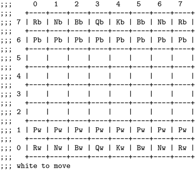

### 4.5.5 国际象棋走法4.5.5 Chess moves

现在有了摆满棋子的棋盘，我们还需要一种移动这些棋子的方法。如果在某个回合，一个棋子位于某个特定格子，那么表示该格子的节点就有一条以该回合为标签的边，它的值就是这个棋子。第 218 页的 make-chess-board-internal 中，下列委托过程与此有关：Now that we have a chessboard, populated with pieces, we need a way to move those pieces around. If a piece is in a particular square at a particular turn, the node representing that square has an edge, with the turn as its label, whose value is the piece. The following delegate procedures in make-chess-board-internal on page 218 are relevant here:

```
(define (piece-at address)

  (piece-in (node-at address)))



(define (piece-in node)

  (and (node ’has-edge? turn)

       (node ’edge-value turn)))



(define (set-piece-at address piece)

  ((node-at address) ’connect! (+ turn 1) piece))
```

给定我们打算移动的棋子的地址，就可以用 piece-at 获取这个棋子。当然，检查明显的错误总是个好主意。We use piece-at to obtain a piece that we expect to move, given its address. Of course, it is always a good idea to check for obvious errors.

```
(define (get-piece-to-move board from)

  (let ((my-piece (board ’piece-at from)))

    (if (not my-piece)

        (error "No piece in this square:" from))

    (if (not (eq? (board ’color) (piece-color my-piece)))

        (error "Can move only one's own pieces:"

               my-piece from))

    my-piece))
```

真正走棋时，我们把棋子拿起来，再放到目标格中。不过，只有目标格为空，或者被一个可以吃掉的对方棋子占据时，才允许这样走。To actually make a move we pick the piece up and set it down in the target square. However, this move is allowed only if the target square is empty or if it is occupied by an opponent piece to be captured.

```
(define (simple-move board from to)

  (let ((my-piece (get-piece-to-move board from)))

    (let ((captured (board ’piece-at to)))

      (if (not (no-piece-or-opponent? captured my-piece))

          (error "Can't capture piece of same color:"

                 captured)))

    ;; The move looks good; make it so:

    (board 'set-piece-at to my-piece)

    ;; Now update all the unaffected pieces to

    ;; the next state of the board:

    (for-each (lambda (address)

                (if (not (or (address= from address)

                             (address= to address)))

                    (let ((p (board ’piece-at address)))

                      (if p

                          (board ’set-piece-at address p)))))

              board-addresses)

    (board ’next-turn)))
```

请注意，我们没有加入检查，来判断想要移动的棋子是否能按那样走。关于各类棋子合法走法的全部描述，只存在于我们在Notice that we didn't put in a check that the piece we want to move is able to make that move. Our only descriptions of the legal moves available to each kind of piece are in the graph patterns that we built in 第 4.5.3 节section 4.5.3中构建的图模式里。在第 225 页的练习 4.24 中，我们将修正这个问题。. In exercise 4.24 on page 225 we will fix this problem.

但首先，让我们用匹配器判断由这样一个路径模式描述的走法是否是在吃子：But first, let's use the matcher to determine whether a move described by such a path pattern is a capture:

```
(define (capture? board from path)

  (let* ((my-piece (get-piece-to-move board from))

         (dict

          (graph-match path

                       (match:extend-dict chess-board:var ;**

                                          board

                                          (match:new-dict))

                       (board ’node-at from))))

    (and dict

         (let* ((target (match:get-value 'target-node dict))

                (captured (board ’piece-in target)))

           (and captured

                ‘(capture ,my-piece

                          ,captured

                          ,(board ’address-of target)))))))
```

标有 ;** 的那一行在初始字典中加入一个特殊绑定，供某些需要查询棋盘的模式限制条件使用。The line marked by ;** adds a special binding in the initial dictionary, which is used by some pattern restrictions that need to interrogate the board.

为方便起见，chess-move 按一步走法更新棋盘，然后从下一位走棋者的视角打印棋盘。For convenience, chess-move updates the board with a move, then prints the board for the player who will move next.

```
(define (chess-move from to)

  (set! the-board (simple-move the-board from to))

  (print-chess-board the-board))
```

为了演示这段代码，我们可以摆出一个有趣的局面：To demonstrate this code we can make an interesting position:

```
(define (giuoco-piano-opening)

  (start-chess-game)

  (chess-move ’(4 1) ’(4 3))            ;W: P-K4

  (chess-move ’(3 1) ’(3 3))            ;B: P-K4

  (chess-move ’(6 0) ’(5 2))            ;W: N-KB3

  (chess-move ’(6 0) ’(5 2))            ;B: N-QB3

  (chess-move ’(5 0) ’(2 3))            ;W: B-QB4

  (chess-move ’(2 0) ’(5 3)))           ;B: B-QB4



(giuoco-piano-opening)
```

经过大量打印输出后，我们得到如下棋盘局面：After lots of printout, we obtain the following board position:

white to move：白方行棋。

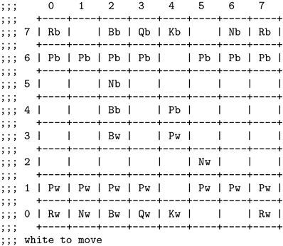

此时，位于王翼象线第 3 格的白马正在攻击王线第 5 格的黑兵。吃掉这个兵并不是好主意，因为它受到位于后翼象线第 6 格的黑马保护，而我们不应该用马去换兵。不过，我们可以使用马的走法中的一个图模式，检查这确实是一种可能的吃子走法：At this point the White Knight at King Bishop 3 is attacking the Black Pawn at King 5. It is not a good idea to take that piece because it is defended by the Black Knight at Queen-Bishop 6, and one should not exchange a knight for a pawn. However, we can use a graph pattern from the knight moves to check that this is a possible capture:

```
(capture? the-board

          (make-address 5 2)

          ‘((? source-node ,(occupied-by ’knight))

            north (?) north (?)

            west (? target-node ,maybe-opponent)))

(capture (knight white) (pawn black) (4 4))
```

事实上，这是这只马唯一可能的吃子走法：Indeed, it is the only possible capture for this knight:

```
(filter-map (lambda (path)

              (capture? the-board

                        (make-address 5 2)

                        path))

            all-knight-moves)

((capture (knight white) (pawn black) (4 4)))
```

## 练习 4.24：合法的国际象棋走法Exercise 4.24: Legal chess moves

在第 216 页的练习 4.23 中，我们为所有合法的国际象棋走法构建了一个模式库。修改 simple-move 程序（第 222 页），检查被移动的棋子是否可以按所要求的方式走。In exercise 4.23 on page 216 we made a library of patterns for all legal chess moves. Modify the simple-move program (page 222) to check that the piece being moved is allowed to move in the way requested.

### 4.5.6 实现图匹配4.5.6 Implementing graph matching

使用图模式的入口是：The entry point for using a graph pattern is:

```
(define (graph-match path dict object)

  ((gmatch:compile-path path) object dict

   (lambda (object* dict*)

     dict*)))
```

我们把路径模式编译成一个匹配过程，它接收作为起点的图对象（一个节点）、初始字典和成功续延。如果模式成功匹配了从该节点开始的一串边，它就调用成功续延，并传入匹配路径末端的节点（object*）以及匹配过程中积累的绑定字典，如前所述We compile the path pattern into a match procedure that takes the graph object (a node) to start from, an initial dictionary, and a success continuation. If the pattern successfully matches a sequence of edges starting with that node, it calls the success continuation, which takes the node (object*) at the end of the matched path and a dictionary of bindings accumulated in the match, as described in 第4.3节section 4.3。<sup>18</sup> 如果模式无法匹配给定对象，匹配过程就返回 #f。.<sup>18</sup> If the pattern fails to match the given object the match procedure returns #f.

我们用来与图匹配的模式，是一种小型语言的表达式；我们希望将它们编译成匹配过程。图模式表达式的语法可以用 BNF 描述。这里，后缀 * 表示出现零次或多次，后缀 + 表示出现一次或多次，后缀 ? 表示出现零次或一次。中缀 | 表示备选项。用 " 括起来的项是字面字符串。例如，匹配单个元素的模式变量以 (? 开始，可以有名称和谓词，也可以没有，最后以 ) 结束。The patterns that we are using for matching against graphs are *expressions* of a small language that we want to compile into match procedures. The syntax of graph-pattern expressions can be described in BNF. Here a postfix * indicates 0 or more occurrences, postfix + indicates 1 or more, and postfix ? indicates 0 or 1 occurrence. An infix | indicates alternatives. Items surrounded in " are literal strings. For example, a pattern variable to match a single element starts with (?, has an optional name and optional predicate, and ends with ).

```
<edge> = <edge-label> <target>

<edge-label> = <symbol>

<target> = <node-var> | <object-var> | <constant>

<node-var> = <single-var>

<object-var> = <single-var> | <sequence-var>

<single-var> = "(?" <var-name>? <unary-predicate>? ")"

<sequence-var> = "(?*" <var-name>? <unary-predicate>? ")"

<var-name> = <symbol>



<path> = <node-var> <path-elements>

<path-elements> = <path-element>*



<path-element> =

    <edge>

  | "(*" <path-elements> ")" ; repeat any number of times

  | "(+" <path-elements> ")"  ; repeat at least once

  | "(opt" <path-elements> ")"  ; one or zero instances

  | "(or" <ppath-elements>+ ")"

  | "(and" <ppath-elements>+ ")"

<ppath-elements> = "(" <path-elements> ")"
```

在我们的图匹配语言中，图中的每条路径都从一个节点变量开始。节点变量是单元素变量，满足谓词 match:element-var?。我们如下编译路径：In our graph-matching language every path in a graph starts with a node variable. A node variable is a single-element variable, which satisfies the predicate match:element-var?. We compile a path as follows:

```
(define (gmatch:compile-path path)

  (if (and (pair? path) (match:element-var? (car path)))

      (gmatch:finish-compile-path (cdr path)

        (gmatch:compile-var (car path)))

      (error "Ill-formed path:" path)))
```

这里我们检查 path 的第一个元素是不是元素变量；如果是，就把它编译成变量匹配器。路径的其余部分（如果有）由 finish-compile-path 编译：<sup>19</sup>Here we check that the first element of path is an element variable; if so, we compile it into a variable matcher. The remainder of the path, if any, is compiled by finish-compile-path:<sup>19</sup>

```
(define (gmatch:finish-compile-path rest-elts matcher)

  (if (null? rest-elts)

      matcher

      (gmatch:seq2 matcher

                   (gmatch:compile-path-elts rest-elts))))
```

其中，seq2 产生一个匹配过程，依次使用作为参数传入的各个匹配过程进行匹配：where seq2 produces a match procedure that sequentially matches its match-procedure arguments:

```
(define (gmatch:seq2 match-first match-rest)

  (define (match-seq object dict succeed)

    (match-first object dict

                 (lambda (object* dict*)

                   (match-rest object* dict* succeed))))

  match-seq)
```

由 compile-var 产生的变量匹配器 match-first 将匹配路径的初始节点；然后，compile-path-elts 的结果（match-rest）使用所得字典 dict*，从边 object* 开始匹配路径的其余部分。The variable matcher match-first, produced by compile-var, will match the initial node of the path, and the resulting dictionary dict* is then used by the result of compile-path-elts (match-rest) to match the remainder of the path, starting with the edge object*.

编译路径元素模式时，只有几种情况：路径或者以边标签和目标节点开始，或者以特殊匹配形式（*、+、opt、or、and）开始：There are only a few cases for compiling path-element patterns. Either the path starts with an edge label and a target node, or it starts with a special match form (*, +, opt, or, and):

```
(define (gmatch:compile-path-elts elts)

  (let ((elt (car elts))

        (rest (cdr elts)))

    (cond ((and (symbol? elt) (pair? rest))

           (gmatch:finish-compile-path (cdr rest)

             (gmatch:compile-edge elt (car rest))))

          ((pair? elt)

           (gmatch:finish-compile-path rest

             (gmatch:compile-path-elt elt)))

          (else

           (error "Ill-formed path elements:" elts)))))
```

边的标签可以是任意符号，只要它不是图匹配器模式所用的特殊符号（*、+、opt、or、and）之一。于是，简单带标签边的匹配器可以这样编译：An edge may be labeled by any symbol that is not one of the special symbols (*, +, opt, or, and) used by graph-matcher patterns. The matcher for a simple labeled edge is then compiled by:

```
(define (gmatch:compile-edge label target)

  (let ((match-target (gmatch:compile-target target)))

    (define (match-edge object dict succeed)

      (and (graph-node? object)

           (object ’has-edge? label)

           (match-target (object ’edge-value label)

                         dict succeed)))

    match-edge))
```

边匹配器 match-edge 检查对象是否为图节点、是否有一条给定标签的边从该对象出发，以及这条边的目标（edge-value）能否（使用 match-target）匹配图匹配模式中的目标模式。match-edge 中使用的匹配过程 match-target 是由编译器 compile-target 创建的。The edge matcher, match-edge, checks that the object is a graph node, that there is an edge with the given label emanating from that object, and that the target of the edge (the edge-value) will match (using match-target) the pattern for the target in the graph-match pattern. The match procedure match-target used in match-edge is made by the compiler compile-target.

编译目标时只有两种可能：变量或常量。There are only two possibilities when compiling a target: a variable or a constant.

```
(define (gmatch:compile-target elt)

  (if (match:var? elt)

      (gmatch:compile-var elt)

      (let ()

        (define (match-constant object dict succeed)

          (and (eqv? elt object)

               (succeed object dict)))

        match-constant)))
```

特殊匹配形式由 compile-path-elt 处理：The special match forms are handled by compile-path-elt:

```
(define (gmatch:compile-path-elt elt)

  (let ((keyword (car elt))

        (args (cdr elt)))

    (case keyword

      ((*) (gmatch:compile-* args))

      ((+) (gmatch:compile-+ args))

      ((opt) (gmatch:compile-opt args))

      ((or) (gmatch:compile-or args))

      ((and) (gmatch:compile-and args))

      (else (error "Ill-formed path element:" elt)))))
```

编译带有可选路径元素的模式，工作方式如下：用那段可选路径元素序列的路径元素模式，递归调用 compile-path-elts，得到 matcher，即路径中可有可无的那些元素的匹配器。把 match-opt 应用于一个图节点对象时，就应用这些路径元素的匹配器；但如果它失败，返回 #f，则以原始对象和原始字典作为结果，使匹配成功。Compiling a pattern with optional path elements works as follows: There is a recursive call to compile-path-elts with the path element patterns for the optional sequence of path elements, to obtain matcher, the matcher for the elements that are optionally present in the path. When match-opt is applied to a graph node object, the matcher for those path elements is applied; but if it fails, returning #f, the match succeeds with the original object and the original dictionary.

```
(define (gmatch:compile-opt elts)

  (let ((matcher (gmatch:compile-path-elts elts)))

    (define (match-opt object dict succeed)

      (or (matcher object dict succeed)

          (succeed object dict)))

    match-opt))
```

含有重复路径元素的模式，例如第 215 页 basic-queen-moves 中的模式 (* north (?* ,unoccupied))，按下面的方式编译：A pattern with repeated path elements, for example the pattern (* north (?* ,unoccupied)) in basic-queen-moves on page 215, is compiled like this:

```
(define (gmatch:compile-* elts)

  (gmatch:* (gmatch:compile-path-elts elts)))
```

与要求可选路径元素序列的模式一样，编译器递归调用自身，得到可能重复出现的序列的匹配器，再将其传给 gmatch:*：As for a pattern requiring an optional sequence of path elements, the compiler is called recursively to obtain a matcher for the potentially repeated sequence, which is then passed to gmatch:*:

```
(define (gmatch:* matcher)

  (define (match-* object dict succeed)

    (or (matcher object dict

                 (lambda (object* dict*)

                   (match-* object* dict* succeed)))

        (succeed object dict)))

  match-*)
```

图模式匹配器 match-* 尝试把传给它的 matcher 应用于所提供的图节点对象。如果成功，match-* 就递归调用自身，尝试匹配从上次匹配结束处开始的那部分图。最终它会无法继续前进，此时便以 matcher 未能匹配的图对象作为结果，使匹配成功。The graph-pattern matcher match-* tries to use the matcher passed to it on the graph node object supplied. If it succeeds, match-* calls itself recursively to try the part of the graph where the last match left off. Eventually it will fail to progress, succeeding with the graph object that matcher failed on.

编译要求路径元素序列至少重复一次、也可能重复多次的模式（用 + 表示），与编译 * 类似。它像上面一样使用 gmatch:*，但要求先匹配至少一个元素：Compiling patterns requiring at least one, but possibly many, repetitions of a sequence of path elements, indicated with +, is similar to *. It uses gmatch:* as above, but requires at least one matching element first:

```
(define (gmatch:compile-+ elts)

  (let ((matcher (gmatch:compile-path-elts elts)))

    (gmatch:seq2 matcher (gmatch:* matcher))))
```

剩下的特殊路径模式是 and 和 or，每种都包含若干子路径模式。and 元素必须匹配从当前节点开始的所有子路径模式。or 元素则必须匹配从当前节点开始的至少一个子路径模式。The remaining special path patterns are and and or, each of which contains a number of subpath patterns. An and element must match all of the subpath patterns starting at the current node. An or element must match at least one of the subpath patterns starting at the current node.

```
(define (gmatch:compile-and elt-lists)

  (gmatch:and (map gmatch:compile-path-elts elt-lists)))



(define (gmatch:compile-or elt-lists)

  (gmatch:or (map gmatch:compile-path-elts elt-lists)))
```

真正的工作在过程 and 和 or 中进行：The procedures and and or are where the real work happens:

```
(define (gmatch:and matchers)

  (lambda (object dict succeed)

    (if (null? matchers)

        (succeed object dict)

        (let loop ((matchers matchers) (dict dict))

          ((car matchers) object dict

           (if (null? (cdr matchers))

               succeed

               (lambda (object* dict*)

                 (loop (cdr matchers) dict*))))))))



(define (gmatch:or matchers)

  (lambda (object dict succeed)

    (let loop ((matchers matchers))

      (if (pair? matchers)

          (or ((car matchers) object dict succeed)

              (loop (cdr matchers)))

          #f))))
```

过程 compile-var 编译模式变量。它由 compile-path 和 compile-target 调用，并用四种互斥的情况处理具有或不具有可选名称和谓词的变量：The procedure compile-var compiles a pattern variable. It is called from compile-path and compile-target, and has four mutually exclusive cases to handle variables with or without the optional name and predicate:

```
(define (gmatch:compile-var var)

  (cond ((match-list? var gmatch:var-type?)

         (gmatch:var-matcher (car var) #f #f))

        ((match-list? var gmatch:var-type? symbol?)

         (gmatch:var-matcher (car var) (cadr var) #f))

        ((match-list? var gmatch:var-type? symbol? procedure?)

         (gmatch:var-matcher (car var) (cadr var) (caddr var)))

        ((match-list? var gmatch:var-type? procedure?)

         (gmatch:var-matcher (car var) #f (cadr var)))

        (else

         (error "Ill-formed variable:" var))))
```

过程 var-type? 匹配模式变量的类型符号：? 或 ?*。为了识别这四种变量情况，compile-var 使用工具过程 match-list?；当其第一个参数是列表，且列表中的每个元素都满足对应的谓词参数时，它就为真。The procedure var-type? matches the type symbol of a pattern variable: ? or ?*. To recognize the four cases of variables, compile-var uses a utility procedure match-list?, which is true if its first argument is a list and each element of the list satisfies the corresponding predicate argument.

```
(define (match-list? datum . preds)

  (let loop ((preds preds) (datum datum))

    (if (pair? preds)

        (and (pair? datum)

             ((car preds) (car datum))

             (loop (cdr preds) (cdr datum)))

        (null? datum))))
```

既然已经解读了变量的语法，过程 var-matcher 就是变量的匹配器。The procedure var-matcher is the matcher for variables, now that we have decoded their syntax.

```
(define (gmatch:var-matcher var-type var-name restriction)

  (define (match-var object dict succeed)

    (and (or (not restriction)

             (restriction object dict))

         (if var-name

             (let ((dict*

                    (gmatch:bind var-type var-name object

                                 dict)))

               (and dict*

                    (succeed object dict*)))

             (succeed object dict))))

  match-var)
```

这里，bind 为 var-name 加入一个值为 object 的绑定，返回一个新字典。如果字典中已有这样的绑定，而其值不同于 object，那么 bind 就返回 #f，表示匹配失败。Here bind adds a binding for var-name with value object, returning a new dictionary. If the dictionary already has such a binding, and its value is different from object, bind returns #f to indicate a match failure.

至此，我们就完成了图匹配器。And with this we have finished the graph matcher.

## 练习 4.25：图匹配Exercise 4.25: Graph matching

这里描述的图匹配器非常有用，但有些问题并不适合用它处理。有什么有趣的问题需要扩展这个匹配器呢？找出这样一个问题，定义并实现所需的扩展，再用一些例子演示它的用法。The graph matcher described here is very useful, but there are problems for which it isn't well suited. What is an interesting problem that requires extension(s) to the matcher? Find such a problem, define and implement the extension(s), and demonstrate its use on some examples.